# Collect & Analyze Finance Data from LSEG with Python

### 2.13. Extracting M&A deal information

Refinitiv maintains a comprehensive **Mergers & Acquisitions (M&A)** deals database. We can search and filter deals using the `DEALS_MERGERS_AND_ACQUISITIONS` Search view.

Before building a query, it is useful to inspect the **metadata** of the view to see all available properties, their types, and whether they can be used as filters. The first cell below does this. The second cell then runs an actual deal search.

For detailed Python examples, see the LSEG search tutorials: [Search with the Data Library](https://developers.lseg.com/en/api-catalog/refinitiv-data-platform/refinitiv-data-library-for-python/tutorials/content-tutorials/search).

```python
import pandas as pd  # import statement: makes external code (a module/package) available in this cell
from refinitiv.data.content import search  # import statement: makes external code (a module/package) available in this cell
import refinitiv.data as rd  # import statement: makes external code (a module/package) available in this cell

rd.open_session()  # rd.open_session() starts an authenticated connection to Refinitiv/LSEG (needed before queries)

# Retrieve metadata for the Deals M&A view.
meta = search.metadata.Definition(  # variable assignment: store a value in 'meta' so we can reuse it later
    view=search.Views.DEALS_MERGERS_AND_ACQUISITIONS  # keyword argument: set the parameter 'view' for the function call
).get_data()

# Save full metadata and show searchable / exact columns.
meta.data.df.to_csv("deals_view_metadata.csv", index=True)  # to_csv() writes a DataFrame to a CSV file on disk
print(meta.data.df[["Type", "Searchable", "Exact"]].to_string())  # print() outputs text/values to the screen (useful for checking results)

rd.close_session()
```

```
                                              Type  Searchable  Exact
AcquirerAdvisorCode                         String        True  False
AcquirerAdvisorCountry                      String        True  False
AcquirerAdvisorCusip                        String        True  False
AcquirerAdvisorName                         String        True   True
AcquirerAdvisorOAPermId                     String        True  False
AcquirerAdvisorRegion                       String        True  False
AcquirerAdvisorRegionCode                   String        True  False
AcquirerAdvisorRole                         String        True  False
AcquirerAdvisorSubRegion                    String        True  False
AcquirerAdvisorSubRegionCode                String        True  False
AcquirerAdvisorSubRole                      String        True  False
AcquirerBusinessDescriptionLong             String        True  False
AcquirerBusinessDescriptionShort            String        True  False
AcquirerCidgen                              String        True  False
AcquirerCompanyAliasName                    String        True  False
AcquirerCompanyAlternativeName              String        True  False
AcquirerCompanyName                         String        True  False
AcquirerCountry                             String        True  False
AcquirerCusip                               String        True  False
AcquirerEANCommonName                       String        True  False
AcquirerImmediateParentCidgen               String        True  False
AcquirerImmediateParentName                 String        True  False
AcquirerImmediateParentOAPermID             String        True  False
AcquirerMidIndustry                         String        True   True
AcquirerMidIndustryCode                     String        True  False
AcquirerNAICS                               String        True  False
AcquirerNAICSCode                           String        True  False
AcquirerName                                String        True  False
AcquirerOAPermId                            String        True  False
AcquirerPublicStatus                        String        True   True
AcquirerPublicStatusCode                    String        True  False
AcquirerRegion                              String        True   True
AcquirerRegionCode                          String        True  False
AcquirerRIC                                 String        True  False
AcquirerSDC                                 String        True  False
AcquirerSDCCode                             String        True  False
AcquirerShortName                           String        True  False
AcquirerStockPriceOnAnnouncementDay         String        True  False
AcquirerStockPriceOneDayAfterAnnouncement   String        True  False
```

[output cut: 164 more lines]

```
TargetSubRegion                             String        True   True
TargetSubRegionCode                         String        True  False
TargetTRBC                                  String        True  False
TargetTRBCCode                              String        True  False
TargetUltimateParentCidgen                  String        True  False
TargetUltimateParentName                    String        True  False
TargetUltimateParentOAPermID                String        True  False
TargetUSStateCode                           String        True   True
TransactionAnnouncementDate                   Date        True  False
TransactionComparableDealNumber             String        True  False
TransactionEffectiveDate                      Date        True  False
TransactionStatus                           String        True   True
TransactionStatusCode                       String        True  False
TransactionSynopsis                         String        True  False
TransactionValueIncludingNetDebtOfTarget    Double        True  False
```

How do I know possible values for one variable (or more) from one view to then put in place a screen/filter? I can use a **navigator**. Navigators provide the ability to summarize the distribution of your results. They are particularly useful when you are interested in gathering the domain of values for a specific property. or simply to understand how to build your filters based on specific values contained within Properties. Navigators can be used against a specific View, used in conjunction with either a query, a filter, or both. Navigators can be simple or very powerful, but provide a very useful way to capture results in logical buckets.

```python
import pandas as pd  # import statement: makes external code (a module/package) available in this cell
from refinitiv.data.content import search  # import statement: makes external code (a module/package) available in this cell
import refinitiv.data as rd  # import statement: makes external code (a module/package) available in this cell

rd.open_session()  # rd.open_session() starts an authenticated connection to Refinitiv/LSEG (needed before queries)
#one example
response = search.Definition(  # variable assignment: store a value in 'response' so we can reuse it later
    top=0,  # keyword argument: set the parameter 'top' for the function call
    navigators="TransactionStatus"  # keyword argument: set the parameter 'navigators' for the function call
).get_data()
rd.close_session()

response.data.raw['Navigators']['TransactionStatus']
```

```
{'Buckets': [{'Label': 'Completed', 'Count': 1241799},
  {'Label': 'Pending', 'Count': 183176},
  {'Label': 'Seeking Buyer', 'Count': 42016},
  {'Label': 'Withdrawn', 'Count': 41975},
  {'Label': 'Intended', 'Count': 36099},
  {'Label': 'Status Unknown', 'Count': 35761},
  {'Label': 'Dismissed Rumor', 'Count': 16810},
  {'Label': 'Seeking Buyer Withdrawn', 'Count': 2610},
  {'Label': 'Intent Withdrawn', 'Count': 1034},
  {'Label': 'Rumor', 'Count': 765},
  {'Label': 'Unconditional', 'Count': 472},
  {'Label': 'Seeking Target', 'Count': 259},
  {'Label': 'Pending Regulatory', 'Count': 22},
  {'Label': 'Partially Completed', 'Count': 14}]}
```

```python
import pandas as pd  # import statement: makes external code (a module/package) available in this cell
from refinitiv.data.content import search  # import statement: makes external code (a module/package) available in this cell
import refinitiv.data as rd  # import statement: makes external code (a module/package) available in this cell

rd.open_session()  # rd.open_session() starts an authenticated connection to Refinitiv/LSEG (needed before queries)

#another one
response = search.Definition(  # variable assignment: store a value in 'response' so we can reuse it later
    top=0,  # keyword argument: set the parameter 'top' for the function call
    navigators="TargetCountry"  # keyword argument: set the parameter 'navigators' for the function call
).get_data()

rd.close_session()

response.data.raw['Navigators']['TargetCountry']
```

```
{'Buckets': [{'Label': 'US', 'Count': 453113},
  {'Label': 'UK', 'Count': 123552},
  {'Label': 'CH', 'Count': 113220},
  {'Label': 'JP', 'Count': 80253},
  {'Label': 'CA', 'Count': 79075},
  {'Label': 'WG', 'Count': 62120},
  {'Label': 'FR', 'Count': 60861},
  {'Label': 'AU', 'Count': 56106},
  {'Label': 'IN', 'Count': 39567},
  {'Label': 'RU', 'Count': 38583},
  {'Label': 'SK', 'Count': 34712},
  {'Label': 'SP', 'Count': 33449},
  {'Label': 'IT', 'Count': 32690},
  {'Label': 'SW', 'Count': 25212},
  {'Label': 'NT', 'Count': 23010},
  {'Label': 'MA', 'Count': 22697},
  {'Label': 'HK', 'Count': 22036},
  {'Label': 'BR', 'Count': 19973},
  {'Label': 'SG', 'Count': 16540},
  {'Label': 'SZ', 'Count': 14651},
  {'Label': 'PL', 'Count': 13627},
  {'Label': 'NO', 'Count': 13095},
  {'Label': 'FN', 'Count': 12092},
  {'Label': 'DN', 'Count': 10921},
  {'Label': 'SA', 'Count': 10508},
  {'Label': 'BL', 'Count': 10143},
  {'Label': 'NZ', 'Count': 8693},
  {'Label': 'TH', 'Count': 8430},
  {'Label': 'ID', 'Count': 8004},
  {'Label': 'IR', 'Count': 7421},
  {'Label': 'VT', 'Count': 7122},
  {'Label': 'TW', 'Count': 7096},
  {'Label': 'AS', 'Count': 6792},
  {'Label': 'MX', 'Count': 6598},
  {'Label': 'TK', 'Count': 6311},
  {'Label': 'IS', 'Count': 6096},
  {'Label': 'PO', 'Count': 5789},
  {'Label': 'CC', 'Count': 5417},
  {'Label': 'PH', 'Count': 4999},
  {'Label': 'AR', 'Count': 4934},
```

[output cut: 45 more lines]

```
  {'Label': 'BA', 'Count': 417},
  {'Label': 'MV', 'Count': 413},
  {'Label': 'GG', 'Count': 407},
  {'Label': 'GH', 'Count': 404},
  {'Label': 'MT', 'Count': 388},
  {'Label': 'PP', 'Count': 379},
  {'Label': 'TZ', 'Count': 358},
  {'Label': 'ZA', 'Count': 341},
  {'Label': 'QA', 'Count': 338},
  {'Label': 'GE', 'Count': 331},
  {'Label': 'NM', 'Count': 327},
  {'Label': 'BB', 'Count': 322},
  {'Label': 'CB', 'Count': 318},
  {'Label': 'AZ', 'Count': 311},
  {'Label': 'IV', 'Count': 303}]}
```

```python
import pandas as pd  # import statement: makes external code (a module/package) available in this cell
from refinitiv.data.content import search  # import statement: makes external code (a module/package) available in this cell
import refinitiv.data as rd  # import statement: makes external code (a module/package) available in this cell

rd.open_session()  # rd.open_session() starts an authenticated connection to Refinitiv/LSEG (needed before queries)
#another one
response = search.Definition(  # variable assignment: store a value in 'response' so we can reuse it later
    top=0,  # keyword argument: set the parameter 'top' for the function call
    navigators="TargetPublicStatus"  # keyword argument: set the parameter 'navigators' for the function call
).get_data()
rd.close_session()


response.data.raw['Navigators']['TargetPublicStatus']
```

```
{'Buckets': [{'Label': 'Private', 'Count': 769617},
  {'Label': 'Subsidiary', 'Count': 535202},
  {'Label': 'Public', 'Count': 260175},
  {'Label': 'Joint Venture', 'Count': 24856},
  {'Label': 'Government', 'Count': 12064},
  {'Label': 'Mutual', 'Count': 305},
  {'Label': 'Investor', 'Count': 16},
  {'Label': 'Unknown', 'Count': 14},
  {'Label': 'Warrant/Basket', 'Count': 2}]}
```

The cell below searches for completed M&A deals where the target is a French private company, the deal value (including net debt) is at least 50 million, the form of the transaction is a merger or acquisition, and the announcement date falls between 2020 and 2025. Results are sorted by announcement date (most recent first).

A complete guide on how to set up filters and use the VIEWS in Refinitiv with Python can be found [here](https://developers.lseg.com/en/article-catalog/article/building-search-into-your-application-workflow).

```python
# --- Imports needed for this cell (so it can run independently) ---
import refinitiv.data as rd  # Refinitiv/LSEG Data Library (requires credentials)
import os  # os provides operating-system utilities (paths, directories, environment variables)
import pandas as pd  # import statement: makes external code (a module/package) available in this cell

# --- Define any configuration variables used in this cell ---
BASE_FOLDER = os.getcwd()  # use the current working directory as a default base folder

rd.open_session()  # rd.open_session() starts an authenticated connection to Refinitiv/LSEG (needed before queries)

# Search for French private-target M&A deals, completed, value >= 50M, 2020–2025.
MnA = rd.discovery.search(  # variable assignment: store a value in 'MnA' so we can reuse it later
    view=rd.discovery.Views.DEALS_MERGERS_AND_ACQUISITIONS,  # keyword argument: set the parameter 'view' for the function call
    filter=(  # keyword argument: set the parameter 'filter' for the function call
        "(TargetCountry eq 'FR' "
        "and TransactionValueIncludingNetDebtOfTarget ge 50 "
        "and TargetPublicStatus eq 'Private' "
        "and TransactionStatus eq 'Completed' "
        "and (FormOfTransactionName xeq 'Merger' "
        "     or FormOfTransactionName xeq 'Acquisition') "
        "and TransactionAnnouncementDate le 2025-12-31 "
        "and TransactionAnnouncementDate ge 2020-01-01)"
    ),
    select=(  # keyword argument: set the parameter 'select' for the function call
        "TransactionAnnouncementDate, TargetCompanyName, TargetRIC, "
        "TargetCountry, TargetPublicStatus, AcquirerCompanyName, "
        "TransactionStatus, TransactionValueIncludingNetDebtOfTarget, "
        "FormOfTransactionName"
    ),
    order_by="TransactionAnnouncementDate desc",  # keyword argument: set the parameter 'order_by' for the function call
    top=1000  # keyword argument: set the parameter 'top' for the function call
)

# Save to CSV and display the first rows.
MnA.to_csv(BASE_FOLDER + "\\ma_deals_FR.csv", index=True)  # to_csv() writes a DataFrame to a CSV file on disk
MnA.head(10)
```

|  | TransactionAnnouncementDate | TargetCompanyName | TargetCountry | TargetPublicStatus | AcquirerCompanyName | TransactionStatus | TransactionValueIncludingNetDebtOfTarget | FormOfTransactionName |
| --- | --- | --- | --- | --- | --- | --- | --- | --- |
| 0 | 2025-10-22 | ImCheck Therapeutics SAS | FR | Private | Ipsen SA | Completed | 405.93 | Merger |
| 1 | 2025-02-20 | Asc3 Lmb Topco Sas | FR | Private | Loar Group Inc | Completed | 380.366 | Merger |
| 2 | 2025-02-13 | Stilla Technologies SAS | FR | Private | Bio-Rad Laboratories Inc | Completed | 274.998 | Merger |
| 3 | 2024-10-07 | Younited SA | FR | Private | RA Special Acquisition Corp | Completed | 219.52 | Merger |
| 4 | 2024-09-25 | Financiere Hmy Sas | FR | Private | Itab Shop Concept AB | Completed | 357.76 | Merger |
| 5 | 2024-06-24 | Preligens SAS | FR | Private | Safran SA | Completed | 236.564 | Merger |
| 6 | 2023-06-16 | Arverne Group SAS | FR | Private | Transition SA | Completed | 181.687 | Merger |
| 7 | 2023-05-05 | Wargraphs SAS | FR | Private | MOBA Network AB | Completed | 55.055 | Merger |
| 8 | 2022-11-29 | Cenexi SAS | FR | Private | Gland Pharma International Pte Ltd | Completed | 125.935 | Merger |
| 9 | 2022-07-28 | ATALIAN International SAS | FR | Private | Clayton Dubilier & Rice LLC | Completed | 768.211 | Merger |

### 2.14. Extracting private equity deal information

Refinitiv also maintains a **Private Equity and Venture Capital** deals database. Access is via the `INVESTORS` Search view and the M&A deals view. The exact field names and filter values are documented in the Private Equity data guide and can be explored via DIB.

**Navigators** are a useful feature of the LSEG Search API: they return the **distinct categorical values** for a given field (similar to a "group by" in SQL). This lets you discover, for example, all possible values of `InvestorType` or `InvestorAddressCountry` before writing a filter.

```python
import refinitiv.data as rd  # import statement: makes external code (a module/package) available in this cell
from refinitiv.data.content import search  # import statement: makes external code (a module/package) available in this cell
import pandas as pd  # import statement: makes external code (a module/package) available in this cell

rd.open_session()  # rd.open_session() starts an authenticated connection to Refinitiv/LSEG (needed before queries)

# Retrieve metadata for the INVESTORS view.
meta = search.metadata.Definition(  # variable assignment: store a value in 'meta' so we can reuse it later
    view=search.Views.INVESTORS  # keyword argument: set the parameter 'view' for the function call
).get_data()
meta.data.df.to_csv("investors_metadata.csv", index=True)  # to_csv() writes a DataFrame to a CSV file on disk
print(meta.data.df[["Type", "Searchable", "Exact"]].to_string())  # print() outputs text/values to the screen (useful for checking results)

rd.close_session()
```

```
                              Type  Searchable  Exact
BusinessEntity              String        True   True
DocumentTitle               String        True  False
DTCharacteristics           String       False  False
DTSimpleType                String        True   True
DTSubjectName               String        True  False
HKAlias                     String        True   True
HKVersion                   String        True  False
InvestorAddressCity         String        True   True
InvestorAddressCountry      String        True   True
InvestorContactName         String        True  False
InvestorContactPermID       String        True   True
InvestorEntityType          String        True   True
InvestorEquityAssets        Double        True  False
InvestorFundParentName      String        True   True
InvestorFundParentOAPermID  String        True   True
InvestorId                  String        True  False
InvestorInvestmentStyle     String        True   True
InvestorLatestFilingDate      Date        True  False
InvestorName                String        True   True
InvestorOrientation         String        True   True
InvestorSubType             String        True   True
InvestorTurnover            String        True   True
InvestorType                String        True   True
PermID                      String        True   True
PI                          String        True  False
RIC                         String        True   True
SearchAllCategoryv3         String        True   True
Source                      String        True  False
SubjectBoost                String        True  False
```

```python
import refinitiv.data as rd  # import statement: makes external code (a module/package) available in this cell
from refinitiv.data.content import search  # import statement: makes external code (a module/package) available in this cell

rd.open_session()  # rd.open_session() starts an authenticated connection to Refinitiv/LSEG (needed before queries)
# navigator to get all the possible values for InvestorSubType
response = search.Definition(  # variable assignment: store a value in 'response' so we can reuse it later
    top=0,  # keyword argument: set the parameter 'top' for the function call
    navigators="InvestorSubType"  # keyword argument: set the parameter 'navigators' for the function call
).get_data()
rd.close_session()

response.data.raw['Navigators']['InvestorSubType']
```

```
{'Buckets': [{'Label': 'Corporation', 'Count': 201227},
  {'Label': 'Investment Advisor', 'Count': 24128},
  {'Label': 'Hedge Fund', 'Count': 5468},
  {'Label': 'Private Equity', 'Count': 3742},
  {'Label': 'Investment Advisor/Hedge Fund', 'Count': 3577},
  {'Label': 'Venture Capital', 'Count': 2585},
  {'Label': 'Research Firm', 'Count': 1797},
  {'Label': 'Holding Company', 'Count': 1662},
  {'Label': 'Insurance Company', 'Count': 1119},
  {'Label': 'Bank and Trust', 'Count': 1089},
  {'Label': 'Independent Research Firm', 'Count': 912},
  {'Label': 'Pension Fund', 'Count': 748},
  {'Label': 'Family Office', 'Count': 588},
  {'Label': 'Government Agency', 'Count': 398},
  {'Label': 'Foundation', 'Count': 199},
  {'Label': 'Endowment Fund', 'Count': 85},
  {'Label': 'Sovereign Wealth Fund', 'Count': 79},
  {'Label': 'Finance Company', 'Count': 5},
  {'Label': 'Individual Investor', 'Count': 1}]}
```

```python
# --- Imports needed for this cell (so it can run independently) ---
import refinitiv.data as rd  # Refinitiv/LSEG Data Library (requires credentials)

# --- Connect to Refinitiv/LSEG (requires an account + app key setup) ---
rd.open_session()  # rd.open_session() starts an authenticated connection to Refinitiv/LSEG (needed before queries)

# navigator to get all the possible values for InvestorAddressCountry
response = search.Definition(  # variable assignment: store a value in 'response' so we can reuse it later
    top=0,  # keyword argument: set the parameter 'top' for the function call
    navigators="InvestorAddressCountry"  # keyword argument: set the parameter 'navigators' for the function call
).get_data()
rd.close_session()


response.data.raw['Navigators']['InvestorAddressCountry']
```

```
{'Buckets': [{'Label': 'United States', 'Count': 94596},
  {'Label': '100025', 'Count': 38755},
  {'Label': '100319', 'Count': 36618},
  {'Label': '105758', 'Count': 25430},
  {'Label': '100136', 'Count': 24708},
  {'Label': 'United Kingdom', 'Count': 23062},
  {'Label': '100317', 'Count': 16767},
  {'Label': '100148', 'Count': 10915},
  {'Label': 'Canada', 'Count': 8198},
  {'Label': 'France', 'Count': 6907},
  {'Label': 'Hong Kong', 'Count': 6134},
  {'Label': '100173', 'Count': 5985},
  {'Label': 'Australia', 'Count': 5806},
  {'Label': '100295', 'Count': 5682},
  {'Label': 'Switzerland', 'Count': 5471},
  {'Label': '100044', 'Count': 5240},
  {'Label': '100226', 'Count': 4637},
  {'Label': 'Germany', 'Count': 4552},
  {'Label': '100131', 'Count': 4472},
  {'Label': '100265', 'Count': 4451},
  {'Label': '100052', 'Count': 4437},
  {'Label': 'Japan', 'Count': 4424},
  {'Label': '100275', 'Count': 4292},
  {'Label': '100270', 'Count': 4022},
  {'Label': 'India', 'Count': 3697},
  {'Label': 'Brazil', 'Count': 3529},
  {'Label': 'South Africa', 'Count': 3497},
  {'Label': '100212', 'Count': 3382},
  {'Label': '100291', 'Count': 3322},
  {'Label': 'Singapore', 'Count': 3078},
  {'Label': 'Spain', 'Count': 2530},
  {'Label': '100114', 'Count': 2421},
  {'Label': '100292', 'Count': 2243},
  {'Label': '100138', 'Count': 2192},
  {'Label': 'Netherlands', 'Count': 2174},
  {'Label': 'South Korea', 'Count': 2114},
  {'Label': 'Sweden', 'Count': 2102},
  {'Label': 'Italy', 'Count': 1966},
  {'Label': '100105', 'Count': 1848},
  {'Label': '100042', 'Count': 1791},
```

[output cut: 45 more lines]

```
  {'Label': '100257', 'Count': 386},
  {'Label': '100233', 'Count': 372},
  {'Label': 'Egypt', 'Count': 369},
  {'Label': 'Nigeria', 'Count': 358},
  {'Label': '100075', 'Count': 355},
  {'Label': '100036', 'Count': 352},
  {'Label': 'Turkey', 'Count': 328},
  {'Label': '100028', 'Count': 323},
  {'Label': '100133', 'Count': 322},
  {'Label': 'Kuwait', 'Count': 322},
  {'Label': '100308', 'Count': 316},
  {'Label': '100046', 'Count': 304},
  {'Label': '100252', 'Count': 300},
  {'Label': '100281', 'Count': 295},
  {'Label': '100215', 'Count': 293}]}
```

The next cell searches for all French private equity investors, and the one after retrieves M&A deals for a specific PE firm.

```python
import refinitiv.data as rd  # import statement: makes external code (a module/package) available in this cell
import pandas as pd  # import statement: makes external code (a module/package) available in this cell

rd.open_session()  # rd.open_session() starts an authenticated connection to Refinitiv/LSEG (needed before queries)

french_pe_investors = rd.discovery.search(  # variable assignment: store a value in 'french_pe_investors' so we can reuse it later
    view=rd.discovery.Views.INVESTORS,  # keyword argument: set the parameter 'view' for the function call
    filter="InvestorSubType eq 'Private Equity' and InvestorAddressCountry eq 'France'",  # keyword argument: set the parameter 'filter' for the function call
    select="InvestorName, InvestorSubType",  # keyword argument: set the parameter 'select' for the function call
    top=200  # keyword argument: set the parameter 'top' for the function call
)

rd.close_session()

print(f"Found {len(french_pe_investors)} private equity investors in France:\n")  # print() outputs text/values to the screen (useful for checking results)
print(french_pe_investors.to_string(index=False))  # print() outputs text/values to the screen (useful for checking results)
```

```
Found 55 private equity investors in France:

                                               InvestorName InvestorSubType
                                               Salvepar_NLE  Private Equity
                               Développement et partenariat  Private Equity
                     Initiative & Finance Investissement SA  Private Equity
                            Amundi Private Equity Funds SAS  Private Equity
                                           NextStage AM SAS  Private Equity
                                           Naxicap Partners  Private Equity
                                 BNP Paribas Private Equity  Private Equity
                              NBGI Private Equity S.A.S_NLE  Private Equity
                                  LBO France Gestion S.A.S.  Private Equity
                                              CALAO Finance  Private Equity
                                             Isatis Capital  Private Equity
                                           EMZ Partners SAS  Private Equity
                                          Quadrille Capital  Private Equity
                                            Agro Invest SAS  Private Equity
                              Cathay Capital Private Equity  Private Equity
                                           Chequers Capital  Private Equity
                                           Nem Partners_NLE  Private Equity
                                                 Qualis SCA  Private Equity
                                           Ardian France SA  Private Equity
                                IDIA Capital Investissement  Private Equity
                                               PAI Partners  Private Equity
                                    123 Investment Managers  Private Equity
                                Turenne Capital Partenaires  Private Equity
                                    Butler Capital Partners  Private Equity
                                         M Capital Partners  Private Equity
                          Antin Infrastructure Partners SAS  Private Equity
                                     Andera Partners S.A.S.  Private Equity
                                                    Equitis  Private Equity
                                             Sodero Gestion  Private Equity
                                                     Wendel  Private Equity
                              Pechel Industries Partenaires  Private Equity
                                      Sigefi Private Equity  Private Equity
                                                    SOCADIF  Private Equity
                              Motion Equity Partners S.A.S.  Private Equity
                                                Alto Invest  Private Equity
                                        Aloe Private Equity  Private Equity
                                                   Extendam  Private Equity
                                       Blackrock France SAS  Private Equity
                                              ARTS ET BIENS  Private Equity
                                       Crédit Mutuel Equity  Private Equity
                                           Jolt Capital SAS  Private Equity
                                                 Eurazeo SE  Private Equity
                                         Argos Wityu S.A.S.  Private Equity
                                            Truffle Capital  Private Equity
Institut Régional de Développement Industriel Midi-Pyrénées  Private Equity
                                           Supernova Invest  Private Equity
                                            Finadvance S.A.  Private Equity
                                   Lauxera Capital Partners  Private Equity
                                         ACE Management_NLE  Private Equity
                                              Omnes Capital  Private Equity
                                       XAnge Private Equity  Private Equity
                                     Natixis Private Equity  Private Equity
                                         Apax Partners S.A.  Private Equity
                             Eiffel Investment Group S.A.S.  Private Equity
                                     Pléiade Investissement  Private Equity
```

The next cell retrieves M&A deals for one specific PE firm (BNP Paribas Private Equity).

```python
# --- Imports needed for this cell (so it can run independently) ---
import refinitiv.data as rd  # import statement: makes external code (a module/package) available in this cell
import pandas as pd  # import statement: makes external code (a module/package) available in this cell

rd.open_session()  # rd.open_session() starts an authenticated connection to Refinitiv/LSEG (needed before queries)

fund_name = "BNP Paribas Private Equity"  # variable assignment: store a value in 'fund_name' so we can reuse it later

deals = rd.discovery.search(  # variable assignment: store a value in 'deals' so we can reuse it later
    view=rd.discovery.Views.DEALS_MERGERS_AND_ACQUISITIONS,  # keyword argument: set the parameter 'view' for the function call
    filter=f"AcquirerCompanyName eq '{fund_name}'",  # keyword argument: set the parameter 'filter' for the function call
    select=(  # keyword argument: set the parameter 'select' for the function call
        "TransactionAnnouncementDate, AcquirerCompanyName, AcquirerCountry, "
        "TargetCompanyName, TargetCountry, TargetPublicStatus, "
        "TransactionStatus, TransactionValueIncludingNetDebtOfTarget, "
        "FormOfTransactionName, PercentageOfSharesAcquired, SdcDealNumber"
    ),
    order_by="TransactionAnnouncementDate desc",  # keyword argument: set the parameter 'order_by' for the function call
    top=500  # keyword argument: set the parameter 'top' for the function call
)

print(f"Found {len(deals)} deals for {fund_name}")  # print() outputs text/values to the screen (useful for checking results)
print(deals.to_string())  # print() outputs text/values to the screen (useful for checking results)
```

```
Found 6 deals for BNP Paribas Private Equity
  TransactionAnnouncementDate                           AcquirerCompanyName AcquirerCountry         TargetCompanyName TargetCountry TargetPublicStatus TransactionStatus  TransactionValueIncludingNetDebtOfTarget            FormOfTransactionName  PercentageOfSharesAcquired SdcDealNumber
0                  2022-02-10  BNP Paribas Fortis Private Equity Belgium NV              BL              Hannecard NV            BL            Private         Completed                                       0.0  Acquisition Of Partial Interest                           0    3890761040
1                  2021-07-23  BNP Paribas Fortis Private Equity Belgium NV              BL                Konings NV            BL            Private         Completed                                       0.0  Acquisition Of Partial Interest                           0    3782428040
2                  2018-01-01  BNP Paribas Fortis Private Equity Belgium NV              BL  Food Associates Group NV            BL            Private         Completed                                       0.0  Acquisition Of Partial Interest                          25    3327525040
3                  2010-06-21                BNP Paribas Private Equity SAS              FR      Acropolis Telecom SA            FR             Public         Completed                                     2.239  Acquisition Of Partial Interest                           0    2194202040
4                  2010-05-31                BNP Paribas Private Equity SAS              FR                Telogic AS            DN            Private         Completed                                     3.691  Acquisition Of Partial Interest                           0    2207613040
5                  2006-03-31                BNP Paribas Private Equity SAS              FR              AgendiZe SAS            FR            Private         Completed                                     1.817  Acquisition Of Partial Interest                           0    1828124040
```

### 2.15. Extracting director and CEO information

Refinitiv provides **officer and director** data for listed companies: names, titles, ages, gender, and biographies. The workflow is:

1. Search for the company's equity RIC using the `EQUITY_QUOTES` view.
2. Use `rd.get_data()` with officer fields (e.g. `TR.OfficerName`, `TR.OfficerTitle`, `TR.OfficerAge`, `TR.ODOfficerPersonGender`, `TR.ODOfficerBiography`).
3. Control how many officers are returned via ranking parameters (`Rnk` for officer fields, `ODRnk` for OD-prefixed fields).

The example below retrieves board and management information for Dassault.

```python
# --- Imports needed for this cell (so it can run independently) ---
import refinitiv.data as rd  # Refinitiv/LSEG Data Library (requires credentials)
import os  # os provides operating-system utilities (paths, directories, environment variables)

# --- Define any configuration variables used in this cell ---
BASE_FOLDER = os.getcwd()  # use the current working directory as a default base folder

rd.open_session()  # rd.open_session() starts an authenticated connection to Refinitiv/LSEG (needed before queries)

# ── STEP 1: Find Dassault equity RIC ─────────────────────────────────────────
equity_hits = rd.discovery.search(  # variable assignment: store a value in 'equity_hits' so we can reuse it later
    query="Dassault",  # keyword argument: set the parameter 'query' for the function call
    view=rd.discovery.Views.EQUITY_QUOTES,  # keyword argument: set the parameter 'view' for the function call
    top=20  # keyword argument: set the parameter 'top' for the function call
)

print("=== Candidate Dassault equities ===")  # print() outputs text/values to the screen (useful for checking results)
print(equity_hits[["RIC", "DocumentTitle"]].to_string(index=False))  # print() outputs text/values to the screen (useful for checking results)
equity_hits.to_csv(BASE_FOLDER + "\\dassault_equity_candidates.csv", index=False)  # to_csv() writes a DataFrame to a CSV file on disk

# Take the first candidate (replace with the specific RIC you want).
selected_ric = equity_hits.iloc[0]["RIC"]  # variable assignment: store a value in 'selected_ric' so we can reuse it later
print(f"\nSelected RIC: {selected_ric}")  # print() outputs text/values to the screen (useful for checking results)

# ── STEP 2: Retrieve officer / director details ──────────────────────────────
officers = rd.get_data(  # variable assignment: store a value in 'officers' so we can reuse it later
    universe=[selected_ric],  # keyword argument: set the parameter 'universe' for the function call
    fields=[  # keyword argument: set the parameter 'fields' for the function call
        "TR.OfficerName",
        "TR.OfficerTitle",
        "TR.OfficerAge",
        "TR.ODOfficerPersonGender",
        "TR.ODOfficerBiography"
    ],
    parameters={"Rnk": "R1:R20", "ODRnk": "R1:R20"},  # keyword argument: set the parameter 'parameters' for the function call
    use_field_names_in_headers=True  # keyword argument: set the parameter 'use_field_names_in_headers' for the function call
)

print("\n=== Officer / director panel ===")  # print() outputs text/values to the screen (useful for checking results)
print(officers)  # print() outputs text/values to the screen (useful for checking results)
officers.to_csv(BASE_FOLDER + "\\dassault_officers_raw.csv", index=True)  # to_csv() writes a DataFrame to a CSV file on disk

rd.close_session()
```

```
=== Candidate Dassault equities ===
        RIC                                                                                                                       DocumentTitle
    DAST.PA                                                                                Dassault Systemes SE, Ordinary Share, Euronext Paris
      AM.PA                                                                                Dassault Aviation SA, Ordinary Share, Euronext Paris
    FINA.PA                                                                             Immobiliere Dassault SA, Ordinary Share, Euronext Paris
   0#DAST3:                                Eurex Dassault Systemes [DSYH] Single Stock Equity Future Chain Contracts, Equity Future, EUR, Eurex
    0#TDYS:                                 Eurex Dassault Systemes Equity Total Return Future Chain Chain Contracts, Equity Future, EUR, Eurex
   0#DAST-:                                                                                                DAST Spread Fut., Spread, EUR, Eurex
   0#D2SYY:                                     Eurex Dassault Systemes Single Stock Dividend Future Chain Contracts, Equity Future, EUR, Eurex
    0#TAVM:                                 Eurex Dassault Aviation Equity Total Return Future Chain Chain Contracts, Equity Future, EUR, Eurex
    0#DSYP:                      Eurex Dassault Systemes Physical Monthly Single Stock Equity Future Chain Contracts, Equity Future, EUR, Eurex
    0#AVMD:                                       Eurex Dassault Aviation Single Stock Equity Future Chain Contracts, Equity Future, EUR, Eurex
0#DASTLFDC: Intercontinental Exchange Europe Dassault Systemes No Dividend Equity Future Chain Contracts, EUR, Intercontinental Exchange Europe
  0#DASTDF:                      Euronext Paris Dassault Systemes Single Stock Dividend Future Chain Chain Contracts, Equity Future, EUR, MONEP
  0#DASTpf:                                                                                              DASSAULT SA, Equity Future, EUR, MONEP
     TAVMc1                                        Eurex Dassault Aviation Equity Total Return Future Continuation 1, Equity Future, EUR, Eurex
    DAST3c1                                 Eurex Dassault Systemes [DSYH] Single Stock Equity Future Continuation 1, Equity Future, EUR, Eurex
     TAVMc2                                        Eurex Dassault Aviation Equity Total Return Future Continuation 2, Equity Future, EUR, Eurex
    DAST3c2                                 Eurex Dassault Systemes [DSYH] Single Stock Equity Future Continuation 2, Equity Future, EUR, Eurex
     TAVMc4                                        Eurex Dassault Aviation Equity Total Return Future Continuation 4, Equity Future, EUR, Eurex
     TDYSc1                                        Eurex Dassault Systemes Equity Total Return Future Continuation 1, Equity Future, EUR, Eurex
     DSYPc1                       Eurex Dassault Systemes Physical Monthly Single Stock Equity Future Continuation 1, Equity Future, EUR, Eurex

Selected RIC: DAST.PA

=== Officer / director panel ===
   Instrument                   TR.OFFICERNAME  \
0     DAST.PA                 Mr. Pascal Daloz
1     DAST.PA           Mr. Charles Edelstenne
2     DAST.PA              Mr. Rouven Bergmann
3     DAST.PA             Ms. Laurence Barthes
4     DAST.PA           Mrs. Florence Verzelen
5     DAST.PA          Mr. Florence Hu-Aubigny
6     DAST.PA              Mr. Patrick Johnson
7     DAST.PA                 Mr. Samson Khaou
8     DAST.PA              Mr. Philippe Laufer
9     DAST.PA                Ms. Elisa Prisner
10    DAST.PA                Mr. Olivier Ribet
11    DAST.PA                Mr. Erik Swedberg
12    DAST.PA         Ms. Victoire De Margerie
```

[output cut: 36 more lines]

```
5                      Male
6                      Male
7                      Male
8                      Male
9                    Female
10                     Male
11                     Male
12                   Female
13                     Male
14                   Female  Ms. Laurence Daures-lescourret serves as Lead ...
15                   Female  Ms. Anne-Laure Chevalier serves as Non-Executi...
16                   Female  Ms. Catherine Dassault serves as Non-Executive...
17                     Male  Mr. Olivier Costa De Beauregard serves as Non-...
18                   Female  Ms. Christine Defert serves as Non-Executive D...
19                   Female  Mrs. Odile Desforges has been appointed as Non...
```

### 2.16. Extracting news flow for a company

Refinitiv provides access to **news headlines and full stories** for listed companies. News data can be used to study information arrival, sentiment, or to link specific events to stock price reactions.

The workflow has two steps:

1. **`rd.news.get_headlines()`** — Retrieves a table of headlines for a given RIC and date range. The `query` parameter uses Refinitiv query syntax: `"R:NVDA.O"` targets the NVIDIA RIC, and `"Language:LEN"` restricts to English-language news.
2. **`rd.news.get_story()`** — Retrieves the full text of a specific news story, identified by its `storyId` from the headlines table.

For full documentation, call `help(rd.news.get_headlines)` and `help(rd.news.get_story)`, or see the [official LSEG reference](https://cdn.refinitiv.com/public/rd-lib-python-doc/1.0.0.0/book/en/sections/content-layer/news/news-headlines/about-news-headlines.html).

```python
# --- Imports needed for this cell (so it can run independently) ---
import refinitiv.data as rd  # Refinitiv/LSEG Data Library (requires credentials)

# Display documentation for the headline retrieval function.
help(rd.news.get_headlines)
```

```
Help on function get_headlines in module refinitiv.data._access_layer.news._news:

get_headlines(query: str, count: int = 10, start: 'OptDateTime' = None, end: 'OptDateTime' = None, order_by: Union[str, refinitiv.data.content.news.headlines._sort_order.SortOrder] = <SortOrder.new_to_old: 'newToOld'>) -> pandas.core.frame.DataFrame
    Retrieves news headlines.

    Parameters
    ----------
    query: str
        The user search query for news headlines.
    count: int, optional
        Count to limit number of headlines.
    start: str or timedelta, optional
        Beginning of date range.
        String format is: '%Y-%m-%dT%H:%M:%S'. e.g. '2016-01-20T15:04:05'.
    end: str or timedelta, optional
        End of date range.
        String format is: '%Y-%m-%dT%H:%M:%S'. e.g. '2016-01-20T15:04:05'.
    order_by: str or SortOrder
        Sort order for headline items.

    Returns
    -------
    pd.DataFrame
        Headlines dataframe

    Examples
    --------
    >>> from datetime import timedelta
    >>> import refinitiv.data as rd
    >>> response = rd.news.get_headlines(
    ...     "Refinitiv",
    ...     start="20.03.2021",
    ...     end=timedelta(days=-4),
    ...     count=3
    ... )
```

```python
# --- Imports needed for this cell (so it can run independently) ---
import refinitiv.data as rd  # Refinitiv/LSEG Data Library (requires credentials)

# --- Connect to Refinitiv/LSEG (requires an account + app key setup) ---
rd.open_session()  # rd.open_session() starts an authenticated connection to Refinitiv/LSEG (needed before queries)

ric = "NVDA.O"   # NVIDIA

# ── STEP 1: Get headlines ─────────────────────────────────────────────────────
# "R:{ric}" targets the specific instrument; "Language:LEN" = English only.
headlines = rd.news.get_headlines(  # variable assignment: store a value in 'headlines' so we can reuse it later
    query=f"R:{ric} AND Language:LEN",  # keyword argument: set the parameter 'query' for the function call
    start="2024-01-01",  # keyword argument: set the parameter 'start' for the function call
    end="2024-12-31",  # keyword argument: set the parameter 'end' for the function call
    count=100               # maximum headlines per call
)

headlines = headlines.reset_index()   # versionCreated becomes a regular column
print(f"=== {len(headlines)} headlines for {ric} ===")  # print() outputs text/values to the screen (useful for checking results)
print(headlines[["versionCreated", "headline", "storyId"]].to_string())  # print() outputs text/values to the screen (useful for checking results)
```

```
=== 100 headlines for NVDA.O ===
            versionCreated                                                                                                                                                                                                                                                                                  …
0  2024-12-30 23:38:26.000                                                                                                                                                                                                                                     @WSJ: A hedge-fund manager’s raw mea culpa de…
1  2024-12-30 23:13:19.698                                                                                                                                                                                                                                                                                  …
2  2024-12-30 23:08:00.550                                                                                                                                                                                                                                                                                  …
3  2024-12-30 23:07:24.067                                                                                                                                                                                                                                                                                  …
4  2024-12-30 22:44:29.000                                                                                                                                                                                                                                                                                  …
5  2024-12-30 22:40:33.000                                                                                        @StockMKTNewz: Retweeted @StockMKTNewz: Nvidia $NVDA in 2020 agreed to acquire Arm Holdings for $40B\n\nThe 🇺🇸 FTC ended up blocking the deal and $ARM went on to go public in September 2…
6  2024-12-30 22:12:31.234                                                                                                                                                                                                                                                                                  …
7  2024-12-30 22:07:43.000                                                                                                                                                                                                                                                                                  …
8  2024-12-30 22:02:13.000                                                                                                                                                                                               @StockMKTNewz: There are currently 9 🇺🇸 listed stocks worth more than $1 Trillion\n…
9  2024-12-30 21:47:57.152                                                                                                                                                                                                                                                                                  …
10 2024-12-30 21:35:13.000                                                                                                                                                                                                                                                                               @Sp…
11 2024-12-30 21:34:00.000                                                                                                                                                                                                                                                                                  …
12 2024-12-30 21:33:05.029                                                                                                                                                                                                                                                                                  …
```

[output cut: 87 more lines]

The next cell loops through each headline retrieved above, fetches the full story text using `rd.news.get_story()`, and saves everything to an Excel file. We add a 0.2-second pause between calls to avoid hitting the Refinitiv API rate limit. This cell depends on the `headlines` DataFrame created just above.

Before retrieving full story text, let us inspect the documentation of `rd.news.get_story()`.

```python
# --- Imports needed for this cell (so it can run independently) ---
import refinitiv.data as rd  # Refinitiv/LSEG Data Library (requires credentials)

# Display documentation for the headline retrieval function.
help(rd.news.get_story)
```

```
Help on function get_story in module refinitiv.data._access_layer.news._news:

get_story(story_id: str, format: Union[refinitiv.data._access_layer.news._news.Format, str] = <Format.HTML: 'Html'>) -> str
    Retrieves the news story items.

    Parameters
    ----------
    story_id : str
        News Story ID.
    format : str, Format, optional
        Response format.

    Returns
    -------
    str
        Story html or text response

    Examples
    --------
    >>> import refinitiv.data as rd
    >>> response = rd.news.get_story("urn:newsml:reuters.com:20220713:nL1N2YU10J", format=rd.news.Format.TEXT)
```

```python
# --- Imports needed for this cell (so it can run independently) ---
import pandas as pd  # pandas is the standard Python library for working with tabular data (DataFrames)
import refinitiv.data as rd  # Refinitiv/LSEG Data Library (requires credentials)
from datetime import datetime, date  # datetime provides date/time objects and parsing
import time

rd.open_session()  # open a session so we can request data from the platform

# ── STEP 2: Get full story text for each headline ────────────────────────────
# This cell depends on the 'headlines' DataFrame from the cell above.
# Take times to run, refer to xlsx file!

results = []  # variable assignment: store a value in 'results' so we can reuse it later

for _, row in headlines.iterrows():  # for-loop: repeat code for each element in an iterable
    # Retrieve the full text of each story by its storyId.
    story_text = rd.news.get_story(row["storyId"], format=rd.news.Format.TEXT)  # keyword argument: set the parameter 'story_text' for the function call
    results.append({
        "date":     row["versionCreated"],
        "headline": row["headline"],
        "storyId":  row["storyId"],
        "text":     story_text
    })
    time.sleep(0.2)   # pause 0.2 seconds between calls to avoid rate limiting

df_news = pd.DataFrame(results)  # variable assignment: store a value in 'df_news' so we can reuse it later
print(df_news[["date", "headline"]].to_string())  # print() outputs text/values to the screen (useful for checking results)

# Save to Excel.
df_news.to_excel('news_NVDA.xlsx', index=False)  # to_excel() writes a DataFrame to an Excel (.xlsx) file

rd.close_session()
```

```
                      date                                                                                                                                                                                                                                                                                  …
0  2024-12-30 23:38:26.000                                                                                                                                                                                                                                     @WSJ: A hedge-fund manager’s raw mea culpa de…
1  2024-12-30 23:13:19.698                                                                                                                                                                                                                                                                                  …
2  2024-12-30 23:08:00.550                                                                                                                                                                                                                                                                                  …
3  2024-12-30 23:07:24.067                                                                                                                                                                                                                                                                                  …
4  2024-12-30 22:44:29.000                                                                                                                                                                                                                                                                                  …
5  2024-12-30 22:40:33.000                                                                                        @StockMKTNewz: Retweeted @StockMKTNewz: Nvidia $NVDA in 2020 agreed to acquire Arm Holdings for $40B\n\nThe 🇺🇸 FTC ended up blocking the deal and $ARM went on to go public in September 2…
6  2024-12-30 22:12:31.234                                                                                                                                                                                                                                                                                  …
7  2024-12-30 22:07:43.000                                                                                                                                                                                                                                                                                  …
8  2024-12-30 22:02:13.000                                                                                                                                                                                               @StockMKTNewz: There are currently 9 🇺🇸 listed stocks worth more than $1 Trillion\n…
9  2024-12-30 21:47:57.152                                                                                                                                                                                                                                                                                  …
10 2024-12-30 21:35:13.000                                                                                                                                                                                                                                                                               @Sp…
11 2024-12-30 21:34:00.000                                                                                                                                                                                                                                                                                  …
12 2024-12-30 21:33:05.029                                                                                                                                                                                                                                                                                  …
13 2024-12-30 21:32:52.777                                                                                                                                                                                                                                                                                  …
```

[output cut: 86 more lines]

### 2.17. Extracting bond information and identifying green bonds

In this subsection we use the `GOV_CORP_INSTRUMENTS` Search view to build a small bond universe and then isolate **green bonds** — bonds whose proceeds are specifically earmarked for environmental or climate-related projects.

We search for bonds issued by **TotalEnergies**, inspect their characteristics (RIC, ISIN, maturity, coupon, currency, green-bond flag), and then retrieve a **Yield to Maturity (YTM)** time series for one green bond.

**Yield to Maturity (YTM)** is the annualised return you would earn if you bought the bond today and held it until maturity, collecting all coupons along the way. YTM moves inversely with price: when the bond's market price falls, YTM rises, and vice versa. Daily changes are mostly driven by macro interest rate moves (e.g. ECB rate expectations), shifts in the issuer's credit risk, and liquidity.

```python
# --- Imports needed for this cell (so it can run independently) ---
import refinitiv.data as rd  # import statement: makes external code (a module/package) available in this cell
from refinitiv.data.content import search  # import statement: makes external code (a module/package) available in this cell
import pandas as pd  # import statement: makes external code (a module/package) available in this cell

rd.open_session()  # rd.open_session() starts an authenticated connection to Refinitiv/LSEG (needed before queries)

# Retrieve metadata for the INVESTORS view.
meta = search.metadata.Definition(  # variable assignment: store a value in 'meta' so we can reuse it later
    view=search.Views.GOV_CORP_INSTRUMENTS  # keyword argument: set the parameter 'view' for the function call
).get_data()
meta.data.df.to_csv("bond_metadata.csv", index=True)  # to_csv() writes a DataFrame to a CSV file on disk
print(meta.data.df[["Type", "Searchable", "Exact"]].to_string())  # print() outputs text/values to the screen (useful for checking results)

rd.close_session()
```

[output not shown]

[output cut: 1139 more lines]

[output not shown]

```python
# --- Imports needed for this cell (so it can run independently) ---
import refinitiv.data as rd  # Refinitiv/LSEG Data Library (requires credentials)
import os  # os provides operating-system utilities (paths, directories, environment variables)
import pandas as pd  # import statement: makes external code (a module/package) available in this cell
from refinitiv.data.content import search  # import statement: makes external code (a module/package) available in this cell

# --- Define any configuration variables used in this cell ---
BASE_FOLDER = os.getcwd()  # use the current working directory as a default base folder

rd.open_session()  # rd.open_session() starts an authenticated connection to Refinitiv/LSEG (needed before queries)

# Search for TotalEnergies bonds in the GOV_CORP_INSTRUMENTS view.
response_total = search.Definition(  # variable assignment: store a value in 'response_total' so we can reuse it later
    view=search.Views.GOV_CORP_INSTRUMENTS,  # keyword argument: set the parameter 'view' for the function call
    query="TotalEnergies",  # keyword argument: set the parameter 'query' for the function call
    select="RIC, ISIN, MaturityDate, CouponRate, Currency, IsGreenBond",  # keyword argument: set the parameter 'select' for the function call
    top=100  # keyword argument: set the parameter 'top' for the function call
).get_data()

total_bonds = response_total.data.df  # variable assignment: store a value in 'total_bonds' so we can reuse it later

print("=== Bonds for TotalEnergies (up to 100) ===")  # print() outputs text/values to the screen (useful for checking results)
print(total_bonds.to_string())  # print() outputs text/values to the screen (useful for checking results)

# Save to CSV.
total_bonds.to_csv(  # to_csv() writes a DataFrame to a CSV file on disk
    BASE_FOLDER + "\\total_energies_bonds_gov_corp_instruments.csv", index=False
)
```

```
=== Bonds for TotalEnergies (up to 100) ===
                  RIC          ISIN MaturityDate  CouponRate Currency  IsGreenBond
0        FR293730873=  XS2937308737          NaT         4.5      EUR        False
1        FR229096087=  XS2290960876          NaT       2.125      EUR        False
2        FR222463297=  XS2224632971          NaT         2.0      EUR        False
3        FR243213061=  XS2432130610          NaT         2.0      EUR        False
4        FR330521490=  XS3305214903          NaT        3.79      EUR        False
5        FR293730849=  XS2937308497          NaT        4.12      EUR        False
6        FR229096052=  XS2290960520          NaT       1.625      EUR        False
7        FR243213118=  XS2432131188          NaT        3.25      EUR        False
8        FR150116686=  XS1501166869          NaT       3.369      EUR        False
9          89152FC29=  US89152FC297   2026-03-02         0.0      USD        False
10         89152FC37=  US89152FC370   2026-03-03         0.0      USD        False
11  FR0129594273=RRPS  FR0129594273   2026-03-03         0.0      EUR        False
12   FR330225700=RRPS  XS3302257004   2026-03-03         0.0      EUR        False
```

[output cut: 87 more lines]

The next cell retrieves a daily **Yield to Maturity** time series for one of the bond found in the table above.

```python
# --- Imports needed for this cell (so it can run independently) ---
import pandas as pd  # pandas is the standard Python library for working with tabular data (DataFrames)
import refinitiv.data as rd  # Refinitiv/LSEG Data Library (requires credentials)
from datetime import datetime, date  # datetime provides date/time objects and parsing
import os  # os provides operating-system utilities (paths, directories, environment variables)

# --- Define any configuration variables used in this cell ---
BASE_FOLDER = os.getcwd()  # use the current working directory as a default base folder

rd.open_session()  # rd.open_session() starts an authenticated connection to Refinitiv/LSEG (needed before queries)

# Retrieve daily Yield to Maturity for one green bond over 2023–2024.
# Replace 'first_green_ric' with the actual RIC from the bond table above.
bond_yield_ts = rd.get_data(  # variable assignment: store a value in 'bond_yield_ts' so we can reuse it later
    universe="FR200438124=",  # keyword argument: set the parameter 'universe' for the function call
    fields=["TR.YieldToMaturity", "TR.YieldToMaturity.date"],  # keyword argument: set the parameter 'fields' for the function call
    parameters={"SDate": "2023-01-01", "EDate": "2024-12-31", "Frq": "D"}  # keyword argument: set the parameter 'parameters' for the function call
)

print(bond_yield_ts.head())  # print() outputs text/values to the screen (useful for checking results)

# Rename columns, convert dates, and compute daily yield changes.
bond_yield_ts = bond_yield_ts.rename(  # variable assignment: store a value in 'bond_yield_ts' so we can reuse it later
    columns={"Yield to Maturity": "YIELD", "Date": "Date"}  # keyword argument: set the parameter 'columns' for the function call
)
bond_yield_ts["Date"] = pd.to_datetime(bond_yield_ts["Date"])  # pd.to_datetime() converts text/dates into pandas datetime objects
bond_yield_ts = bond_yield_ts.set_index("Date").sort_index()  # variable assignment: store a value in 'bond_yield_ts' so we can reuse it later
bond_yield_ts["YIELD_CHANGE"] = bond_yield_ts["YIELD"].diff()

print(bond_yield_ts.head())  # print() outputs text/values to the screen (useful for checking results)
bond_yield_ts.to_csv(  # to_csv() writes a DataFrame to a CSV file on disk
    BASE_FOLDER + "\\total_energies_first_green_bond_yield.csv"
)

rd.close_session()
```

```
     Instrument  Yield to Maturity       Date
0  FR200438124=               3.77 2023-01-02
1  FR200438124=               3.68 2023-01-03
2  FR200438124=               3.57 2023-01-04
3  FR200438124=                3.6 2023-01-05
4  FR200438124=               3.49 2023-01-06
              Instrument  YIELD  YIELD_CHANGE
Date
2023-01-02  FR200438124=   3.77          <NA>
2023-01-03  FR200438124=   3.68         -0.09
2023-01-04  FR200438124=   3.57         -0.11
2023-01-05  FR200438124=    3.6          0.03
2023-01-06  FR200438124=   3.49         -0.11
```

### 2.18. Merging collected data

You will typically download several datasets and need to merge them into one to perform some data analysis. Below we show how to merge dataset based either on time or RIC. The key function here is **merge()**.

```python
# --- Imports needed for this cell (so it can run independently) ---
import pandas as pd  # import statement: makes external code (a module/package) available in this cell
help(pd.merge)
```

```
Help on function merge in module pandas.core.reshape.merge:

merge(left: 'DataFrame | Series', right: 'DataFrame | Series', how: 'MergeHow' = 'inner', on: 'IndexLabel | AnyArrayLike | None' = None, left_on: 'IndexLabel | AnyArrayLike | None' = None, right_on: 'IndexLabel | AnyArrayLike | None' = None, left_index: 'bool' = False, right_index: 'bool' = False, s…
    Merge DataFrame or named Series objects with a database-style join.

    A named Series object is treated as a DataFrame with a single named column.

    The join is done on columns or indexes. If joining columns on
    columns, the DataFrame indexes *will be ignored*. Otherwise if joining indexes
    on indexes or indexes on a column or columns, the index will be passed on.
    When performing a cross merge, no column specifications to merge on are
    allowed.

    .. warning::

        If both key columns contain rows where the key is a null value, those
        rows will be matched against each other. This is different from usual SQL
        join behaviour and can lead to unexpected results.

    Parameters
    ----------
    left : DataFrame or named Series
    right : DataFrame or named Series
        Object to merge with.
    how : {'left', 'right', 'outer', 'inner', 'cross'}, default 'inner'
        Type of merge to be performed.

        * left: use only keys from left frame, similar to a SQL left outer join;
          preserve key order.
        * right: use only keys from right frame, similar to a SQL right outer join;
          preserve key order.
        * outer: use union of keys from both frames, similar to a SQL full outer
          join; sort keys lexicographically.
        * inner: use intersection of keys from both frames, similar to a SQL inner
          join; preserve the order of the left keys.
        * cross: creates the cartesian product from both frames, preserves the order
          of the left keys.
    on : label or list
        Column or index level names to join on. These must be found in both
        DataFrames. If `on` is None and not merging on indexes then this defaults
```

[output cut: 146 more lines]

```
    >>> df1
        left
    0   foo
    1   bar
    >>> df2
        right
    0   7
    1   8

    >>> df1.merge(df2, how='cross')
       left  right
    0   foo      7
    1   foo      8
    2   bar      7
    3   bar      8
```

```python
# --- Imports needed for this cell (so it can run independently) ---
import pandas as pd  # pandas is the standard Python library for working with tabular data (DataFrames)
import refinitiv.data as rd  # Refinitiv/LSEG Data Library (requires credentials)
import os  # os provides operating-system utilities (paths, directories, environment variables)

# --- Define any configuration variables used in this cell ---
BASE_FOLDER = os.getcwd()  # use the current working directory as a default base folder

rd.open_session()  # rd.open_session() starts an authenticated connection to Refinitiv/LSEG (needed before queries)

# Get constituent
constituents = pd.read_csv(BASE_FOLDER + "\\cac40_constituents.csv")  # variable assignment: store a value in 'constituents' so we can reuse it later
rics = constituents["RIC"].tolist()  # variable assignment: store a value in 'rics' so we can reuse it later

# collect industry information
ind = rd.get_data(  # variable assignment: store a value in 'ind' so we can reuse it later
    universe=rics,  # keyword argument: set the parameter 'universe' for the function call
    fields=["TR.GICSSector"],  # keyword argument: set the parameter 'fields' for the function call
    use_field_names_in_headers=True,  # keyword argument: set the parameter 'use_field_names_in_headers' for the function call
)
print("="*40)  # print() outputs text/values to the screen (useful for checking results)
print(ind.head())  # print() outputs text/values to the screen (useful for checking results)

# collect country information
count = rd.get_data(  # variable assignment: store a value in 'count' so we can reuse it later
    universe=rics,  # keyword argument: set the parameter 'universe' for the function call
    fields=["TR.HeadquartersCountry"],  # keyword argument: set the parameter 'fields' for the function call
    use_field_names_in_headers=True,  # keyword argument: set the parameter 'use_field_names_in_headers' for the function call
)
print("="*40)  # print() outputs text/values to the screen (useful for checking results)
print(count.head())  # print() outputs text/values to the screen (useful for checking results)

# collect name information
names = rd.get_data(  # variable assignment: store a value in 'names' so we can reuse it later
    universe=rics,  # keyword argument: set the parameter 'universe' for the function call
    fields=["TR.CommonName"],  # keyword argument: set the parameter 'fields' for the function call
    use_field_names_in_headers=True,  # keyword argument: set the parameter 'use_field_names_in_headers' for the function call
)
print("="*40)  # print() outputs text/values to the screen (useful for checking results)
print(names.head())  # print() outputs text/values to the screen (useful for checking results)

#close session
rd.close_session()

# merge name, country, industry
ind_country=ind.merge(count, on="Instrument")  # variable assignment: store a value in 'ind_country' so we can reuse it later
ind_country_name=ind_country.merge(names, on="Instrument")  # variable assignment: store a value in 'ind_country_name' so we can reuse it later
print("="*40)  # print() outputs text/values to the screen (useful for checking results)
print(ind_country_name.head())  # print() outputs text/values to the screen (useful for checking results)

# save
ind_country_name.to_csv(BASE_FOLDER + "\\merged_dataset.csv", index=True)  # to_csv() writes a DataFrame to a CSV file on disk
```

```
========================================
  Instrument           TR.GICSSECTOR
0    SOGN.PA              Financials
1    DAST.PA  Information Technology
2    FOUG.PA             Industrials
3     VIE.PA               Utilities
4    ORAN.PA  Communication Services
========================================
  Instrument TR.HEADQUARTERSCOUNTRY
0    SOGN.PA                 France
1    DAST.PA                 France
2    FOUG.PA                 France
3     VIE.PA                 France
4    ORAN.PA                 France
========================================
```

[output cut: 20 more lines]

**Application.** As a final application for this section, try to collect data relevant for your own master thesis!

## 3. Data Visualisation in Python

In this section we learn how to turn financial data into clear, publication-quality charts. We use two widely used Python plotting libraries:

- **matplotlib** — The foundational plotting library in Python. Almost every chart you see in a Python notebook is built on matplotlib. We import it as `plt`.
- **seaborn** — Built on top of matplotlib, seaborn provides higher-level functions that produce attractive statistical graphics with less code. We import it as `sns`.

We illustrate three types of visualisation using S&P 500 data:

1. **Bar chart** — cross-sectional comparison of categories (industry distribution).
2. **Line chart** — time-series evolution (index level over time).
3. **Boxplot and histogram** — distribution of a variable across firms (ROA).

Good practice: always set clear **titles**, **axis labels**, and readable variable names. Avoid visual clutter.

**Matplotlib documentation (plot types and examples):**

- [Plot types – Matplotlib](https://matplotlib.org/stable/plot_types/index.html)
- [Examples gallery – Matplotlib](https://matplotlib.org/stable/gallery/index.html)
- [`matplotlib.pyplot` API reference](https://matplotlib.org/stable/api/_as_gen/matplotlib.pyplot.html)

**Seaborn documentation (plot types and examples):**

- [Overview of seaborn plotting functions](https://seaborn.pydata.org/tutorial/function_overview.html)
- [Seaborn example gallery](https://seaborn.pydata.org/examples/index.html)
- [Seaborn API reference](https://seaborn.pydata.org/api.html)

```python
# --- Imports needed for this cell (so it can run independently) ---
import matplotlib.pyplot as plt  # matplotlib is a plotting library for charts and figures
#install package
!pip install matplotlib seaborn  # shell command: '!' runs an operating-system command from the notebook
```

[output not shown]

### 3.1. S&P 500 industry distribution (TRBC sectors)

We now retrieve the **S&P 500 constituents** and their **TRBC business sector** classification (TRBC = Thomson Reuters Business Classification), then plot a bar chart showing how many firms belong to each sector.

This is a **cross-sectional visualisation**: we look at one point in time and compare categories.

```python
# --- Imports needed for this cell (so it can run independently) ---
import refinitiv.data as rd  # Refinitiv/LSEG Data Library (requires credentials)
import os  # os provides operating-system utilities (paths, directories, environment variables)
import pandas as pd  # import statement: makes external code (a module/package) available in this cell

# --- Define any configuration variables used in this cell ---
BASE_FOLDER = os.getcwd()  # use the current working directory as a default base folder

rd.open_session()  # rd.open_session() starts an authenticated connection to Refinitiv/LSEG (needed before queries)

spx_chain = "0#.SPX"   # index chain RIC for the S&P 500

# Request one row per constituent with RIC, company name, and TRBC sector.
sp500_constituents = rd.get_data(  # variable assignment: store a value in 'sp500_constituents' so we can reuse it later
    universe=spx_chain,  # keyword argument: set the parameter 'universe' for the function call
    fields=["TR.RIC", "TR.CompanyName", "TR.TRBCBusinessSector"],  # keyword argument: set the parameter 'fields' for the function call
    use_field_names_in_headers=True,  # keyword argument: set the parameter 'use_field_names_in_headers' for the function call
)

rd.close_session()

print("First rows of S&P 500 constituents:")  # print() outputs text/values to the screen (useful for checking results)
print(sp500_constituents.head())  # print() outputs text/values to the screen (useful for checking results)

# Save to CSV for reuse in later sections.
sp500_constituents.to_csv(  # to_csv() writes a DataFrame to a CSV file on disk
    BASE_FOLDER + "\\sp500_constituents_trbc.csv", index=False
)
```

```
First rows of S&P 500 constituents:
  Instrument TR.RIC                        TR.COMPANYNAME  \
0      HUM.N  HUM.N                            Humana Inc
1      IBM.N  IBM.N  International Business Machines Corp
2      JCI.N  JCI.N    Johnson Controls International PLC
3      APD.N  APD.N        Air Products and Chemicals Inc
4        A.N    A.N              Agilent Technologies Inc

             TR.TRBCBUSINESSSECTOR
0  Healthcare Services & Equipment
1           Software & IT Services
2                 Industrial Goods
3                        Chemicals
4  Healthcare Services & Equipment
```

Now we count how many firms belong to each TRBC sector and plot a horizontal bar chart. The `value_counts()` method counts how many times each unique value appears in a column — here it counts firms per sector.

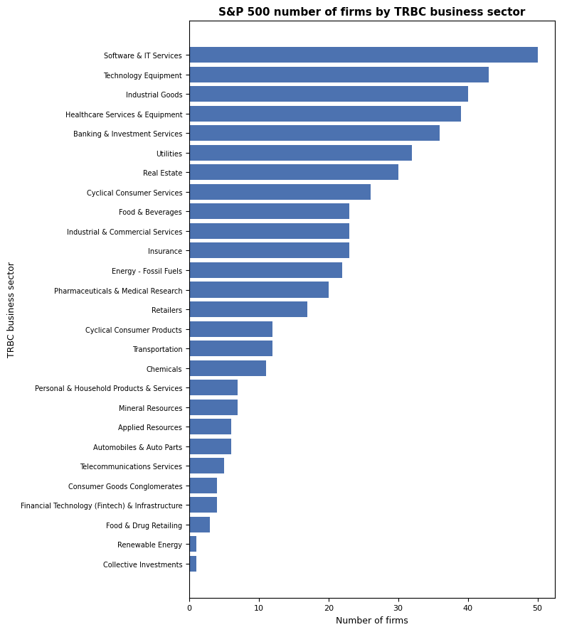

```python
# --- Imports needed for this cell (so it can run independently) ---
import pandas as pd  # pandas is the standard Python library for working with tabular data (DataFrames)

# Import matplotlib.pyplot and give it the short name 'plt'.
# This module provides plotting functions such as bar charts, line plots, and histograms.
import matplotlib.pyplot as plt  # import statement: makes external code (a module/package) available in this cell

# Read the CSV file containing S&P 500 constituents into a pandas DataFrame.
# pd.read_csv(...) loads the file into memory so that we can manipulate it in Python.
sp500_constituents = pd.read_csv("sp500_constituents_trbc.csv")  # variable assignment: store a value in 'sp500_constituents' so we can reuse it later

# Store the name of the column that contains the TRBC business sector for each firm.
# Using a variable for the column name avoids typos and makes it easy to change later.
industry_col = "TR.TRBCBUSINESSSECTOR"  # variable assignment: store a value in 'industry_col' so we can reuse it later

# Build a Series called 'counts' with the number of firms in each TRBC sector.
# Step by step:
# 1. sp500_constituents[industry_col] selects the single column with sector names.
# 2. .fillna("Unclassified") replaces missing values (NaN) with the text "Unclassified"
#    so that firms without a recorded sector are still counted instead of being ignored.
# 3. .value_counts() counts how many times each distinct sector name appears in the column.
# 4. .sort_values(ascending=True) sorts the counts from smallest to largest so that the
#    horizontal bar chart will have the smallest sectors at the bottom and the largest at the top.
counts = (  # variable assignment: store a value in 'counts' so we can reuse it later
    sp500_constituents[industry_col]
    .fillna("Unclassified")  # fillna() replaces missing values (NaN) with a specified value
    .value_counts()
    .sort_values(ascending=True)
)

# Create a new figure for the plot and set the overall size in inches (width, height).
plt.figure(figsize=(8, 9))

# Draw a horizontal bar chart.
# - counts.index contains the sector names (one bar per sector).
# - counts.values contains the number of firms in each sector (bar lengths).
# - color sets the bar color using a hex RGB code.
plt.barh(counts.index, counts.values, color="#4C72B0")

# Add a title at the top of the chart.
plt.title(
    "S&P 500 number of firms by TRBC business sector",
    fontweight="bold",  # keyword argument: set the parameter 'fontweight' for the function call
    fontsize=11,  # keyword argument: set the parameter 'fontsize' for the function call
)

# Label the x-axis so we know what the numbers represent.
plt.xlabel("Number of firms", fontsize=9)

# Label the y-axis so we know what each horizontal bar stands for.
plt.ylabel("TRBC business sector", fontsize=9)

# Make tick labels (numbers and sector names) slightly smaller so they fit nicely.
plt.xticks(fontsize=8)
plt.yticks(fontsize=7)

# Adjust the layout automatically so that labels and titles do not overlap or get cut off.
plt.tight_layout()

# Display the final plot in the notebook output.
plt.show()
```

**Application.** Now it is your turn to practice. For all the constituent of the STOXX 600, collect the country of heaqquarter, then show a a pie chart of the country repartition. A solution is provided below (click to unhide it). For more information on pie chart with plt, see [here](https://matplotlib.org/stable/gallery/pie_and_polar_charts/pie_featur).

```
TR.HEADQUARTERSCOUNTRY
United Kingdom    124
Germany            68
France             68
Switzerland        61
Sweden             55
Italy              37
Netherlands        35
Spain              27
Denmark            25
Name: count, dtype: Int64
```

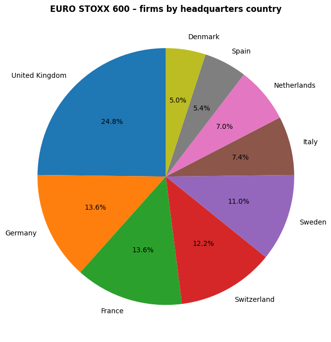

```python
# --- Imports needed for this cell (so it can run independently) ---
import pandas as pd  # pandas is the standard Python library for working with tabular data (DataFrames)
import matplotlib.pyplot as plt  # matplotlib is a plotting library for charts and figures
import refinitiv.data as rd  # Refinitiv/LSEG Data Library (requires credentials)
import os  # os provides operating-system utilities (paths, directories, environment variables)

# --- Define any configuration variables used in this cell ---
BASE_FOLDER = os.getcwd()  # use the current working directory as a default base folder

# ── 1. Load EURO STOXX 600 constituents from CSV (created earlier) ─────────────
stoxx_constituents = pd.read_csv(BASE_FOLDER + "\\stoxx_constituents.csv")  # variable assignment: store a value in 'stoxx_constituents' so we can reuse it later
rics = stoxx_constituents["RIC"].dropna().astype(str).tolist()  # variable assignment: store a value in 'rics' so we can reuse it later

# ── 2. Get headquarters country for each constituent ───────────────────────────
rd.open_session()  # rd.open_session() starts an authenticated connection to Refinitiv/LSEG (needed before queries)
countries = rd.get_data(  # variable assignment: store a value in 'countries' so we can reuse it later
    universe=rics,  # keyword argument: set the parameter 'universe' for the function call
    fields=["TR.HeadquartersCountry"],  # keyword argument: set the parameter 'fields' for the function call
    use_field_names_in_headers=True,  # keyword argument: set the parameter 'use_field_names_in_headers' for the function call
)
rd.close_session()

# First (and only) data column = country
country_series = countries["TR.HEADQUARTERSCOUNTRY"]  # variable assignment: store a value in 'country_series' so we can reuse it later

# ── 3. Count firms by country ──────────────────────────────────────────────────
country_counts = (  # variable assignment: store a value in 'country_counts' so we can reuse it later
    country_series
    .fillna("Unknown")  # fillna() replaces missing values (NaN) with a specified value
    .value_counts()
    .sort_values(ascending=False)
)

#keep only if at least 20
country_counts = country_counts[country_counts>=20]  # variable assignment: store a value in 'country_counts' so we can reuse it later
print(country_counts)  # print() outputs text/values to the screen (useful for checking results)

# ── 4. Pie chart of country distribution ───────────────────────────────────────
plt.figure(figsize=(7, 7))
plt.pie(
    country_counts.values,
    labels=country_counts.index,  # keyword argument: set the parameter 'labels' for the function call
    autopct="%1.1f%%",  # keyword argument: set the parameter 'autopct' for the function call
    startangle=90,  # keyword argument: set the parameter 'startangle' for the function call
)
plt.title("EURO STOXX 600 – firms by headquarters country", fontweight="bold")
plt.tight_layout()
plt.show()
```

### 3.2. Time-series plot — CAC 40 index level

A **time-series plot** shows how a variable evolves over time. We download daily closing prices for the CAC 40 (`.FCHI`) and plot the index level along with a **60-day moving average** — a smoothed line that shows the trend by averaging the last 60 trading days at each point.

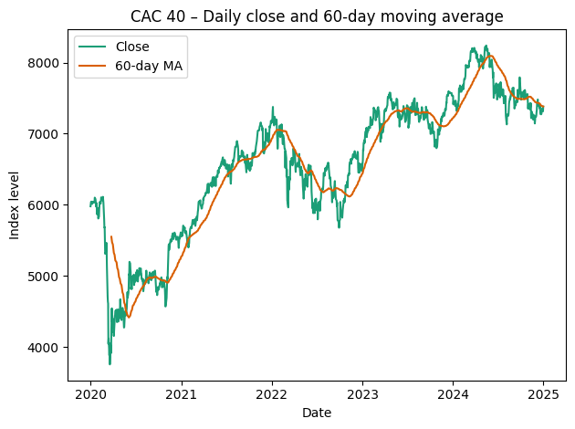

```python
# --- Imports needed for this cell (so it can run independently) ---
import pandas as pd  # pandas is the standard Python library for working with tabular data (DataFrames)
import matplotlib.pyplot as plt  # matplotlib is a plotting library for charts and figures
import refinitiv.data as rd  # Refinitiv/LSEG Data Library (requires credentials)
from datetime import datetime, date  # datetime provides date/time objects and parsing
import os  # os provides operating-system utilities (paths, directories, environment variables)

# --- Define any configuration variables used in this cell ---
BASE_FOLDER = os.getcwd()  # use the current working directory as a default base folder

#open session
rd.open_session()  # rd.open_session() starts an authenticated connection to Refinitiv/LSEG (needed before queries)
# get data
hist = rd.get_history(  # variable assignment: store a value in 'hist' so we can reuse it later
    universe=".FCHI",  # keyword argument: set the parameter 'universe' for the function call
    fields=["TR.PriceClose"],  # keyword argument: set the parameter 'fields' for the function call
    interval="1D",  # keyword argument: set the parameter 'interval' for the function call
    start="2020-01-01",  # keyword argument: set the parameter 'start' for the function call
    end="2024-12-31")  # keyword argument: set the parameter 'end' for the function call
#save
hist.to_csv(BASE_FOLDER+"\\cac40_prices.csv")  # to_csv() writes a DataFrame to a CSV file on disk
#close session
rd.close_session()

# Compute a 60-day rolling (moving) average of the closing price.
# .rolling(window=60) looks at the last 60 observations at each date.
# .mean() computes the average of those 60 observations.
# if neded you can load the data here
# hist=pd.read_csv(BASE_FOLDER+"\\cac40_prices.csv")
hist["MA60"] = hist["Price Close"].rolling(window=60).mean()

# Plot.
plt.figure()
plt.plot(hist.index, hist["Price Close"], label="Close", color="#1B9E77")
plt.plot(hist.index, hist["MA60"], label="60-day MA", color="#D95F02")
plt.title("CAC 40 – Daily close and 60-day moving average")
plt.xlabel("Date")
plt.ylabel("Index level")
plt.legend()
plt.tight_layout()
plt.show()
```

**Application.** Now it is your turn to practice. Collect and plot NVIDIA daily stock price over 2024. Show dots (in blue) and not a line. A (hidden) solution is provided below.

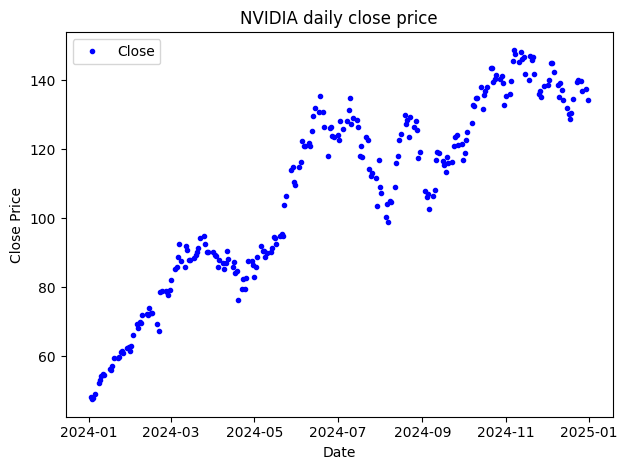

```python
# --- Imports needed for this cell (so it can run independently) ---
import matplotlib.pyplot as plt  # matplotlib is a plotting library for charts and figures
import refinitiv.data as rd  # Refinitiv/LSEG Data Library (requires credentials)
import os  # os provides operating-system utilities (paths, directories, environment variables)

# --- Define any configuration variables used in this cell ---
BASE_FOLDER = os.getcwd()  # use the current working directory as a default base folder

#open session
rd.open_session()  # rd.open_session() starts an authenticated connection to Refinitiv/LSEG (needed before queries)
# get data
hist = rd.get_history(  # variable assignment: store a value in 'hist' so we can reuse it later
    universe="NVDA.O",  # keyword argument: set the parameter 'universe' for the function call
    fields=["TR.PriceClose"],  # keyword argument: set the parameter 'fields' for the function call
    interval="1D",  # keyword argument: set the parameter 'interval' for the function call
    start="2024-01-01",  # keyword argument: set the parameter 'start' for the function call
    end="2024-12-31")  # keyword argument: set the parameter 'end' for the function call
#save
hist.to_csv(BASE_FOLDER+"\\nvda_prices.csv")  # to_csv() writes a DataFrame to a CSV file on disk
#close session
rd.close_session()

# Plot.
plt.figure()
plt.plot(  # plt.plot() draws a line plot with matplotlib
    hist.index,
    hist["Price Close"],
    marker="o",  # keyword argument: set the parameter 'marker' for the function call
    linestyle="none",  # keyword argument: set the parameter 'linestyle' for the function call
    color="blue",  # keyword argument: set the parameter 'color' for the function call
    markersize=3,  # keyword argument: set the parameter 'markersize' for the function call
    label="Close",  # keyword argument: set the parameter 'label' for the function call
)
plt.title("NVIDIA daily close price")
plt.xlabel("Date")
plt.ylabel("Close Price")
plt.legend()
plt.tight_layout()
plt.show()
```

### 3.3. Distribution of profitability (ROA) — boxplot and histogram

We now look at the **cross-sectional distribution of ROA** (Return on Assets) across S&P 500 firms using two standard plots.

**Boxplot — what it is and how to read it:**

- The horizontal line inside the box is the **median** (50th percentile) — the "typical" value.
- The bottom and top of the box are the **25th** and **75th** percentiles (Q1 and Q3). The height of the box is the **interquartile range (IQR)**.
- The **whiskers** extend from Q1 down and from Q3 up to the most extreme non-outlier values.
- Individual dots beyond the whiskers are **outliers** — firms with unusually low or high ROA.

Together, these two plots let us quickly see where most firms lie (central tendency), how dispersed profitability is, whether there are extreme winners or losers, and whether the distribution is symmetric or skewed.

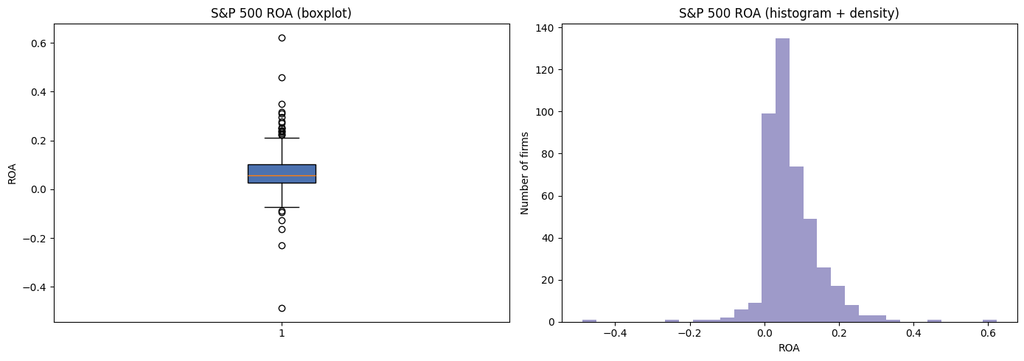

```python
# --- Imports needed for this cell (so it can run independently) ---
import pandas as pd  # pandas is the standard Python library for working with tabular data (DataFrames)
import matplotlib.pyplot as plt  # matplotlib is a plotting library for charts and figures
import refinitiv.data as rd  # Refinitiv/LSEG Data Library (requires credentials)

rd.open_session()  # rd.open_session() starts an authenticated connection to Refinitiv/LSEG (needed before queries)

# Reuse the S&P 500 RIC list
sp500_constituents = pd.read_csv("sp500_constituents_trbc.csv")  # variable assignment: store a value in 'sp500_constituents' so we can reuse it later
rics_sp500 = sp500_constituents["TR.RIC"].tolist()  # variable assignment: store a value in 'rics_sp500' so we can reuse it later

# Download net income and total assets to compute ROA.
fundamentals_roa = rd.get_data(  # variable assignment: store a value in 'fundamentals_roa' so we can reuse it later
    universe=rics_sp500,  # keyword argument: set the parameter 'universe' for the function call
    fields=["TR.NETINCOME", "TR.TOTALASSETS"],  # keyword argument: set the parameter 'fields' for the function call
    use_field_names_in_headers=True,  # keyword argument: set the parameter 'use_field_names_in_headers' for the function call
)

rd.close_session()

# Compute ROA = Net income / Total assets.
fundamentals_roa["ROA"] = fundamentals_roa["TR.NETINCOME"] / fundamentals_roa["TR.TOTALASSETS"]
roa = fundamentals_roa["ROA"].dropna()  # variable assignment: store a value in 'roa' so we can reuse it later

# Save ROA series
roa.to_csv("roa_series.csv")  # to_csv() writes a DataFrame to a CSV file on disk

# Create side-by-side plots.
fig, axes = plt.subplots(1, 2, figsize=(14, 5))

# Left panel: boxplot.
axes[0].boxplot(roa, vert=True, patch_artist=True,
                boxprops=dict(facecolor="#4C72B0"))
axes[0].set_title("S&P 500 ROA (boxplot)")
axes[0].set_ylabel("ROA")

# Right panel: histogram
axes[1].hist(roa, bins=30, color="#7570B3", alpha=0.7)
axes[1].set_title("S&P 500 ROA (histogram + density)")
axes[1].set_xlabel("ROA")
axes[1].set_ylabel("Number of firms")

plt.tight_layout()
plt.show()
```

**Interpretation of the ROA plots:**

The boxplot shows that the median ROA is positive but modest — a typical S&P 500 firm earns a small positive return on its assets. The height of the box (IQR) indicates meaningful dispersion: some firms are clearly more profitable than others. The whiskers and dots reveal outliers on both sides — a few firms with very negative ROA (loss-making) and a few with very high ROA.

**Application.** Now it is your turn to practice. Collect S&P and Bitcoin daily return since creation and create + comment there boxplot. A (hidden) solution is provided below.

```python
# --- Imports needed for this cell (so it can run independently) ---
import matplotlib.pyplot as plt  # matplotlib is a plotting library for charts and figures
import refinitiv.data as rd  # Refinitiv/LSEG Data Library (requires credentials)
import os  # os provides operating-system utilities (paths, directories, environment variables)

# --- Define any configuration variables used in this cell ---
BASE_FOLDER = os.getcwd()  # use the current working directory as a default base folder

rd.open_session()  # rd.open_session() starts an authenticated connection to Refinitiv/LSEG (needed before queries)

# Download daily BID and ASK for Bitcoin.
crypto_daily = rd.get_history(  # variable assignment: store a value in 'crypto_daily' so we can reuse it later
    universe="BTC=",  # keyword argument: set the parameter 'universe' for the function call
    fields=["BID", "ASK"],  # keyword argument: set the parameter 'fields' for the function call
    interval="daily",  # keyword argument: set the parameter 'interval' for the function call
    start="2014-01-01",  # keyword argument: set the parameter 'start' for the function call
    end="2024-12-31"  # keyword argument: set the parameter 'end' for the function call
)

# Download daily BID and ASK for SP.
sp_daily = rd.get_history(  # variable assignment: store a value in 'sp_daily' so we can reuse it later
    universe=".SPXTR",  # keyword argument: set the parameter 'universe' for the function call
    fields=["TR.PriceClose"],  # keyword argument: set the parameter 'fields' for the function call
    interval="daily",  # keyword argument: set the parameter 'interval' for the function call
    start="2014-01-01",  # keyword argument: set the parameter 'start' for the function call
    end="2024-12-31"  # keyword argument: set the parameter 'end' for the function call
)
rd.close_session()

# Compute the bid-ask spread.
crypto_daily["RET"] = crypto_daily["ASK"].pct_change()
print(crypto_daily.head())  # print() outputs text/values to the screen (useful for checking results)
sp_daily["RET"] = sp_daily["Price Close"].pct_change()
print(sp_daily.head())  # print() outputs text/values to the screen (useful for checking results)

# Save to CSV.
crypto_daily.to_csv(BASE_FOLDER + "\\crypto_daily_full.csv", index=True)  # to_csv() writes a DataFrame to a CSV file on disk
sp_daily.to_csv(BASE_FOLDER + "\\sp_daily_full.csv", index=True)  # to_csv() writes a DataFrame to a CSV file on disk
```

```
BTC=           BID     ASK       RET
Date
2014-07-17  623.01   626.3      <NA>
2014-07-18   629.7  631.84  0.008846
2014-07-19  627.53   630.0 -0.002912
2014-07-20  624.66  626.99 -0.004778
2014-07-21   620.0  622.23 -0.007592
.SPXTR      Price Close       RET
Date
2013-12-31    3315.5852      <NA>
2014-01-02    3286.6873 -0.008716
2014-01-03    3285.6831 -0.000306
2014-01-06    3277.4834 -0.002496
2014-01-07    3297.4492  0.006092
```

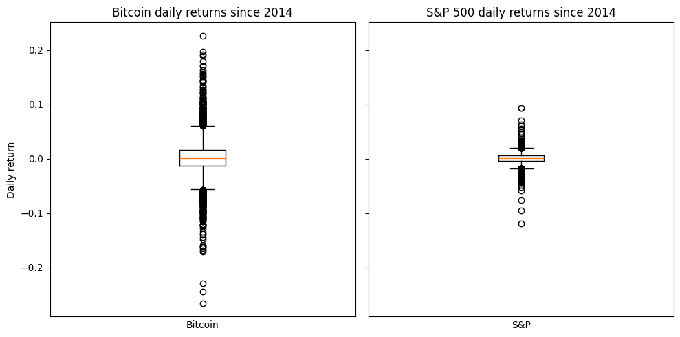

```python
# --- Imports needed for this cell (so it can run independently) ---
import pandas as pd  # pandas is the standard Python library for working with tabular data (DataFrames)
import matplotlib.pyplot as plt  # matplotlib is a plotting library for charts and figures
import os  # os provides operating-system utilities (paths, directories, environment variables)

# --- Define any configuration variables used in this cell ---
BASE_FOLDER = os.getcwd()  # use the current working directory as a default base folder
#get data
btc_hist = pd.read_csv(BASE_FOLDER + "\\crypto_daily_full.csv")  # variable assignment: store a value in 'btc_hist' so we can reuse it later
sp_hist  = pd.read_csv(BASE_FOLDER + "\\sp_daily_full.csv")  # variable assignment: store a value in 'sp_hist' so we can reuse it later

# prep figure
fig, axes = plt.subplots(1, 2, figsize=(10, 5), sharey=True)

# Left: Bitcoin
axes[0].boxplot(btc_hist["RET"].dropna(), vert=True)  # dropna() removes rows/columns with missing values
axes[0].set_title("Bitcoin daily returns since 2014")
axes[0].set_ylabel("Daily return")
axes[0].set_xticks([])              # remove the "1"
axes[0].set_xlabel("Bitcoin")

# Right: S&P 500
axes[1].boxplot(sp_hist["RET"].dropna(), vert=True)  # dropna() removes rows/columns with missing values
axes[1].set_title("S&P 500 daily returns since 2014")
axes[1].set_xticks([])              # remove the "1"
axes[1].set_xlabel("S&P")

plt.tight_layout()
plt.show()
```

## 4. Data Cleaning and Summary Statistics

### 4.1. Winsorising and trimming

**SciPy — a scientific computing library for Python.** `scipy` is a foundational scientific Python library that builds on NumPy. It provides tools for optimisation, integration, interpolation, signal processing, linear algebra, and statistics. The sub-module used throughout this notebook is **`scipy.stats`**, which contains:

- Statistical distributions (normal, t, F, chi-squared, …)
- Hypothesis tests (t-tests, Mann–Whitney, Kolmogorov–Smirnov, …)
- Descriptive statistics and data transformations (winsorize, trim, …)

We import it with: `from scipy import stats`

SciPy documentation: https://docs.scipy.org/doc/scipy/reference/stats.html

Financial data often have **heavy tails**: a few firms report extremely high or low values (for example very negative ROA or enormous leverage). These extreme observations — called **outliers** — can dominate sample means and distort regression estimates.

**Effect of outliers on a regression line:** Outliers can severely pull the regression line away from the true relationship between X and Y. Both trimming and winsorising help recover the true relationship.

Two standard tools for handling outliers:

- **Trimming** — Remove all observations below a chosen percentile (e.g. 1st) and above another (e.g. 99th). This discards the extremes entirely, which reduces sample size.
- **Winsorising** — Replace extreme values with the values at the chosen percentiles. For example, any value below the 1st percentile is set equal to the 1st percentile. This keeps the sample size intact but modifies the extreme values.

```python
# --- Imports needed for this cell (so it can run independently) ---
from scipy import stats  # SciPy stats includes statistical tests and distributions
# install package scipy if missing
!pip install scipy  # shell command: '!' runs an operating-system command from the notebook
```

[output not shown]

```python
# --- Imports needed for this cell (so it can run independently) ---
from scipy import stats  # SciPy stats includes statistical tests and distributions
# check winsorize function of scipy package
import scipy  # import statement: makes external code (a module/package) available in this cell
help(scipy.stats.mstats.winsorize)
```

```
Help on function winsorize in module scipy.stats._mstats_basic:

winsorize(a, limits=None, inclusive=(True, True), inplace=False, axis=None, nan_policy='propagate')
    Returns a Winsorized version of the input array.

    The (limits[0])th lowest values are set to the (limits[0])th percentile,
    and the (limits[1])th highest values are set to the (1 - limits[1])th
    percentile.
    Masked values are skipped.


    Parameters
    ----------
    a : sequence
        Input array.
    limits : {None, tuple of float}, optional
        Tuple of the percentages to cut on each side of the array, with respect
        to the number of unmasked data, as floats between 0. and 1.
        Noting n the number of unmasked data before trimming, the
        (n*limits[0])th smallest data and the (n*limits[1])th largest data are
        masked, and the total number of unmasked data after trimming
        is n*(1.-sum(limits)) The value of one limit can be set to None to
        indicate an open interval.
    inclusive : {(True, True) tuple}, optional
        Tuple indicating whether the number of data being masked on each side
        should be truncated (True) or rounded (False).
    inplace : {False, True}, optional
        Whether to winsorize in place (True) or to use a copy (False)
    axis : {None, int}, optional
        Axis along which to trim. If None, the whole array is trimmed, but its
        shape is maintained.
    nan_policy : {'propagate', 'raise', 'omit'}, optional
        Defines how to handle when input contains nan.
        The following options are available (default is 'propagate'):

          * 'propagate': allows nan values and may overwrite or propagate them
          * 'raise': throws an error
          * 'omit': performs the calculations ignoring nan values

    Notes
    -----
    This function is applied to reduce the effect of possibly spurious outliers
    by limiting the extreme values.

    Examples
    --------
    >>> import numpy as np
    >>> from scipy.stats.mstats import winsorize

    A shuffled array contains integers from 1 to 10.

    >>> a = np.array([10, 4, 9, 8, 5, 3, 7, 2, 1, 6])

    The 10% of the lowest value (i.e., `1`) and the 20% of the highest
    values (i.e., `9` and `10`) are replaced.

    >>> winsorize(a, limits=[0.1, 0.2])
    masked_array(data=[8, 4, 8, 8, 5, 3, 7, 2, 2, 6],
                 mask=False,
           fill_value=999999)
```

```python
# --- Imports needed for this cell (so it can run independently) ---
from scipy import stats  # SciPy stats includes statistical tests and distributions
import scipy  # import statement: makes external code (a module/package) available in this cell
help(scipy.stats.mstats.trim)
```

```
Help on function trim in module scipy.stats._mstats_basic:

trim(a, limits=None, inclusive=(True, True), relative=False, axis=None)
    Trims an array by masking the data outside some given limits.

    Returns a masked version of the input array.


    Parameters
    ----------
    a : sequence
        Input array
    limits : {None, tuple}, optional
        If `relative` is False, tuple (lower limit, upper limit) in absolute values.
        Values of the input array lower (greater) than the lower (upper) limit are
        masked.

        If `relative` is True, tuple (lower percentage, upper percentage) to cut
        on each side of the  array, with respect to the number of unmasked data.

        Noting n the number of unmasked data before trimming, the (n*limits[0])th
        smallest data and the (n*limits[1])th largest data are masked, and the
        total number of unmasked data after trimming is n*(1.-sum(limits))
        In each case, the value of one limit can be set to None to indicate an
        open interval.

        If limits is None, no trimming is performed
    inclusive : {(bool, bool) tuple}, optional
        If `relative` is False, tuple indicating whether values exactly equal
        to the absolute limits are allowed.
        If `relative` is True, tuple indicating whether the number of data
        being masked on each side should be rounded (True) or truncated
        (False).
    relative : bool, optional
        Whether to consider the limits as absolute values (False) or proportions
        to cut (True).
    axis : int, optional
        Axis along which to trim.


    Examples
    --------
    >>> from scipy.stats.mstats import trim
    >>> z = [ 1, 2, 3, 4, 5, 6, 7, 8, 9,10]
    >>> print(trim(z,(3,8)))
    [-- -- 3 4 5 6 7 8 -- --]
    >>> print(trim(z,(0.1,0.2),relative=True))
    [-- 2 3 4 5 6 7 8 -- --]
```

We now apply winsorising and trimming to the **S&P 500 ROA** data from Section 3.3.

```python
import numpy as np  # import statement: makes external code (a module/package) available in this cell
import pandas as pd  # import statement: makes external code (a module/package) available in this cell
from scipy.stats.mstats import winsorize, trim  # import statement: makes external code (a module/package) available in this cell

# Raw ROA from Section 3.4.
roa = pd.read_csv("roa_series.csv")  # variable assignment: store a value in 'roa' so we can reuse it later

# Make sure ROA is numeric; turn non-numeric entries into NaN and drop them
roa_raw = pd.to_numeric(roa["ROA"], errors="coerce").dropna()  # variable assignment: store a value in 'roa_raw' so we can reuse it later

print("Raw ROA summary:")  # print() outputs text/values to the screen (useful for checking results)
print(roa_raw.describe(percentiles=[0.01, 0.05, 0.95, 0.99]))  # print() outputs text/values to the screen (useful for checking results)

# 1%–99% winsorising and trimming using scipy
roa_wins = pd.Series(  # variable assignment: store a value in 'roa_wins' so we can reuse it later
    winsorize(roa_raw, limits=(0.01, 0.01)),
    index=roa_raw.index,  # keyword argument: set the parameter 'index' for the function call
    name="ROA_wins"  # keyword argument: set the parameter 'name' for the function call
)

roa_trim = pd.Series(  # variable assignment: store a value in 'roa_trim' so we can reuse it later
    trim(roa_raw, limits=(0.01, 0.01)),
    name="ROA_trim"  # keyword argument: set the parameter 'name' for the function call
)

print("\nWinsorised ROA summary (1–99% caps):")  # print() outputs text/values to the screen (useful for checking results)
print(roa_wins.describe(percentiles=[0.01, 0.05, 0.95, 0.99]))  # print() outputs text/values to the screen (useful for checking results)

print("\nTrimmed ROA summary (1–99% retained):")  # print() outputs text/values to the screen (useful for checking results)
print(roa_trim.describe(percentiles=[0.01, 0.05, 0.95, 0.99]))  # print() outputs text/values to the screen (useful for checking results)
```

```
Raw ROA summary:
count    438.000000
mean       0.070799
std        0.079106
min       -0.487860
1%        -0.091456
5%        -0.002446
50%        0.058451
95%        0.197428
99%        0.306154
max        0.622747
Name: ROA, dtype: float64

Winsorised ROA summary (1–99% caps):
count    438.000000
mean       0.071094
std        0.067438
min       -0.094096
1%        -0.091456
5%        -0.002446
50%        0.058451
95%        0.197428
99%        0.306154
max        0.311796
Name: ROA_wins, dtype: float64

Trimmed ROA summary (1–99% retained):
count    0.0
mean     NaN
std      NaN
min      NaN
1%       NaN
5%       NaN
50%      NaN
95%      NaN
99%      NaN
max      NaN
Name: ROA_trim, dtype: float64
```

### 4.2. Summary statistics table

This cell depends on `roa_raw`, `roa_wins`, and `roa_trim` from the cell above.

The method `DataFrame.describe()` (and `Series.describe()`) in pandas produces a quick statistical summary of your data.

For **numeric columns**, it typically shows:

- `count` – number of non-missing observations
- `mean` – average value
- `std` – standard deviation
- `min` – minimum value
- `25%`, `50%`, `75%` – quartiles (median is 50%)
- `max` – maximum value

For **categorical / object columns**, it shows:

- `count` – number of non-missing values
- `unique` – number of distinct categories
- `top` – most frequent category
- `freq` – frequency of that category

You can call it on a DataFrame or a single column:

`df.describe()` `df["ROA"].describe()`

```python
# --- Imports needed for this cell (so it can run independently) ---
import pandas as pd  # pandas is the standard Python library for working with tabular data (DataFrames)
# Raw ROA from earlier section
roa= pd.read_csv("roa_series.csv")  # variable assignment: store a value in 'roa' so we can reuse it later
roa_raw = roa.copy()  # variable assignment: store a value in 'roa_raw' so we can reuse it later

# Make sure ROA is numeric; turn non-numeric entries into NaN
roa_raw = pd.to_numeric(roa["ROA"], errors="coerce")  # variable assignment: store a value in 'roa_raw' so we can reuse it later

# Build summary statistics using pandas .describe(), then combine side by side.
summary = pd.concat([  # variable assignment: store a value in 'summary' so we can reuse it later
    roa_raw.describe(percentiles=[0.25, 0.5, 0.75]).rename("ROA Raw"),
], axis=1).T

# Display the table rounded to 4 decimal places.
print(summary.round(4))  # print() outputs text/values to the screen (useful for checking results)

# Save to CSV.
summary.round(4).to_csv("roa_summary_statistics.csv")  # to_csv() writes a DataFrame to a CSV file on disk
```

```
         count    mean     std     min     25%     50%     75%     max
ROA Raw  438.0  0.0708  0.0791 -0.4879  0.0281  0.0585  0.1032  0.6227
```

## 5. Hypothesis Testing with T-tests

Imagine you measure the ROA of 200 companies and get a mean of 5%. The question is: **is that 5% genuinely different from zero, or could it just be random noise?**

A **t-test** answers exactly that. It compares your sample mean against a reference value (usually 0) and tells you how surprising your result would be if there were actually nothing going on.

### 5.1. The null hypothesis

Before running any test, you define what "nothing going on" looks like. This is the **null hypothesis (H₀)** — your default assumption that you are trying to disprove.

For ROA:

- **H₀**: mean ROA = 0 — companies generate no return on assets (nothing going on).
- **H₁** (the alternative): mean ROA ≠ 0 — companies do generate a meaningful return (something going on).

The t-test then asks: *"if H₀ were true, how likely is it that I'd see a mean this far from zero just by chance?"* If that probability is very small (below 5%, which we write as p-value < 0.05), H₀ looks implausible and we **reject** it in favour of H₁. If not, we **fail to reject H₀** — we simply do not have enough evidence against it.

The **p-value** is the probability of observing a sample mean as extreme as ours (or more extreme) if H₀ were true. It answers the question: assuming the population mean really is zero, how likely is it that random sampling alone would produce the result we got? A small p-value (below 0.05) means our result would be very unlikely under H₀ — so we reject it. A large p-value means a result like ours could easily happen by chance — so we have no reason to reject H₀.

**Important:** failing to reject H₀ does **not** mean H₀ is true. It only means we cannot rule it out with the data at hand.

### 5.2. Applying the t-test to S&P 500 ROA

**Research question:** Is the average ROA of S&P 500 companies significantly different from zero?

- H₀: mean ROA = 0 (companies generate no return on assets).
- H₁: mean ROA ≠ 0.

```python
# --- Imports needed for this cell (so it can run independently) ---
import pandas as pd  # pandas is the standard Python library for working with tabular data (DataFrames)
import matplotlib.pyplot as plt  # matplotlib is a plotting library for charts and figures
from scipy import stats  # SciPy stats includes statistical tests and distributions
import refinitiv.data as rd  # Refinitiv/LSEG Data Library (requires credentials)
import os  # os provides operating-system utilities (paths, directories, environment variables)

# --- Define any configuration variables used in this cell ---
BASE_FOLDER = os.getcwd()  # use the current working directory as a default base folder

# --- Connect to Refinitiv/LSEG (requires an account + app key setup) ---
rd.open_session()  # open a session so we can request data from the platform

# ── 1. Reload S&P 500 constituents from the CSV saved in Section 3.2 ─────────
sp500_constituents = pd.read_csv(BASE_FOLDER + "\\sp500_constituents_trbc.csv")  # variable assignment: store a value in 'sp500_constituents' so we can reuse it later
rics_sp500 = sp500_constituents["TR.RIC"].dropna().astype(str).tolist()  # variable assignment: store a value in 'rics_sp500' so we can reuse it later

# ── 2. Download net income and total assets ───────────────────────────────────
rd.open_session()  # rd.open_session() starts an authenticated connection to Refinitiv/LSEG (needed before queries)
fundamentals_roa = rd.get_data(  # variable assignment: store a value in 'fundamentals_roa' so we can reuse it later
    universe=rics_sp500,  # keyword argument: set the parameter 'universe' for the function call
    fields=["TR.NETINCOME", "TR.TOTALASSETS"],  # keyword argument: set the parameter 'fields' for the function call
    use_field_names_in_headers=True,  # keyword argument: set the parameter 'use_field_names_in_headers' for the function call
)
rd.close_session()

# Compute ROA (raw only).
roa_raw = fundamentals_roa["TR.NETINCOME"] / fundamentals_roa["TR.TOTALASSETS"]  # variable assignment: store a value in 'roa_raw' so we can reuse it later
roa_clean = roa_raw.dropna()  # variable assignment: store a value in 'roa_clean' so we can reuse it later

# show summary stats
print("="*50)
print(roa_raw.describe())

# ── 3. One-sample t-test (H0: mean = 0) ───────────────────────────────────────
print("="*50)
t_stat, p_value = stats.ttest_1samp(roa_clean, popmean=0)
sig = "significant" if p_value < 0.05 else "not significant"  # variable assignment: store a value in 'sig' so we can reuse it later
print(f"Raw ROA {roa_clean.mean().round(2)} % |  p = {p_value:.4f}  | {sig}")  # print() outputs text/values to the screen (useful for checking results)
```

```
==================================================
count       438.0
mean     0.070799
std      0.079106
min      -0.48786
25%      0.028064
50%      0.058451
75%      0.103242
max      0.622747
dtype: Float64
==================================================
Raw ROA 0.07 % |  p = 0.0000  | significant
```

**Interpretation:** ROA has a **positive mean** (7%) with a p-value well below 0.05, so we reject H₀. The 7% mean is statistically different from a 0% mean. The average S&P 500 firm earns a statistically significant positive return on its assets.

### 5.3. One-sided vs two-sided tests

So far we tested whether mean ROA is **different** from zero (two-sided: H₁: mean ≠ 0). But sometimes we have a **directional** hypothesis — for example, "ROA is positive" rather than just "ROA is not zero".

| Hypothesis | H₀ | H₁ | When to use |
| --- | --- | --- | --- |
| Two-sided | mean = 0 | mean ≠ 0 | "Is ROA different from zero?" |
| One-sided right | mean ≤ 0 | mean > 0 | "Is ROA positive?" |
| One-sided left | mean ≥ 0 | mean < 0 | "Is ROA negative?" |

In a one-sided test, you put all 5% of your significance budget into **one tail** instead of splitting it 2.5% / 2.5%. This makes it easier to detect an effect in the expected direction but you completely ignore the other direction.

```python
# --- Imports needed for this cell (so it can run independently) ---
import pandas as pd  # pandas is the standard Python library for working with tabular data (DataFrames)
import matplotlib.pyplot as plt  # matplotlib is a plotting library for charts and figures
from scipy import stats  # SciPy stats includes statistical tests and distributions
import refinitiv.data as rd  # Refinitiv/LSEG Data Library (requires credentials)
import os  # os provides operating-system utilities (paths, directories, environment variables)

# --- Define any configuration variables used in this cell ---
BASE_FOLDER = os.getcwd()  # use the current working directory as a default base folder

# ── 1. Reload S&P 500 constituents from the CSV saved in Section 3.2 ─────────
sp500_constituents = pd.read_csv(BASE_FOLDER + "\\sp500_constituents_trbc.csv")  # variable assignment: store a value in 'sp500_constituents' so we can reuse it later
rics_sp500 = sp500_constituents["TR.RIC"].dropna().astype(str).tolist()  # variable assignment: store a value in 'rics_sp500' so we can reuse it later

# ── 2. Download net income and total assets ───────────────────────────────────
rd.open_session()  # rd.open_session() starts an authenticated connection to Refinitiv/LSEG (needed before queries)
fundamentals_roa = rd.get_data(  # variable assignment: store a value in 'fundamentals_roa' so we can reuse it later
    universe=rics_sp500,  # keyword argument: set the parameter 'universe' for the function call
    fields=["TR.NETINCOME", "TR.TOTALASSETS"],  # keyword argument: set the parameter 'fields' for the function call
    use_field_names_in_headers=True,  # keyword argument: set the parameter 'use_field_names_in_headers' for the function call
)
rd.close_session()

# Compute ROA (raw only).
roa_raw = fundamentals_roa["TR.NETINCOME"] / fundamentals_roa["TR.TOTALASSETS"]  # variable assignment: store a value in 'roa_raw' so we can reuse it later
roa_clean = roa_raw.dropna()  # variable assignment: store a value in 'roa_clean' so we can reuse it later

# ── 3. One-sample t-test (H₀: μ = 0  vs  H₁: μ > 0) ─────────────────────────
t_stat, p_two = stats.ttest_1samp(roa_clean, popmean=0)
p_value = p_two / 2 if t_stat > 0 else 1 - p_two / 2   # right-tailed p-value
sig = "significant" if p_value < 0.05 else "not significant"  # variable assignment: store a value in 'sig' so we can reuse it later
print(f"Raw ROA {roa_clean.mean().round(2)} % |  p (one-sided) = {p_value:.4f}  | {sig}")  # print() outputs text/values to the screen (useful for checking results)
```

```
Raw ROA 0.07 % |  p (one-sided) = 0.0000  | significant
```

**Interpretation:** Even more statistically significant. We reject the null (mean=0) in favor of the alternative (mean>0).

### 5.4. Two-sample t-test — comparing two groups

So far we tested one group against a fixed value. Now we compare **two independent groups** against each other:

- H₀: mean_A = mean_B (no difference between the groups).
- H₁: mean_A ≠ mean_B (the groups differ).

We use a **Welch t-test** (`stats.ttest_ind(..., equal_var=False)`) which does not assume the two groups have the same variance — a safer choice in practice.

We apply the two-sample t-test to real data. We split S&P 500 firms into **high-ESG** (score ≥ sample median) and **low-ESG** (score < median) groups and test whether the two groups differ in ROA, leverage, market-to-book, and firm size.

```python
# --- Imports needed for this cell (so it can run independently) ---
import pandas as pd  # pandas is the standard Python library for working with tabular data (DataFrames)
import numpy as np  # NumPy provides fast numerical arrays and math functions
import matplotlib.pyplot as plt  # matplotlib is a plotting library for charts and figures
from scipy import stats  # SciPy stats includes statistical tests and distributions
import refinitiv.data as rd  # Refinitiv/LSEG Data Library (requires credentials)

# ── 1. Download ESG + accounting variables for S&P 500 ───────────────────────
rd.open_session()  # rd.open_session() starts an authenticated connection to Refinitiv/LSEG (needed before queries)

rics_sp500 = sp500_constituents["TR.RIC"].dropna().tolist()  # variable assignment: store a value in 'rics_sp500' so we can reuse it later
print(f"Downloading ESG + fundamentals for {len(rics_sp500)} S&P 500 constituents…")  # print() outputs text/values to the screen (useful for checking results)

raw_esg = rd.get_data(  # variable assignment: store a value in 'raw_esg' so we can reuse it later
    universe=rics_sp500,  # keyword argument: set the parameter 'universe' for the function call
    fields=[  # keyword argument: set the parameter 'fields' for the function call
        "TR.NetIncome", "TR.TotalAssets", "TR.TotalDebt",
        "TR.CompanyMarketCap", "TR.F.ComEqTot", "TR.TRESGScore",
    ],
    use_field_names_in_headers=True,  # keyword argument: set the parameter 'use_field_names_in_headers' for the function call
)

rd.close_session()

# ── 2. Rename and construct variables ─────────────────────────────────────────
rename_map = {  # variable assignment: store a value in 'rename_map' so we can reuse it later
    "TR.NETINCOME": "net_income", "TR.TOTALASSETS": "total_assets",
    "TR.TOTALDEBT": "total_debt", "TR.COMPANYMARKETCAP": "market_cap",
    "TR.F.COMEQTOT": "equity_value", "TR.TRESGSCORE": "esg",
}
rename_map = {k: v for k, v in rename_map.items() if k in raw_esg.columns}  # variable assignment: store a value in 'rename_map' so we can reuse it later
panel = raw_esg.rename(columns=rename_map).copy().reset_index().rename(  # variable assignment: store a value in 'panel' so we can reuse it later
    columns={"index": "TR.RIC"}  # keyword argument: set the parameter 'columns' for the function call
)

panel["roa"]      = panel["net_income"] / panel["total_assets"]
panel["leverage"] = panel["total_debt"] / panel["total_assets"]
panel["size_ln"]  = np.log(panel["market_cap"])
panel["mtb"]      = panel["market_cap"] / panel["equity_value"]

# ── 3. Median ESG split ──────────────────────────────────────────────────────
panel = panel[panel["esg"].notna()].copy()  # variable assignment: store a value in 'panel' so we can reuse it later
esg_median = panel["esg"].median()  # variable assignment: store a value in 'esg_median' so we can reuse it later
high = panel[panel["esg"] >= esg_median]  # variable assignment: store a value in 'high' so we can reuse it later
low  = panel[panel["esg"] <  esg_median]  # variable assignment: store a value in 'low' so we can reuse it later

print(f"ESG median: {esg_median:.1f}")  # print() outputs text/values to the screen (useful for checking results)
print(f"High-ESG firms: {len(high)},  Low-ESG firms: {len(low)}")  # print() outputs text/values to the screen (useful for checking results)

# ── 4. Two-sample t-tests ────────────────────────────────────────────────────
variables = {  # variable assignment: store a value in 'variables' so we can reuse it later
    "ROA":             "roa",
    "Leverage":        "leverage",
    "Market-to-book":  "mtb",
    "Log(Market cap)": "size_ln",
}

rows = []  # variable assignment: store a value in 'rows' so we can reuse it later
for label, col in variables.items():  # for-loop: repeat code for each element in an iterable
    xh, xl = high[col].dropna(), low[col].dropna()  # dropna() removes rows/columns with missing values
    diff = xh.mean() - xl.mean()  # keyword argument: set the parameter 'diff' for the function call
    t_stat, p_val = stats.ttest_ind(xh, xl, equal_var=False)
    rows.append({
        "Variable": label,
        "Mean High ESG": f"{xh.mean():.4f}",
        "Mean Low ESG":  f"{xl.mean():.4f}",
        "Difference":    f"{diff:.4f}",
        "t-statistic":   f"{t_stat:.3f}",
        "p-value":       f"{p_val:.4f}",
        "N High": len(xh), "N Low": len(xl),
    })

ttest_table = pd.DataFrame(rows)  # variable assignment: store a value in 'ttest_table' so we can reuse it later
print("\nTwo-sample t-tests: mean(High ESG) - mean(Low ESG)")  # print() outputs text/values to the screen (useful for checking results)
print(ttest_table.to_string(index=False))  # print() outputs text/values to the screen (useful for checking results)
```

```
Downloading ESG + fundamentals for 503 S&P 500 constituents…
ESG median: 67.9
High-ESG firms: 251,  Low-ESG firms: 250

Two-sample t-tests: mean(High ESG) - mean(Low ESG)
       Variable Mean High ESG Mean Low ESG Difference t-statistic p-value  N High  N Low
            ROA        0.0649       0.0777    -0.0128      -1.693  0.0912     221    216
       Leverage        0.3184       0.2901     0.0283       1.386  0.1665     221    213
 Market-to-book        6.2366       4.7710     1.4656       0.187  0.8518     247    249
Log(Market cap)       24.8184      24.4496     0.3688       3.677  0.0003     251    250
```

**Interpretation:** The table compares **High-ESG** vs **Low-ESG** S&P 500 firms (about 250 in each group) on four variables.

**Takeaway:** Only **Log(Market cap)** shows a statistically significant difference. For ROA and Leverage, the point estimates differ between groups but the evidence is not strong enough at the 5% level. For Market-to-book, the raw difference looks big but is not statistically significant. Always consider both **statistical significance** (p-value) and **economic magnitude** (size of the difference).

### 5.5. Explaining performance during the COVID crisis

**Application.** Now it is your turn to practice. You are asked to examine whether standard characteristics of firms that performed well versus badly during the COVID crisis are statistically different, setting the ground for some hypothesis testing down the road. The universe of interest is the **CAC All** Tradable. Consider as many variables as you deem relevant ex ante to explain performance during this crisis (financial constraints, ESG score, industry). For industry, we can simply generate dummies coding for the belonging to one specific industry and see whether the fraction of the industry in each group statistically differs.

```python
# =============================================================================
# Solution — Section 5.5: Explaining performance during the COVID crisis
# =============================================================================
#   1. Retrieves CAC All Tradable constituents
#   2. Downloads daily prices to compute the COVID crisis return (Feb 20 – Mar 16, 2020)
#   3. Downloads pre-crisis firm characteristics guided by the Garel & Petit-Romec (2020) paper
#   4. Splits firms into "above median" vs "below median" COVID return groups
#   5. Runs two-sample t-tests on each characteristic
# =============================================================================

# --- Imports needed for this cell (so it can run independently) ---
import pandas as pd  # pandas is the standard Python library for working with tabular data (DataFrames)
import numpy as np  # NumPy provides fast numerical arrays and math functions
from scipy import stats  # SciPy stats includes statistical tests and distributions
import refinitiv.data as rd  # Refinitiv/LSEG Data Library (requires credentials)
import os  # os provides operating-system utilities (paths, directories, environment variables)

# --- Define any configuration variables used in this cell ---
BASE_FOLDER = os.getcwd()  # use the current working directory as a default base folder

# --- Connect to Refinitiv/LSEG (requires an account + app key setup) ---
rd.open_session()

# ── 1. Retrieve CAC All Tradable constituents ────────────────────────────────
# '0#.CACT' is the chain RIC that lists every member of the CAC All Tradable.
constituents = rd.get_data(  # variable assignment: store a value in 'constituents' so we can reuse it later
    universe=["0#.CACT"],  # keyword argument: set the parameter 'universe' for the function call
    fields=["TR.RIC", "TR.CommonName", "TR.GICSSector"]  # keyword argument: set the parameter 'fields' for the function call
)

print(f"Number of CAC All Tradable constituents: {len(constituents)}")  # print() outputs text/values to the screen (useful for checking results)
print(constituents.head())  # print() outputs text/values to the screen (useful for checking results)
constituents.to_csv("cacall_constituents.csv") #save
```

```
Number of CAC All Tradable constituents: 205
  Instrument      RIC                    Company Common Name  \
0    SGEF.PA  SGEF.PA                               Vinci SA
1    SOPR.PA  SOPR.PA                  Sopra Steria Group SA
2    ABNX.PA  ABNX.PA                      Abionyx Pharma SA
3    EEPC.PA  EEPC.PA  Soc D Explosifs Produits Chimiques SA
4    CAPP.PA  CAPP.PA                           Capgemini SE

         GICS Sector Name
0             Industrials
1  Information Technology
2             Health Care
3               Materials
4  Information Technology
```

```python
# Clean the RIC list: remove empty or missing RICs.
rics = constituents["RIC"].dropna().tolist()  # variable assignment: store a value in 'rics' so we can reuse it later
rics = [r for r in rics if r.strip() != ""]  # list comprehension: keep only non-empty RICs

# ── 2. Download daily prices to compute COVID crisis returns ─────────────────
# The COVID crisis period for France is February 20 to March 16, 2020
crisis_raw = rd.get_data(
    universe=rics,
    fields=["TR.TotalReturn"],
    parameters={"SDate": "2020-02-20", "EDate": "2020-03-16"},
    use_field_names_in_headers=True
)

print(crisis_raw)
crisis_raw.to_csv("cacall_covid_returns.csv") #save
```

[output not shown]

```
    Instrument  TR.TOTALRETURN
0      SGEF.PA      -43.878327
1      SOPR.PA        -34.0625
2      ABNX.PA      -53.807107
3      EEPC.PA       -8.450704
4      CAPP.PA      -44.719894
..         ...             ...
200    SOIT.PA      -34.282394
201    ERMT.PA      -36.299478
202      TE.PA            <NA>
203    ADOC.PA      -51.663894
204    CAGR.PA      -53.797035

[205 rows x 2 columns]
```

[output not shown]

```python
# ── 3. Download pre-crisis firm characteristics ──────────────────────────────
# Guided by Garel & Petit-Romec (2020), we consider:
#   - Financial flexibility: Total Debt / Assets, Cash / Assets, Profitability (EBITDA / Assets)
#   - ESG Score
#   - Size: Market Capitalisation
rd.open_session()


fields_chars = [  # variable assignment: store a value in 'fields_chars' so we can reuse it later
    "TR.TotalDebt",
    "TR.F.CashSTInvst",
    "TR.EBITDA",
    "TR.TotalAssets",
    "TR.TotalAssets.Date",
    "TR.CompanyMarketCap",
    "TR.TRESGScore",
]

# We retrieve data for fiscal year 2019 (pre-crisis).
params = {"Period": "FY2019"}

raw_chars = rd.get_data(  # variable assignment: store a value in 'raw_chars' so we can reuse it later
    universe=rics,  # keyword argument: set the parameter 'universe' for the function call
    fields=fields_chars,  # keyword argument: set the parameter 'fields' for the function call
    parameters=params,  # keyword argument: set the parameter 'parameters' for the function call
    use_field_names_in_headers=True  # keyword argument: set the parameter 'use_field_names_in_headers' for the function call
)

rd.close_session()

# print
print(raw_chars)

# save
raw_chars.to_csv("cacall_covid_chars.csv") #save
```

[output not shown]

```
    Instrument  TR.TOTALDEBT  TR.F.CASHSTINVST      TR.EBITDA  TR.TOTALASSETS  \
0      SGEF.PA   32373000000        8597000000   8471000000.0     91159000000
1      SOPR.PA    1053600000         197500000    507400000.0      4546200000
2      ABNX.PA       1183000           8331000     -2453000.0        10249000
3      EEPC.PA      91589000          11064000     25634000.0       348687000
4      CAPP.PA    4094000000        2674000000   2110000000.0     18135000000
..         ...           ...               ...            ...             ...
200    SOIT.PA     210284000         175362000    133409000.0       822539000
201    ERMT.PA    2225000000         921000000    625000000.0      5981000000
202      TE.PA     868100000        3563600000    901900000.0      8380600000
203    ADOC.PA      21155000          43661000    -20859000.0        61953000
204    CAGR.PA  251722000000        1656000000  13861000000.0   1767643000000

    TR.TOTALASSETS.DATE  TR.COMPANYMARKETCAP  TR.TRESGSCORE
0            2019-12-31   81842500505.541397      84.621938
1            2019-12-31     2692232811.08443      59.164104
2            2019-12-31      120577248.74575           <NA>
3            2019-12-31     558167340.516121           <NA>
4            2019-12-31   18149429996.698399      70.942613
..                  ...                  ...            ...
200          2019-03-31     1461107777.54333      48.760735
201          2019-12-31     1700009423.79118      74.653708
202          2019-12-31     6523443334.97735           <NA>
203          2019-12-31     131195622.457213           <NA>
204          2019-12-31   56765131514.091797      72.790857

[205 rows x 8 columns]
```

[output not shown]

```python
# ── 4. Build the analysis dataset ────────────────────────────────────────────
# Rename columns to short, readable names.
rename_map = {  # variable assignment: store a value in 'rename_map' so we can reuse it later
    "TR.TOTALDEBT": "total_debt",
    "TR.TOTALASSETS.DATE": "date",
    "TR.F.CASHSTINVST": "cash",
    "TR.EBITDA": "ebitda",
    "TR.TOTALASSETS": "total_assets",
    "TR.COMPANYMARKETCAP": "market_cap",
    "TR.TRESGSCORE": "esg_score",
}

panel = raw_chars.rename(columns=rename_map)

# Construct financial ratios.
panel["leverage"]     = panel["total_debt"] / panel["total_assets"]
panel["cash_ratio"]   = panel["cash"] / panel["total_assets"]
panel["profitability"] = panel["ebitda"] / panel["total_assets"]
panel["size_ln"]      = np.log(panel["market_cap"])

# Merge crisis returns with firm characteristics.
df = pd.merge(  # variable assignment: store a value in 'df' so we can reuse it later
    crisis_raw,
    panel,
    on="Instrument",  # keyword argument: set the parameter 'on' for the function call
    how="inner"  # keyword argument: set the parameter 'how' for the function call
)

print(f"\nMerged dataset: {len(df)} firms with both crisis returns and characteristics")  # print() outputs text/values to the screen (useful for checking results)
```

```
Merged dataset: 205 firms with both crisis returns and characteristics
```

```python
# get industry
rd.open_session()
fields_chars = ["TR.TRBCECONOMICSECTOR"]
ind = rd.get_data(  # variable assignment: store a value in 'raw_chars' so we can reuse it later
    universe=rics,  # keyword argument: set the parameter 'universe' for the function call
    fields=fields_chars,  # keyword argument: set the parameter 'fields' for the function call
)
rd.close_session()

#add it
df=df.merge(ind,on="Instrument")

# rename
df= df.rename(columns={"TRBC Economic Sector Name":"industry"})

print(df)
#save
df.to_csv("cacall_datasets_full.csv")
```

```
    Instrument  TR.TOTALRETURN    total_debt        cash         ebitda  \
0      SGEF.PA      -43.878327   32373000000  8597000000   8471000000.0
1      SOPR.PA        -34.0625    1053600000   197500000    507400000.0
2      ABNX.PA      -53.807107       1183000     8331000     -2453000.0
3      EEPC.PA       -8.450704      91589000    11064000     25634000.0
4      CAPP.PA      -44.719894    4094000000  2674000000   2110000000.0
..         ...             ...           ...         ...            ...
200    SOIT.PA      -34.282394     210284000   175362000    133409000.0
201    ERMT.PA      -36.299478    2225000000   921000000    625000000.0
202      TE.PA            <NA>     868100000  3563600000    901900000.0
203    ADOC.PA      -51.663894      21155000    43661000    -20859000.0
204    CAGR.PA      -53.797035  251722000000  1656000000  13861000000.0

      total_assets       date          market_cap  esg_score  leverage  \
0      91159000000 2019-12-31  81842500505.541397  84.621938  0.355127
```

[output cut: 25 more lines]

```python
# ── 5. Median split: "above median" vs "below median" COVID return ───────────
median_ret = df["TR.TOTALRETURN"].median()  # variable assignment: store a value in 'median_ret' so we can reuse it later
above = df[df["TR.TOTALRETURN"] >= median_ret]  # variable assignment: store a value in 'above' so we can reuse it later
below = df[df["TR.TOTALRETURN"] <  median_ret]  # variable assignment: store a value in 'below' so we can reuse it later

print(f"\nMedian crisis return: {median_ret:.2f}%")  # print() outputs text/values to the screen (useful for checking results)
print(f"Above-median firms: {len(above)},  Below-median firms: {len(below)}")  # print() outputs text/values to the screen (useful for checking results)
```

```
Median crisis return: -39.20%
Above-median firms: 97,  Below-median firms: 96
```

```python
# ── 6. Two-sample t-tests on continuous characteristics ──────────────────────
variables = {  # variable assignment: store a value in 'variables' so we can reuse it later
    "Leverage":        "leverage",
    "Cash / Assets":   "cash_ratio",
    "Profitability":   "profitability",
    "Log(Market cap)": "size_ln",
    "ESG Score":       "esg_score",
}

rows = []  # variable assignment: store a value in 'rows' so we can reuse it later
for label, col in variables.items():  # for-loop: repeat code for each element in an iterable
    xa = above[col].dropna()  # dropna() removes rows/columns with missing values
    xb = below[col].dropna()  # dropna() removes rows/columns with missing values
    diff = xa.mean() - xb.mean()
    t_stat, p_val = stats.ttest_ind(xa, xb, equal_var=False)  # Welch t-test (does not assume equal variances)
    rows.append({
        "Variable": label,
        "Mean Above": f"{xa.mean():.4f}",
        "Mean Below": f"{xb.mean():.4f}",
        "Difference": f"{diff:.4f}",
        "t-statistic": f"{t_stat:.3f}",
        "p-value": f"{p_val:.4f}",
        "N Above": len(xa), "N Below": len(xb),
    })

ttest_table = pd.DataFrame(rows)  # variable assignment: store a value in 'ttest_table' so we can reuse it later
print("\n" + "=" * 80)  # print() outputs text/values to the screen (useful for checking results)
print("Two-sample t-tests: mean(Above Median Return) − mean(Below Median Return)")  # print() outputs text/values to the screen (useful for checking results)
print("=" * 80)  # print() outputs text/values to the screen (useful for checking results)
print(ttest_table.to_string(index=False))  # print() outputs text/values to the screen (useful for checking results)
```

```
================================================================================
Two-sample t-tests: mean(Above Median Return) − mean(Below Median Return)
================================================================================
       Variable Mean Above Mean Below Difference t-statistic p-value  N Above  N Below
       Leverage     0.3005     0.2926     0.0079       0.262  0.7936       97       96
  Cash / Assets     0.1447     0.1574    -0.0127      -0.529  0.5978       97       94
  Profitability     0.0704     0.0451     0.0253       0.962  0.3375       97       96
Log(Market cap)    21.3062    21.2787     0.0275       0.079  0.9370       97       96
      ESG Score    63.6356    65.0234    -1.3878      -0.427  0.6702       64       77
```

```python
# ── 7. Industry dummies: fraction in each group ─────────────────────────────
# For each industry, we compute the fraction of firms in the above-median vs
# below-median group and test whether the proportions differ (two-sample t-test
# on the industry dummy, which is equivalent to a test of proportions).

industries = df["industry"].dropna().unique()  # variable assignment: store a value in 'industries' so we can reuse it later
ind_rows = []  # variable assignment: store a value in 'ind_rows' so we can reuse it later
for ind in sorted(industries):  # for-loop: repeat code for each element in an iterable
    # Create a dummy = 1 if the firm belongs to this industry, 0 otherwise.
    above_dummy = (above["industry"] == ind).astype(int)
    below_dummy = (below["industry"] == ind).astype(int)
    frac_above = above_dummy.mean()
    frac_below = below_dummy.mean()
    diff = frac_above - frac_below
    # Welch t-test on the dummy (equivalent to a difference-in-proportions test).
    t_stat, p_val = stats.ttest_ind(above_dummy, below_dummy, equal_var=False)
    ind_rows.append({
        "Industry": ind,
        "Frac. Above": f"{frac_above:.3f}",
        "Frac. Below": f"{frac_below:.3f}",
        "Difference": f"{diff:.3f}",
        "t-statistic": f"{t_stat:.3f}",
        "p-value": f"{p_val:.4f}",
    })

ind_table = pd.DataFrame(ind_rows)  # variable assignment: store a value in 'ind_table' so we can reuse it later
print("\n" + "=" * 80)  # print() outputs text/values to the screen (useful for checking results)
print("Industry composition: fraction in each group + t-test on industry dummies")  # print() outputs text/values to the screen (useful for checking results)
print("=" * 80)  # print() outputs text/values to the screen (useful for checking results)
print(ind_table.to_string(index=False))  # print() outputs text/values to the screen (useful for checking results)
```

```
================================================================================
Industry composition: fraction in each group + t-test on industry dummies
================================================================================
              Industry Frac. Above Frac. Below Difference t-statistic p-value
       Basic Materials       0.082       0.062      0.020       0.533  0.5947
    Consumer Cyclicals       0.144       0.250     -0.106      -1.851  0.0658
Consumer Non-Cyclicals       0.103       0.000      0.103       3.322  0.0013
                Energy       0.041       0.052     -0.011      -0.355  0.7227
            Financials       0.041       0.094     -0.053      -1.453  0.1481
            Healthcare       0.186       0.104      0.081       1.610  0.1092
           Industrials       0.155       0.208     -0.054      -0.965  0.3359
           Real Estate       0.041       0.062     -0.021      -0.663  0.5082
            Technology       0.196       0.146      0.050       0.921  0.3582
             Utilities       0.010       0.021     -0.011      -0.587  0.5577
```

## 6. Regression Analysis

### 6.1. What is a univariate regression?

A **univariate (simple) regression** models the linear relationship between one dependent variable Y (what you want to explain) and one independent variable X (what you think explains Y):

$$Y = \alpha + \beta X + \varepsilon$$

- $\alpha$ (intercept): the predicted value of Y when X = 0.
- $\beta$ (slope): how much Y changes for a one-unit increase in X. This is the key number.
- $\varepsilon$ (residual): the part of Y that the model cannot explain — random noise.

**OLS (Ordinary Least Squares)** finds the line that minimises the sum of squared residuals — the vertical distances between each data point and the fitted line.

Key regression outputs:

| Output | Meaning | Rule of thumb |
| --- | --- | --- |
| $\beta$ (slope) | Effect of X on Y | Sign = direction, size = magnitude |
| t-statistic | Is $\beta$ significantly different from 0? | \|t\| > 2 → likely significant |
| p-value | Probability of observing this $\beta$ if true $\beta$ = 0 | p < 0.05 → significant |
| R² | Fraction of Y's variance explained by X | 0 = nothing explained, 1 = perfect |
| 95% CI | Range where the true $\beta$ likely falls | If it excludes 0 → significant |

**How OLS finds the regression line** : The residual for observation $i$ is $e_i = Y_i - (\alpha + \beta X_i)$. OLS picks the $\alpha$ and $\beta$ that minimise the Sum of Squared Residuals:

$$SSR = \sum_{i=1}^{n} e_i^2$$

Why squared? So that positive and negative errors do not cancel out, and large errors are penalised more heavily.

### 6.2. Application — Regression of ROA on leverage

**statsmodels — a Python package for statistical models.** `statsmodels` is the standard Python library for estimating regression models and running statistical tests. The module we import is `statsmodels.api` (aliased as `sm`). The main tools we use are:

- **`sm.OLS(y, X)`** — creates an Ordinary Least Squares regression object.
- **`.fit()`** — estimates the model parameters.
- **`.summary()`** — prints a detailed output table (coefficients, standard errors, t-statistics, p-values, R²).
- **`sm.add_constant(X)`** — adds a column of 1s to the regressor matrix so that the model includes an intercept ($\\alpha$).

We import it with: `import statsmodels.api as sm`

statsmodels documentation: https://www.statsmodels.org/stable/index.html

We now test one of the most studied relationships in corporate finance: **does higher leverage (debt) lead to lower profitability (ROA)?**

Three competing theories make different predictions:

1. **Static trade-off theory:** Modigliani & Miller (1963) showed that interest tax shields make debt valuable. Later work (Kraus & Litzenberger, 1973) added that excessive debt also raises financial distress costs. Balancing the two forces predicts an optimal debt level — an inverted-U relationship between leverage and firm value.
2. **Agency theory (Jensen, 1986):** Debt disciplines managers, so more leverage could improve performance. Predicts a **positive** relationship.
3. **Pecking order theory (Myers & Majluf, 1984):** Firms borrow only when they are unable to fund investments internally — i.e. when profits are low. Predicts a **negative** relationship.

Most empirical studies on large US firms (e.g. Fama & French 1992, Frank & Goyal 2009) find a **negative** relationship, consistent with pecking order theory.

Our hypotheses: H₀: $\beta$ = 0 (leverage has no effect on ROA). H₁: $\beta$ < 0 (higher leverage → lower ROA). We test hypothesis in a similar way as for t-test, we look a the p-value attached to the coefficient of the regression, assess its statistical significance (usually at 5%) and conclude on whether we reject or not the null hypothesis (H₀).

```python
# --- Imports needed for this cell (so it can run independently) ---
import pandas as pd  # pandas is the standard Python library for working with tabular data (DataFrames)
import statsmodels.api as sm  # statsmodels provides statistical models (e.g., OLS regression)
import refinitiv.data as rd  # Refinitiv/LSEG Data Library (requires credentials)
import os  # os provides operating-system utilities (paths, directories, environment variables)

# --- Define any configuration variables used in this cell ---
BASE_FOLDER = os.getcwd()  # use the current working directory as a default base folder

# --- Connect to Refinitiv/LSEG (requires an account + app key setup) ---
rd.open_session()  # open a session so we can request data from the platform

# ── 1. Load S&P 500 constituents from the CSV saved in Section 3.2 ───────────
sp500_constituents = pd.read_csv(BASE_FOLDER + "\\sp500_constituents_trbc.csv")  # variable assignment: store a value in 'sp500_constituents' so we can reuse it later
rics_sp500 = sp500_constituents["TR.RIC"].astype(str).tolist()  # variable assignment: store a value in 'rics_sp500' so we can reuse it later

# ── 2. Download accounting data ──────────────────────────────────────────────
rd.open_session()  # rd.open_session() starts an authenticated connection to Refinitiv/LSEG (needed before queries)
fundamentals = rd.get_data(  # variable assignment: store a value in 'fundamentals' so we can reuse it later
    universe=rics_sp500,  # keyword argument: set the parameter 'universe' for the function call
    fields=["TR.NETINCOME", "TR.TOTALASSETS", "TR.TOTALDEBT"],  # keyword argument: set the parameter 'fields' for the function call
    use_field_names_in_headers=True,  # keyword argument: set the parameter 'use_field_names_in_headers' for the function call
)
rd.close_session()

# ── 3. Build ROA and leverage ─────────────────────────────────────────────────
df = fundamentals[["TR.NETINCOME", "TR.TOTALASSETS", "TR.TOTALDEBT"]].copy()  # variable assignment: store a value in 'df' so we can reuse it later
df = df.rename(columns={  # variable assignment: store a value in 'df' so we can reuse it later
    "TR.NETINCOME":   "net_income",
    "TR.TOTALASSETS":  "total_assets",
    "TR.TOTALDEBT":    "total_debt",
})
df = df.loc[df["total_assets"] > 0].copy()  # variable assignment: store a value in 'df' so we can reuse it later
df["roa"]      = df["net_income"] / df["total_assets"]
df["leverage"] = df["total_debt"] / df["total_assets"]
df = df[["roa", "leverage"]].dropna()  # variable assignment: store a value in 'df' so we can reuse it later

print(f"Usable observations: {len(df)}")  # print() outputs text/values to the screen (useful for checking results)

# ── 4. OLS regression: ROA ~ leverage ─────────────────────────────────────────
y = df["roa"].astype(float)  # variable assignment: store a value in 'y' so we can reuse it later
X = sm.add_constant(df["leverage"].astype(float))  # variable assignment: store a value in 'X' so we can reuse it later
model = sm.OLS(y, X).fit()  # variable assignment: store a value in 'model' so we can reuse it later
print(model.summary())  # print() outputs text/values to the screen (useful for checking results)
```

```
Usable observations: 435
                            OLS Regression Results
==============================================================================
Dep. Variable:                    roa   R-squared:                       0.013
Model:                            OLS   Adj. R-squared:                  0.010
Method:                 Least Squares   F-statistic:                     5.568
Date:                Sat, 28 Feb 2026   Prob (F-statistic):             0.0187
Time:                        18:56:49   Log-Likelihood:                 488.64
No. Observations:                 435   AIC:                            -973.3
Df Residuals:                     433   BIC:                            -965.1
Df Model:                           1
Covariance Type:            nonrobust
==============================================================================
                 coef    std err          t      P>|t|      [0.025      0.975]
------------------------------------------------------------------------------
const          0.0579      0.007      8.737      0.000       0.045       0.071
leverage       0.0422      0.018      2.360      0.019       0.007       0.077
==============================================================================
Omnibus:                      105.974   Durbin-Watson:                   1.974
Prob(Omnibus):                  0.000   Jarque-Bera (JB):             2231.863
Skew:                           0.427   Prob(JB):                         0.00
Kurtosis:                      14.064   Cond. No.                         5.19
==============================================================================

Notes:
[1] Standard Errors assume that the covariance matrix of the errors is correctly specified.
```

**Economic interpretation**: Leverage is measured as a proportion (0 to 1), so the coefficient $\beta = 0.04$ means a **one-unit** increase in leverage (i.e. from 0% to 100% debt-to-assets) is associated with a 0.04 increase in ROA. Equivalently, a **one percentage point** increase in leverage (0.01 in ratio terms) is associated with a $0.04 \times 0.01 = 0.0004$ change in ROA (about 0.04 pp). To get a more intuitive sense of magnitude, we can scale by the typical variation across firms: a one standard deviation increase in leverage is associated with a $\beta \times \text{SD(leverage)}$ change in ROA — more informative than an arbitrary 1 pp change because it reflects how much leverage actually varies in the data.

```python
df.describe() # df.describe() computes summary statistics for numeric columns
```

|  | roa | leverage |
| --- | --- | --- |
| count | 435.0 | 435.0 |
| mean | 0.070719 | 0.304153 |
| std | 0.079286 | 0.211693 |
| min | -0.48786 | 0.0 |
| 25% | 0.027858 | 0.162837 |
| 50% | 0.058363 | 0.277042 |
| 75% | 0.103205 | 0.420187 |
| max | 0.622747 | 1.63955 |

**Economic interpretation**: The standard deviation of leverage across S&P 500 firms is 0.211, so a one standard deviation increase in leverage is associated with a 0.04 × 0.211 = 0.0084 change in ROA (about 0.84 pp). Given that the standard deviation of ROA is 0.079, this represents 0.0084 / 0.079 ≈ 0.11 standard deviations of ROA — a small effect. A typical variation in leverage across firms is associated with less than a 1 percentage point shift in profitability, suggesting that leverage has some explanatory power but remains a relatively minor driver of ROA differences among S&P 500 firms.

**R² (R-squared)** measures the proportion of the variation in the dependent variable (e.g. ROA) that is explained by the independent variable(s) (e.g. leverage). It ranges from 0 to 1. An R² of 0.12 means leverage explains 12% of the variation in ROA across firms — the remaining 88% comes from other factors we haven't included. An R² of 0.90 would mean our model captures almost all the variation. We want this information because it tells us how useful the model is as a whole. A coefficient can be statistically significant (small p-value) yet explain very little of what's going on. R² gives that bigger picture: yes, the relationship exists, but how much does it actually matter in explaining the outcome?

### 6.3. Multivariate regression — two independent variables

In a univariate regression we asked: "does leverage explain ROA?" But ROA is driven by many factors simultaneously. A **multivariate regression** lets us test several explanatory variables at once:

$$ROA_i = \alpha + \beta_1 \cdot Leverage_i + \beta_2 \cdot ESG_i + \varepsilon_i$$

The key concept is **"holding everything else constant"**:

- $\beta_1$ = effect of leverage on ROA, **holding ESG constant**.
- $\beta_2$ = effect of ESG on ROA, **holding leverage constant**.

This is powerful because it separates the effect of each variable. Without controlling for ESG, the leverage coefficient might be **biased** — a phenomenon called **omitted variable bias**. For example, if high-ESG firms also have low leverage and high ROA, then a model without ESG would incorrectly attribute the ESG effect to leverage.

**Hypothesis on ESG:** A meta-analysis of over 2,000 studies (Friede et al. 2015) finds that ESG is positively related to financial performance in about 63% of studies. We test H₀: $\beta_2$ = 0 vs H₁: $\beta_2$ > 0.

```python
# --- Imports needed for this cell (so it can run independently) ---
import pandas as pd  # pandas is the standard Python library for working with tabular data (DataFrames)
import statsmodels.api as sm  # statsmodels provides statistical models (e.g., OLS regression)
import refinitiv.data as rd  # Refinitiv/LSEG Data Library (requires credentials)

# ── 1. Download fundamentals + ESG ───────────────────────────────────────────
rd.open_session()  # rd.open_session() starts an authenticated connection to Refinitiv/LSEG (needed before queries)

fundamentals = rd.get_data(  # variable assignment: store a value in 'fundamentals' so we can reuse it later
    universe=rics_sp500,  # keyword argument: set the parameter 'universe' for the function call
    fields=["TR.NETINCOME", "TR.TOTALASSETS", "TR.TOTALDEBT", "TR.ESGSCORE"],  # keyword argument: set the parameter 'fields' for the function call
    use_field_names_in_headers=True,  # keyword argument: set the parameter 'use_field_names_in_headers' for the function call
)

rd.close_session()

# ── 2. Build variables ────────────────────────────────────────────────────────
df = fundamentals.rename(columns={  # variable assignment: store a value in 'df' so we can reuse it later
    "TR.NETINCOME":   "net_income",
    "TR.TOTALASSETS":  "total_assets",
    "TR.TOTALDEBT":    "total_debt",
    "TR.ESGSCORE":     "esg",
}).copy()

for col in ["net_income", "total_assets", "total_debt", "esg"]:  # for-loop: repeat code for each element in an iterable
    df[col] = pd.to_numeric(df[col], errors="coerce")

df = df.loc[df["total_assets"] > 0].copy()  # variable assignment: store a value in 'df' so we can reuse it later
df["roa"]      = df["net_income"] / df["total_assets"]
df["leverage"] = df["total_debt"] / df["total_assets"]
df = df[["roa", "leverage", "esg"]].dropna().astype(float)  # variable assignment: store a value in 'df' so we can reuse it later

print(f"Usable observations: {len(df)}")  # print() outputs text/values to the screen (useful for checking results)

# ── 3. Fit models ─────────────────────────────────────────────────────────────
m2    = sm.OLS(df["roa"], sm.add_constant(df[["leverage", "esg"]])).fit()  # variable assignment: store a value in 'm2' so we can reuse it later
print(m2.summary())  # print() outputs text/values to the screen (useful for checking results)
```

```
Usable observations: 426
                            OLS Regression Results
==============================================================================
Dep. Variable:                    roa   R-squared:                       0.016
Model:                            OLS   Adj. R-squared:                  0.011
Method:                 Least Squares   F-statistic:                     3.428
Date:                Sat, 28 Feb 2026   Prob (F-statistic):             0.0334
Time:                        18:57:07   Log-Likelihood:                 479.55
No. Observations:                 426   AIC:                            -953.1
Df Residuals:                     423   BIC:                            -940.9
Df Model:                           2
Covariance Type:            nonrobust
==============================================================================
                 coef    std err          t      P>|t|      [0.025      0.975]
------------------------------------------------------------------------------
const          0.0833      0.020      4.186      0.000       0.044       0.122
leverage       0.0422      0.018      2.335      0.020       0.007       0.078
esg           -0.0089      0.007     -1.315      0.189      -0.022       0.004
==============================================================================
Omnibus:                      102.972   Durbin-Watson:                   1.971
Prob(Omnibus):                  0.000   Jarque-Bera (JB):             2234.485
Skew:                           0.395   Prob(JB):                         0.00
Kurtosis:                      14.192   Cond. No.                         17.4
==============================================================================

Notes:
[1] Standard Errors assume that the covariance matrix of the errors is correctly specified.
```

```python
df.describe()  # df.describe() computes summary statistics for numeric columns
```

|  | roa | leverage | esg |
| --- | --- | --- | --- |
| count | 426.000000 | 426.000000 | 426.000000 |
| mean | 0.071025 | 0.302753 | 2.815903 |
| std | 0.079228 | 0.211562 | 0.565560 |
| min | -0.487860 | 0.000000 | 0.579897 |
| 25% | 0.027849 | 0.162392 | 2.452280 |
| 50% | 0.058170 | 0.275974 | 2.869549 |
| 75% | 0.103242 | 0.418960 | 3.198405 |
| max | 0.622747 | 1.639550 | 4.358173 |

R² = 0.016: The two variables together explain only 1.6% of the variation in ROA across firms. Even though leverage is statistically significant, the overall model has very limited explanatory power — the vast majority of ROA differences across S&P 500 firms are driven by other factors not included here (industry, management quality, competitive position, etc.). Bottom line: Leverage has a small but statistically significant positive association with ROA; ESG does not appear to have a meaningful relationship with profitability in this sample. The very low R² tells us that neither variable is a strong driver of cross-sectional ROA differences.

### 6.4. Correlation ≠ Causation

A regression can tell you that leverage and ROA move together — but it cannot, by itself, tell you that leverage *causes* ROA to change. The relationship could run the other way (profitable firms choose different leverage), or a third variable could drive both (e.g. firm size, industry, or management quality). This is the **endogeneity problem**, and it is the central challenge of empirical finance.

**Classic example:** ice cream sales and drowning deaths are highly correlated. The reason is not that ice cream kills people — it is that hot weather drives both. Without accounting for temperature (the confounder), a naive regression would suggest a causal link where none exists.

In corporate finance, the same logic applies everywhere. Do ESG scores improve profitability, or do already-profitable firms simply invest more in ESG? Does leverage boost returns, or do high-return firms take on more debt because they can? OLS alone cannot answer these questions.

Econometricians have developed several strategies to isolate causal effects. The most common in finance and accounting research are:

**Instrumental Variables (IV):** Find a variable (the "instrument") that affects the independent variable but has no direct effect on the outcome. For example, using a regulatory change that forces firms to adjust leverage, but that does not directly affect ROA through any other channel. The instrument creates quasi-random variation in leverage, allowing you to estimate a causal effect.

**Difference-in-Differences (DiD):** Compare the change in outcome for a treated group (e.g. firms affected by a new regulation) versus a control group (unaffected firms), before and after the event. The key assumption is that both groups would have followed the same trend absent the treatment (parallel trends).

**Regression Discontinuity (RD):** Exploit a sharp cutoff rule — for example, firms just above vs just below a threshold for index inclusion — to compare outcomes for nearly identical firms that received different treatments by chance.

The Python packages you can explore are:

| Method | Package | Documentation |
| --- | --- | --- |
| IV / 2SLS | `linearmodels` | [bashtage.github.io/linearmodels](https://bashtage.github.io/linearmodels/) |
| DiD | `differences` | github.com/bernardodionisi/differences |
| DiD (Callaway & Sant'Anna) | `csdid` | github.com/d2cml-ai/csdid |
| RD designs | `rdrobust` | [rdpackages.github.io](https://rdpackages.github.io/) |
| General causal inference | `DoWhy` | github.com/py-why/dowhy |
| Matching / propensity score | `CausalInference` | [github.com/laurencium/CausalInference](https://github.com/laurencium/causalinference) |

Find below key references for master students. These papers are excellent entry points to understand when and how causality can be established in finance:

- **Roberts, M.R. & Whited, T.M. (2013)**, *"Endogeneity in Empirical Corporate Finance"*, Handbook of the Economics of Finance. The go-to survey on why OLS is not enough in corporate finance and what tools exist.
- **Angrist, J.D. & Pischke, J.-S. (2009)**, *Mostly Harmless Econometrics*, Princeton University Press. The standard reference on IV, DiD, and RD for applied researchers. Accessible and practical.
- **Imbens, G.W. & Wooldridge, J.M. (2009)**, *"Recent Developments in the Econometrics of Program Evaluation"*, Journal of Economic Literature. Comprehensive overview of modern causal inference methods.
- **Atanasov, V.A. & Black, B.S. (2016)**, *"Shock-Based Causal Inference in Corporate Finance and Accounting Research"*, Critical Finance Review. Practical guidance on finding and validating natural experiments in finance settings.
- **Roth, J., Sant'Anna, P.H.C., Bilinski, A. & Poe, J. (2023)**, *"What's Trending in Difference-in-Differences?"*, Journal of Econometrics. State-of-the-art on DiD with staggered treatment timing and diagnostics.

For a master thesis or research project aiming to establish causality:

1. **Start with the identification strategy, not the data.** Ideally, ask yourself: what source of quasi-random variation can I exploit? A regulatory shock, a natural disaster, an index reconstitution, a scoring threshold?
2. **Be honest about the assumptions.** Every causal method relies on assumptions (exclusion restriction for IV, parallel trends for DiD). State them explicitly and test them where possible.
3. **OLS is still valuable.** Even without a causal design, a well-specified OLS with appropriate controls documents meaningful associations. Not every paper needs an instrument — but you must be clear about what you can and cannot claim.

### 6.5. Year and industry fixed effects

**`pd.get_dummies()`** is the pandas function that turns a categorical column into a set of binary (0/1) dummy variables — one column per category. For example, a column with values `["Tech", "Finance", "Energy"]` becomes three binary columns: `ind_Finance`, `ind_Energy`, and (optionally) `ind_Tech`. The argument `drop_first=True` removes one category to avoid perfect multicollinearity (the so-called *dummy variable trap*). We use it below to create industry and year fixed effects.

**Fixed effects** are dummy variables — one for each category in a grouping variable (e.g. industry or year) — included in a regression to absorb all variation that is specific to that group.

An **industry fixed effect** means: instead of comparing Tech firms against Finance firms, we only compare firms *within* the same industry. This removes any time-invariant industry characteristic (regulation, capital intensity, business model) that might drive both the dependent and independent variable simultaneously. If Finance firms naturally have both high leverage and high ROA simply because they are banks, that confound is absorbed by the fixed effect.

A **year fixed effect** does the same for time: it removes shocks that hit all firms in a given year (a recession, a rate hike, a pandemic). If 2022 was a bad year that pushed both ROA down and leverage up for everyone, that common movement is absorbed — so it does not contaminate the estimated relationship between leverage and ROA.

They are useful because many confounders are unobservable — you cannot directly measure "industry culture" or "macro sentiment." Fixed effects control for *all* characteristics of a group at once, whether observed or not, without needing to specify them individually. The price is that you can no longer estimate the effect of variables that do not vary within the group (e.g. industry fixed effects absorb anything that is constant across all firms in an industry), but what remains is a cleaner, within-group comparison — often much closer to a causal estimate.

Below, we add **industry** and **year** fixed effects to our multivariate regressions using data from the 10 years prior to the event. We first estimate the baseline model, then sequentially add industry fixed effects, year fixed effects, and finally both together, and we comment on the changes in coefficients and the adjusted R². We focus on adjusted R² because adding fixed effects introduces many additional parameters (dummy variables), which mechanically inflates regular R² even if model fit does not meaningfully improve. **Adjusted R²** corrects for this by penalizing model complexity, allowing us to assess whether the inclusion of industry and time controls provides genuine explanatory power rather than a spurious increase in fit driven by over-parameterization.

```python
# --- Imports needed for this cell (so it can run independently) ---
import pandas as pd  # pandas is the standard Python library for working with tabular data (DataFrames)
import refinitiv.data as rd  # Refinitiv/LSEG Data Library (requires credentials)
from pathlib import Path  # Pathlib helps you build file paths in a cross-platform way
from datetime import datetime, date  # datetime provides date/time objects and parsing
import os  # os provides operating-system utilities (paths, directories, environment variables)

# --- Define any configuration variables used in this cell ---
BASE_FOLDER = os.getcwd()  # use the current working directory as a default base folder

rd.open_session()  # rd.open_session() starts an authenticated connection to Refinitiv/LSEG (needed before queries)

# ── 1. S&P 500 constituents with TRBC industry ─────────────────────────────────
sp500_constituents = rd.get_data(  # variable assignment: store a value in 'sp500_constituents' so we can reuse it later
    universe="0#.SPX",
    fields=["TR.RIC", "TR.CompanyName", "TR.TRBCBusinessSector"],  # keyword argument: set the parameter 'fields' for the function call
    use_field_names_in_headers=True,  # keyword argument: set the parameter 'use_field_names_in_headers' for the function call
)
sp500_constituents.to_csv(BASE_FOLDER + "\\sp500_constituents_trbc.csv", index=False)  # to_csv() writes a DataFrame to a CSV file on disk
rics_sp500 = sp500_constituents["TR.RIC"].dropna().astype(str).tolist()  # variable assignment: store a value in 'rics_sp500' so we can reuse it later

# ── 2. Pull financials + ESG ────────────────────────────────────────────────────
panel_raw = rd.get_data(  # variable assignment: store a value in 'panel_raw' so we can reuse it later
    universe=rics_sp500,  # keyword argument: set the parameter 'universe' for the function call
    fields=[  # keyword argument: set the parameter 'fields' for the function call
        "TR.NetIncome",
        "TR.TotalAssets",
        "TR.TotalDebt",
        "TR.TRESGScore",
        "TR.TRESGScore.date",
    ],
    parameters={"SDate": "2015-01-01", "EDate": "2024-12-31", "Frq": "FY"},  # keyword argument: set the parameter 'parameters' for the function call
    use_field_names_in_headers=True,  # keyword argument: set the parameter 'use_field_names_in_headers' for the function call
)

rd.close_session()

#rename
panel = panel_raw.rename(columns = {  # variable assignment: store a value in 'panel' so we can reuse it later
    "TR.NETINCOME":        "net_income",
    "TR.TOTALASSETS":      "total_assets",
    "TR.TOTALDEBT":        "total_debt",
    "TR.TRESGSCORE":       "esg",
    "TR.TRESGSCORE.DATE":  "date",
})


# ── 4. Build variables + merge industry + extract year ──────────────────────────
for col in ["net_income", "total_assets", "total_debt", "esg"]:  # for-loop: repeat code for each element in an iterable
    panel[col] = pd.to_numeric(panel[col], errors="coerce")

panel = panel.loc[panel["total_assets"] > 0].copy()  # variable assignment: store a value in 'panel' so we can reuse it later
panel["roa"]      = panel["net_income"] / panel["total_assets"]
panel["leverage"] = panel["total_debt"] / panel["total_assets"]

# Year from ESG date
panel["year"] = pd.to_datetime(panel["date"], errors="coerce").dt.year  # pd.to_datetime() converts text/dates into pandas datetime objects

# Merge TRBC sector as industry
panel = panel.merge(  # variable assignment: store a value in 'panel' so we can reuse it later
    sp500_constituents[["TR.RIC", "TR.TRBCBUSINESSSECTOR"]],
    left_on="Instrument",  # keyword argument: set the parameter 'left_on' for the function call
    right_on="TR.RIC",  # keyword argument: set the parameter 'right_on' for the function call
    how="left",  # keyword argument: set the parameter 'how' for the function call
).rename(columns={"TR.TRBCBUSINESSSECTOR": "industry"})

# Drop the duplicate RIC column from the merge
panel = panel.drop(columns=["TR.RIC"], errors="ignore")  # variable assignment: store a value in 'panel' so we can reuse it later

# ── 5. Keep clean regression dataset and save ──────────────────────────────────
panel_out = panel[["Instrument", "year", "industry", "roa", "leverage", "esg"]].dropna().copy()  # variable assignment: store a value in 'panel_out' so we can reuse it later
print(f"Usable firm-year observations: {len(panel_out)}")  # print() outputs text/values to the screen (useful for checking results)

panel_out.to_csv(BASE_FOLDER + "\\esg_roa_panel_sp500_2015_2024.csv", index=False)  # to_csv() writes a DataFrame to a CSV file on disk
```

```
Usable firm-year observations: 4659
```

```python
# --- Imports needed for this cell (so it can run independently) ---
import pandas as pd  # pandas is the standard Python library for working with tabular data (DataFrames)
import statsmodels.api as sm  # statsmodels provides statistical models (e.g., OLS regression)
import os  # os provides operating-system utilities (paths, directories, environment variables)

# --- Define any configuration variables used in this cell ---
BASE_FOLDER = os.getcwd()  # use the current working directory as a default base folder

# Load the saved 10-year panel
df = pd.read_csv(BASE_FOLDER + "\\esg_roa_panel_sp500_2015_2024.csv")  # variable assignment: store a value in 'df' so we can reuse it later

# Make sure core regressors are numeric
for col in ["roa", "leverage", "esg"]:  # for-loop: repeat code for each element in an iterable
    df[col] = pd.to_numeric(df[col], errors="coerce")

# multiply ROA by 1µ0µ0 for readbility of table
df["roa"] = df["roa"]*100

# Drop rows with missing values in any regression variable
df = df[["roa", "leverage", "esg", "industry", "year"]].dropna().copy()  # variable assignment: store a value in 'df' so we can reuse it later

y = df["roa"].astype(float)  # variable assignment: store a value in 'y' so we can reuse it later
X_base = df[["leverage", "esg"]].astype(float)  # variable assignment: store a value in 'X_base' so we can reuse it later

# without fixed effects
X = sm.add_constant(pd.concat([X_base], axis=1)).astype(float)  # variable assignment: store a value in 'X' so we can reuse it later
m = sm.OLS(y, X).fit()  # variable assignment: store a value in 'm' so we can reuse it later
print(m.summary())  # print() outputs text/values to the screen (useful for checking results)

# Industry fixed effects
ind_dums = pd.get_dummies(df["industry"], prefix="ind", drop_first=True).astype(float)  # variable assignment: store a value in 'ind_dums' so we can reuse it later
X_ind = sm.add_constant(pd.concat([X_base, ind_dums], axis=1)).astype(float)  # variable assignment: store a value in 'X_ind' so we can reuse it later
m_ind = sm.OLS(y, X_ind).fit()  # variable assignment: store a value in 'm_ind' so we can reuse it later
print(m_ind.summary())  # print() outputs text/values to the screen (useful for checking results)

# Year fixed effects
year_dums = pd.get_dummies(df["year"], prefix="yr", drop_first=True).astype(float)  # variable assignment: store a value in 'year_dums' so we can reuse it later
X_year = sm.add_constant(pd.concat([X_base, year_dums], axis=1)).astype(float)  # variable assignment: store a value in 'X_year' so we can reuse it later
m_year = sm.OLS(y, X_year).fit()  # variable assignment: store a value in 'm_year' so we can reuse it later
print(m_year.summary())  # print() outputs text/values to the screen (useful for checking results)

# Industry + year fixed effects
X_both = sm.add_constant(pd.concat([X_base, ind_dums, year_dums], axis=1)).astype(float)  # variable assignment: store a value in 'X_both' so we can reuse it later
m_both = sm.OLS(y, X_both).fit()  # variable assignment: store a value in 'm_both' so we can reuse it later
print(m_both.summary())  # print() outputs text/values to the screen (useful for checking results)

# Comparison table
results = pd.DataFrame({  # variable assignment: store a value in 'results' so we can reuse it later
    "Specification": ["Baseline", "Industry FE", "Year FE", "Industry + Year FE"],
    "beta_esg":      [m.params["esg"]  for m in (m, m_ind, m_year, m_both)],  # a for-loop repeats a block of code for each element in a sequence
    "p-value":         [m.pvalues["esg"] for m in (m, m_ind, m_year, m_both)],  # a for-loop repeats a block of code for each element in a sequence
    "Adj. R^2":      [m.rsquared_adj   for m in (m, m_ind, m_year, m_both)],  # a for-loop repeats a block of code for each element in a sequence
    "N":             [int(m.nobs)      for m in (m, m_ind, m_year, m_both)],  # a for-loop repeats a block of code for each element in a sequence
})
print(results.round(3))  # print() outputs text/values to the screen (useful for checking results)
```

```
                            OLS Regression Results
==============================================================================
Dep. Variable:                    roa   R-squared:                       0.001
Model:                            OLS   Adj. R-squared:                  0.000
Method:                 Least Squares   F-statistic:                     1.606
Date:                Fri, 27 Feb 2026   Prob (F-statistic):              0.201
Time:                        12:24:35   Log-Likelihood:                -16896.
No. Observations:                4659   AIC:                         3.380e+04
Df Residuals:                    4656   BIC:                         3.382e+04
Df Model:                           2
Covariance Type:            nonrobust
==============================================================================
                 coef    std err          t      P>|t|      [0.025      0.975]
------------------------------------------------------------------------------
const          5.9690      0.514     11.611      0.000       4.961       6.977
leverage      -0.4271      0.559     -0.764      0.445      -1.523       0.669
esg            0.0128      0.008      1.647      0.100      -0.002       0.028
==============================================================================
Omnibus:                     1541.533   Durbin-Watson:                   0.976
Prob(Omnibus):                  0.000   Jarque-Bera (JB):           435985.830
Skew:                           0.023   Prob(JB):                         0.00
Kurtosis:                      50.391   Cond. No.                         293.
==============================================================================

Notes:
[1] Standard Errors assume that the covariance matrix of the errors is correctly specified.
                            OLS Regression Results
==============================================================================
Dep. Variable:                    roa   R-squared:                       0.089
Model:                            OLS   Adj. R-squared:                  0.084
Method:                 Least Squares   F-statistic:                     16.25
Date:                Fri, 27 Feb 2026   Prob (F-statistic):           1.34e-74
Time:                        12:24:35   Log-Likelihood:                -16679.
No. Observations:                4659   AIC:                         3.342e+04
Df Residuals:                    4630   BIC:                         3.360e+04
Df Model:                          28
Covariance Type:            nonrobust
=======================================================================================================================
                                                          coef    std err          t      P>|t|      [0.025      0.975]
-----------------------------------------------------------------------------------------------------------------------
```

[output cut: 136 more lines]

```
Omnibus:                     1668.104   Durbin-Watson:                   1.061
Prob(Omnibus):                  0.000   Jarque-Bera (JB):           671464.122
Skew:                           0.216   Prob(JB):                         0.00
Kurtosis:                      61.811   Cond. No.                     1.56e+04
==============================================================================

Notes:
[1] Standard Errors assume that the covariance matrix of the errors is correctly specified.
[2] The condition number is large, 1.56e+04. This might indicate that there are
strong multicollinearity or other numerical problems.
        Specification  beta_esg  p-value  Adj. R^2     N
0            Baseline     0.013    0.100     0.000  4659
1         Industry FE     0.019    0.012     0.084  4659
2             Year FE     0.007    0.405     0.003  4659
3  Industry + Year FE     0.014    0.090     0.086  4659
```

**Interpretation**:

Industry FE are doing the heavy lifting. Without them (baseline), ESG sits at 0.013 (p = 0.10) — borderline nothing. Once you add industry dummies, it jumps to 0.019 and becomes significant at 5% (p = 0.012). This means industry was acting as a negative confounder: sectors with structurally higher ROA (e.g. tech, consumer products — you can see those large positive industry coefficients) tend to have different ESG profiles than lower-ROA sectors (utilities, banking, energy). Pooling everything together mixes up the industry-level ROA differences with the within-industry ESG–ROA relationship, suppressing the coefficient.

Combined, the two effects partially cancel out (0.014, p = 0.09). Industry FE push the coefficient up, year FE push it down, and you land back near borderline significance.

By the same token, one may want to add for firm fixed effects (evething that is specific to a firm and time invariant would be controlled for). Then, the variation of ESG score within the same firm would be related to the variation of ROA within that same firm.

### 6.6. Explaining performance during the COVID crisis

**Application.** Now it is your turn to practice. You are asked to examine whether standard characteristics of firms are associated with performance during the COVID crisis. The universe of interest is the **CAC All** Tradable. Consider as many variables as you deem relevant ex ante to explain performance during this crisis (financial constraints, ESG score, industry). Restart from the dataset built in 5.5: *cacall_datasets_full.csv*.

```python
import pandas as pd
import numpy as np
import statsmodels.api as sm  # statsmodels provides statistical models (e.g., OLS regression)

# load data
dataset = pd.read_csv("cacall_datasets_full.csv")

#extra variable
dataset["ln_market_cap"]=np.log(dataset["market_cap"])

# keep non-missing observations
dataset=dataset.dropna()

# generate fixed effects
ind_dums = pd.get_dummies(dataset["industry"], prefix="ind", drop_first=True).astype(float)  # variable assignment: store a value in 'ind_dums' so we can reuse it later

# X and Y for reg
X  = dataset[["ln_market_cap", "esg_score","profitability", "cash_ratio", "leverage"]]
Y = dataset['TR.TOTALRETURN']

# Reg
X_ext = sm.add_constant(pd.concat([X, ind_dums], axis=1)).astype(float)  # variable assignment: store a value in 'X_both' so we can reuse it later
reg = sm.OLS(Y, X_ext).fit()  # variable assignment: store a value in 'm_both' so we can reuse it later
print(reg.summary())  # print() outputs text/values to the screen (useful for checking results)
```

```
                            OLS Regression Results
==============================================================================
Dep. Variable:         TR.TOTALRETURN   R-squared:                       0.327
Model:                            OLS   Adj. R-squared:                  0.251
Method:                 Least Squares   F-statistic:                     4.295
Date:                Sat, 28 Feb 2026   Prob (F-statistic):           3.71e-06
Time:                        22:19:17   Log-Likelihood:                -507.59
No. Observations:                 139   AIC:                             1045.
Df Residuals:                     124   BIC:                             1089.
Df Model:                          14
Covariance Type:            nonrobust
==============================================================================================
                                 coef    std err          t      P>|t|      [0.025      0.975]
----------------------------------------------------------------------------------------------
const                        -60.4373     11.896     -5.080      0.000     -83.983     -36.892
ln_market_cap                  1.0006      0.555      1.804      0.074      -0.097       2.098
esg_score                     -0.0326      0.057     -0.569      0.570      -0.146       0.081
profitability                 14.6653      7.853      1.867      0.064      -0.878      30.209
cash_ratio                     4.5365      6.881      0.659      0.511      -9.083      18.156
leverage                      -6.0797      5.361     -1.134      0.259     -16.690       4.530
ind_Consumer Cyclicals        -1.1708      3.607     -0.325      0.746      -8.310       5.968
ind_Consumer Non-Cyclicals    18.3344      4.692      3.908      0.000       9.048      27.621
ind_Energy                    -9.0655      4.948     -1.832      0.069     -18.859       0.728
ind_Financials                -2.0326      4.467     -0.455      0.650     -10.874       6.809
ind_Healthcare                10.7067      4.274      2.505      0.014       2.248      19.165
ind_Industrials               -1.9589      3.604     -0.543      0.588      -9.093       5.175
ind_Real Estate               -3.3723      4.805     -0.702      0.484     -12.882       6.138
ind_Technology                 0.3090      3.983      0.078      0.938      -7.574       8.192
ind_Utilities                 -0.6890      7.749     -0.089      0.929     -16.027      14.649
==============================================================================
Omnibus:                        2.003   Durbin-Watson:                   2.058
Prob(Omnibus):                  0.367   Jarque-Bera (JB):                1.520
Skew:                           0.193   Prob(JB):                        0.468
Kurtosis:                       3.337   Cond. No.                     1.05e+03
==============================================================================

Notes:
[1] Standard Errors assume that the covariance matrix of the errors is correctly specified.
[2] The condition number is large, 1.05e+03. This might indicate that there are
strong multicollinearity or other numerical problems.
```

## 7. Event Study

### 7.1. What is an event study?

In empirical finance, an **event study** measures how a specific event (e.g. earnings announcement, merger news, index inclusion, ESG controversy) affects stock prices. The core idea is to compare a security’s **actual return around the event date** with the **“normal” return** we would have expected if the event had not happened, and to test whether the difference is statistically significant.

Formally, for firm $i$ on day $t$:

- **Actual return:** $R_{it}$
- **Expected (normal) return:** $\hat{R}_{it}$ from a model estimated before the event
- **Abnormal return:** $AR_{it} = R_{it} - \hat{R}_{it}$

We usually sum abnormal returns over an **event window** (e.g. $[-1,+1]$ days around the event) to get **cumulative abnormal returns (CARs)** and test whether CARs differ from zero.

### 7.2. Typical steps in an event study

1. **Define the event and sample**
   - **What is the event?** (e.g. ESG rating downgrade, M&A announcement, dividend cut)
   - **Which firms?** (e.g. all S&P 500 firms with such an event)
   - **Event date $t=0$:** the announcement or information release date.
2. **Choose estimation and event windows**
   - **Estimation window:** e.g. $[-250,-30]$ trading days before $t=0$, used to estimate the normal return model.
   - **Event window:** e.g. $[-1,+1]$, $[0,+2]$, or $[-5,+5]$, where you measure the impact.
3. **Estimate normal (expected) returns**
   - The most common model is the **market model**: $$ R_{it} = \alpha_i + \beta_i R_{mt} + \varepsilon_{it} $$ where $R_{mt}$ is the market (index) return.
   - Estimate $\alpha_i$ and $\beta_i$ by OLS over the estimation window.
4. **Compute abnormal and cumulative abnormal returns**
   - **What "abnormal" means:** The **abnormal return** is the part of the stock's return that is *on top of* (in excess of) what we would expect from the market alone. The **market model** (step 3) gives us that expectation: in normal times the stock's return is roughly $\alpha_i + \beta_i R_{mt}$. So the **expected return** on day $t$ is $\hat{\alpha}_i + \hat{\beta}_i R_{mt}$. Anything above or below that is "abnormal" — i.e. not explained by the usual market relationship, and thus potentially due to the event.
   - **Why we compute it this way:** By subtracting the market-model prediction, we remove the part of the return that would have happened anyway because the market moved. What remains is the part we attribute to the event (e.g. announcement, shock). We then sum these daily abnormal returns over the event window to get the **cumulative abnormal return (CAR)** — the total "extra" return over the window.
   - **Abnormal return:** $AR_{it} = R_{it} - \hat{\alpha}_i - \hat{\beta}_i R_{mt}$ (actual return minus expected return).
   - **Cumulative abnormal return (CAR):** $CAR_i(\tau_1,\tau_2) = \sum_{t=\tau_1}^{\tau_2} AR_{it}$ — sum of abnormal returns over the event window.
   - Repeat for all firms in the event sample.
5. **Test statistical significance**
   - **Time-series for a single firm:** is $CAR_i$ significantly different from zero?
   - **Cross-section of events:** is the **average CAR** across all events significantly different from zero (e.g. t-test on mean CAR)?

### 7.3. Trump's "Liberation Day" tariff announcement

Below we show an example with Refinitiv. We study the event: **Trump's "Liberation Day" tariff announcement (April 2, 2025)** — the biggest market shock since COVID. On April 2, 2025, President Trump announced sweeping "reciprocal" tariffs from the White House Rose Garden — a 10% baseline on nearly all imports, with rates up to 54% on specific countries (China: 34% + existing 20%, Vietnam: 46%, EU: 20%, Taiwan: 32%). The announcement was made after market close. April 3 was the first full trading day of market reaction. Over April 3–4 alone, the S&P 500 fell approximately 10.5% and the Nasdaq dropped 11.8%, erasing roughly $6.6 trillion in market value. This was the fifth-largest two-day decline in the S&P 500 since 1950.

We expect firms that rely on imported components, raw materials, or finished goods for resale face higher costs. If they cannot fully pass these through to customers, their profit margins shrink. Hence, firms with heavy import dependence (especially from high-tariff countries like China and Vietnam) should exhibit the most negative abnormal returns. Sectors like technology hardware, apparel/footwear, and consumer electronics — where global supply chains are deep — should be hit hardest.

Within the S&P 500, we pick these 10 stocks to analyze:

| # | Company | Ticker | RIC | Expected CAR | Sector | Rationale |
| --- | --- | --- | --- | --- | --- | --- |
| 1 | Apple | AAPL | `AAPL.O` | Negative | Technology Hardware | Final assembly overwhelmingly in China (Foxconn, Pegatron). 54% China tariff on finished electronics. Cannot relocate iPhone production quickly. |
| 2 | Nike | NKE | `NKE.N` | Negative | Apparel & Footwear | 50% of footwear from Vietnam (46% tariff), 27% China (54%), 15% apparel Cambodia (49%). Triply exposed to the three highest-tariff countries. Anticipated $1B cost hit. |
| 3 | Five Below | FIVE | `FIVE.OQ` | Negative | Discount Retail | ~60–70% of inventory sourced from China. Razor-thin margins, price-sensitive customers → near-zero ability to absorb or pass through cost increases. |
| 4 | Ford | F | `F.N` | Negative | Automobiles | Heavily integrated Mexico/Canada supply chain (25% tariff). Parts cross the border multiple times → "cost-stacking". Also exposed to China retaliation on exports. |
| 5 | JPMorgan Chase | JPM | `JPM.N` | Neutral | Banking | No physical imports or supply-chain exposure. Indirect effects only (credit quality, deal flow). Should track market beta with minimal firm-specific AR. |
| 6 | UnitedHealth | UNH | `UNH.N` | Neutral | Healthcare / Insurance | Revenue from domestic premiums and government programmes. No imported goods. Pharma tariffs not yet announced on Liberation Day. |
| 7 | Waste Management | WM | `WM.N` | Neutral | Domestic Services | Purely domestic business (trash collection, landfills). Zero import/export exposure. Defensive stock with no tariff channel. |
| 8 | Nucor | NUE | `NUE.N` | Positive | Steel (Domestic) | Largest US steel producer, 100% domestic production. Steel tariffs (25–50%) cut imports by 35% → gains market share and pricing power. Tariffs are a direct competitive advantage. |
| 9 | First Solar | FSLR | `FSLR.OQ` | Positive | Solar (Domestic) | Only major solar manufacturer with US-based plants (OH, AL, LA). 54% tariff prices out Chinese panel competitors. Gained ~5% in April while market crashed. |
| 10 | Lockheed Martin | LMT | `LMT.N` | Positive | Defence | ~100% revenue from US/allied government contracts. Domestic supply chain. Zero import dependence, zero retaliation risk. Relative safe haven in broad selloffs. |

```python
# --- Imports needed for this cell (so it can run independently) ---
import pandas as pd  # pandas is the standard Python library for working with tabular data (DataFrames)
import matplotlib.pyplot as plt  # matplotlib is a plotting library for charts and figures
import statsmodels.api as sm  # statsmodels provides statistical models (e.g., OLS regression)
from scipy import stats  # SciPy stats includes statistical tests and distributions
import refinitiv.data as rd  # Refinitiv/LSEG Data Library (requires credentials)
from pathlib import Path  # Pathlib helps you build file paths in a cross-platform way
from datetime import datetime, date  # datetime provides date/time objects and parsing
import os  # os provides operating-system utilities (paths, directories, environment variables)

# --- Define any configuration variables used in this cell ---
BASE_FOLDER = os.getcwd()  # use the current working directory as a default base folder

rd.open_session()  # open a session so we can request data from the platform

# ---------- Event definition ----------
# Trump announced tariffs after market close on April 2, 2025.
# The first FULL trading day of reaction is April 3 → that is our t = 0.
EVENT_DATE = pd.Timestamp("2025-04-03")  # variable assignment: store a value in 'EVENT_DATE' so we can reuse it later

# ---------- Windows (in trading days relative to t = 0) ----------
# Estimation window: used to estimate "normal" returns (the market model).
#   Convention: end it a few days before the event window to avoid
#   contamination from anticipation / leaks.
EST_START = -250      # ≈ 1 year of trading days before the event
EST_END   =  -11      # stop 10 days before the event

# Event window: the period over which we measure abnormal returns.
EVT_START =   -1      # 1 days before the announcement
EVT_END   =   1     # 1 days after (captures the April 9 tariff pause)

# ---------- Securities to study ----------
# We pick stocks with very different tariff exposures:
STOCK_RICS = [  # variable assignment: store a value in 'STOCK_RICS' so we can reuse it later
    "AAPL.O", "NKE.N", "FIVE.OQ", "F.N",       # expected negative
    "JPM.N",  "UNH.N", "WM.N",                  # expected neutral
    "NUE.N",  "FSLR.OQ", "LMT.N",              # expected positive
]
NAMES = {  # variable assignment: store a value in 'NAMES' so we can reuse it later
    "AAPL.O": "Apple",       "NKE.N":   "Nike",
    "FIVE.OQ":"Five Below",  "F.N":     "Ford",
    "JPM.N":  "JPMorgan",    "UNH.N":   "UnitedHealth",
    "WM.N":   "Waste Mgmt",  "NUE.N":   "Nucor",
    "FSLR.OQ":"First Solar", "LMT.N":   "Lockheed Martin",
}

# Market benchmark (S&P 500 total-return index)
#    .SPXTR  = S&P 500 Total Return (gross, reinvests dividends)
MARKET_RIC = ".SPXTR"  # variable assignment: store a value in 'MARKET_RIC' so we can reuse it later

# ---------- Data range ----------
# We need enough history for the estimation window, plus the event window.
# Fetch a generous range to be safe.
DATA_START = "2024-01-01"  # variable assignment: store a value in 'DATA_START' so we can reuse it later
DATA_END   = "2025-04-30"  # variable assignment: store a value in 'DATA_END' so we can reuse it later

STOCK_NAMES = {  # variable assignment: store a value in 'STOCK_NAMES' so we can reuse it later
    "AAPL.O": "Apple",
    "NKE.N":  "Nike",
    "LMT.N":  "Lockheed Martin",
}

#  1.  DOWNLOAD PRICE DATA FROM REFINITIV
print("=" * 70)  # print() outputs text/values to the screen (useful for checking results)
print("STEP 1 — Downloading daily price data from Refinitiv")  # print() outputs text/values to the screen (useful for checking results)
print("=" * 70)  # print() outputs text/values to the screen (useful for checking results)
rd.open_session()  # rd.open_session() starts an authenticated connection to Refinitiv/LSEG (needed before queries)


# ── Stocks: daily total returns (includes dividends) ──────────────
stock_returns = rd.get_data(  # variable assignment: store a value in 'stock_returns' so we can reuse it later
    universe=STOCK_RICS,  # keyword argument: set the parameter 'universe' for the function call
    fields=["TR.TOTALRETURN", "TR.TOTALRETURN.date"],  # keyword argument: set the parameter 'fields' for the function call
    parameters={"SDate": DATA_START, "EDate": DATA_END, "Frq": "D"},  # keyword argument: set the parameter 'parameters' for the function call
    use_field_names_in_headers=True,  # keyword argument: set the parameter 'use_field_names_in_headers' for the function call
)

# ── Market benchmark: use the S&P 500 TOTAL RETURN index ─────────
MARKET_RIC = ".SPXTR"  # variable assignment: store a value in 'MARKET_RIC' so we can reuse it later
print(stock_returns)  # print() outputs text/values to the screen (useful for checking results)

market_prices = rd.get_history(  # variable assignment: store a value in 'market_prices' so we can reuse it later
    universe=MARKET_RIC,  # keyword argument: set the parameter 'universe' for the function call
    fields=["TRDPRC_1"],  # keyword argument: set the parameter 'fields' for the function call
    interval="daily",  # keyword argument: set the parameter 'interval' for the function call
    start=DATA_START,  # keyword argument: set the parameter 'start' for the function call
    end=DATA_END,  # keyword argument: set the parameter 'end' for the function call
)

# return calculation
market_returns = (market_prices / market_prices.shift(1) - 1).dropna()  # variable assignment: store a value in 'market_returns' so we can reuse it later
print(market_returns)  # print() outputs text/values to the screen (useful for checking results)

rd.close_session()

# ── Clean up ─────────────────────────────────────────────────────────────────

# --- Stocks: long → wide (Date × RIC), convert % to decimal ---------------
stock_returns["Date"] = pd.to_datetime(stock_returns["TR.TOTALRETURN.DATE"])  # pd.to_datetime() converts text/dates into pandas datetime objects
stock_returns["ret"]  = pd.to_numeric(stock_returns["TR.TOTALRETURN"], errors="coerce") / 100

stock_ret = (  # variable assignment: store a value in 'stock_ret' so we can reuse it later
    stock_returns.pivot(index="Date", columns="Instrument", values="ret")
    .sort_index()
    .astype(float)       # ← add this
)

# --- Market: simple return from index level --------------------------------
market_prices = market_prices.apply(pd.to_numeric, errors="coerce").dropna()  # variable assignment: store a value in 'market_prices' so we can reuse it later
market_prices.index = pd.to_datetime(market_prices.index)  # pd.to_datetime() converts text/dates into pandas datetime objects
mkt_ret = (market_prices / market_prices.shift(1) - 1).dropna()  # variable assignment: store a value in 'mkt_ret' so we can reuse it later
mkt_ret.columns = ["Rm"]
mkt_ret = mkt_ret.astype(float)       # ← add this

# --- Merge on common dates ------------------------------------------------
returns = stock_ret.join(mkt_ret, how="inner").dropna()  # variable assignment: store a value in 'returns' so we can reuse it later
print(f"\nReturn matrix: {returns.shape[0]} days × {returns.shape[1]} cols")  # print() outputs text/values to the screen (useful for checking results)
print(returns.head())  # print() outputs text/values to the screen (useful for checking results)

#save
returns.to_csv(BASE_FOLDER + "\\returns_for_event_study.csv")  # to_csv() writes a DataFrame to a CSV file on disk
```

```
======================================================================
STEP 1 — Downloading daily price data from Refinitiv
======================================================================
```

[output not shown]

```
     Instrument  TR.TOTALRETURN TR.TOTALRETURN.DATE
0        AAPL.O        0.610767          2025-04-30
1        AAPL.O        0.509184          2025-04-29
2        AAPL.O        0.410933          2025-04-28
3        AAPL.O        0.436723          2025-04-25
4        AAPL.O         1.84262          2025-04-24
...         ...             ...                 ...
3325      LMT.N        0.460022          2024-01-08
3326      LMT.N       -0.299212          2024-01-05
3327      LMT.N        -0.27226          2024-01-04
3328      LMT.N        0.657722          2024-01-03
3329      LMT.N        0.635425          2024-01-02

[3330 rows x 3 columns]
.SPXTR      TRDPRC_1
Date
2024-01-03 -0.007974
2024-01-04 -0.003298
2024-01-05  0.001828
2024-01-08  0.014132
2024-01-09 -0.001337
...              ...
2025-04-24  0.020259
2025-04-25  0.007377
2025-04-28  0.000659
2025-04-29  0.005806
2025-04-30   0.00156

[332 rows x 1 columns]

Return matrix: 332 days × 11 cols
              AAPL.O       F.N   FIVE.OQ   FSLR.OQ     JPM.N     LMT.N  \
Date
2024-01-03 -0.007488 -0.037007 -0.050206 -0.027533 -0.004358  0.006577
2024-01-04 -0.012700 -0.002562  0.001319 -0.006630  0.006595 -0.002723
2024-01-05 -0.004013  0.014555 -0.020101  0.003367  0.005017 -0.002992
2024-01-08  0.024175  0.010127 -0.039634 -0.004435 -0.001451  0.004600
2024-01-09 -0.002263 -0.010860 -0.009695  0.004695 -0.007906 -0.005037

               NKE.N     NUE.N     UNH.N      WM.N        Rm
Date
2024-01-03 -0.023557  0.006498  0.004988 -0.006013 -0.007974
2024-01-04 -0.016724 -0.025486  0.006254  0.001456 -0.003298
2024-01-05 -0.002151 -0.008717 -0.014741 -0.005705  0.001828
2024-01-08  0.015086  0.012781 -0.001600  0.002644  0.014132
2024-01-09 -0.008493 -0.032648  0.003448 -0.000056 -0.001337
```

```python
# --- Imports needed for this cell (so it can run independently) ---
import pandas as pd  # pandas is the standard Python library for working with tabular data (DataFrames)
import numpy as np  # NumPy provides fast numerical arrays and math functions
import statsmodels.api as sm  # statsmodels provides statistical models (e.g., OLS regression)
from scipy import stats  # SciPy stats includes statistical tests and distributions

# =============================================================================
#  3. EVENT TIME τ
# =============================================================================

dates  = returns.index.sort_values()  # variable assignment: store a value in 'dates' so we can reuse it later
t0_idx = dates.searchsorted(EVENT_DATE)  # variable assignment: store a value in 't0_idx' so we can reuse it later
returns["tau"] = np.arange(len(dates)) - t0_idx

est = returns[returns["tau"].between(EST_START, EST_END)]  # variable assignment: store a value in 'est' so we can reuse it later
evt = returns[returns["tau"].between(EVT_START, EVT_END)].copy()  # variable assignment: store a value in 'evt' so we can reuse it later
print(f"Estimation: {len(est)} days  |  Event: {len(evt)} days")  # print() outputs text/values to the screen (useful for checking results)

# =============================================================================
#  4. MARKET MODEL → AR → CAR
# =============================================================================

models = {}  # variable assignment: store a value in 'models' so we can reuse it later
for ric in STOCK_RICS:  # for-loop: repeat code for each element in an iterable
    X = sm.add_constant(est["Rm"])  # keyword argument: set the parameter 'X' for the function call
    ols = sm.OLS(est[ric], X, missing="drop").fit()  # keyword argument: set the parameter 'ols' for the function call
    models[ric] = ols
    evt[f"AR_{ric}"]  = evt[ric] - (ols.params["const"] + ols.params["Rm"] * evt["Rm"])
    evt[f"CAR_{ric}"] = evt[f"AR_{ric}"].cumsum()

# =============================================================================
#  5. RESULTS TABLE  (t-test, α = 5%)
# =============================================================================

rows = []  # variable assignment: store a value in 'rows' so we can reuse it later
for ric in STOCK_RICS:  # for-loop: repeat code for each element in an iterable
    sigma  = np.sqrt(models[ric].mse_resid)  # keyword argument: set the parameter 'sigma' for the function call
    df     = int(models[ric].nobs) - 2  # keyword argument: set the parameter 'df' for the function call
    car    = evt[f"AR_{ric}"].sum()  # keyword argument: set the parameter 'car' for the function call
    t_stat = car / (sigma * np.sqrt(len(evt)))  # keyword argument: set the parameter 't_stat' for the function call
    p_val  = 2 * stats.t.sf(abs(t_stat), df=df)  # keyword argument: set the parameter 'p_val' for the function call

    if p_val < 0.05 and car > 0:   reaction = "POSITIVE"  # if-statement: run the indented block only if the condition is True
    elif p_val < 0.05 and car < 0: reaction = "NEGATIVE"
    else:                           reaction = "NEUTRAL"

    rows.append(dict(
        Stock=NAMES[ric], alpha=f"{models[ric].params['const']:.6f}",  # keyword argument: set the parameter 'Stock' for the function call
        beta=f"{models[ric].params['Rm']:.4f}", R2=f"{models[ric].rsquared:.4f}",  # keyword argument: set the parameter 'beta' for the function call
        CAR_pct=f"{car*100:+.2f}%", t_stat=f"{t_stat:+.3f}",  # keyword argument: set the parameter 'CAR_pct' for the function call
        p_value=f"{p_val:.4f}", Reaction=reaction))  # keyword argument: set the parameter 'p_value' for the function call

print(pd.DataFrame(rows).to_string(index=False))  # print() outputs text/values to the screen (useful for checking results)
print(f"\nWindow: CAR[{EVT_START},{EVT_END}] | α = 5%")  # print() outputs text/values to the screen (useful for checking results)
```

```
Estimation: 240 days  |  Event: 3 days
          Stock     alpha    beta     R2 CAR_pct t_stat p_value Reaction
          Apple  0.000704  0.9573 0.2908  -6.74% -2.956  0.0034 NEGATIVE
           Nike -0.000806  0.5162 0.0459  -5.66% -1.575  0.1165  NEUTRAL
     Five Below -0.003001  0.7457 0.0389 -16.31% -2.886  0.0043 NEGATIVE
           Ford -0.001093  0.9838 0.1439  +6.81% +1.860  0.0642  NEUTRAL
       JPMorgan  0.000596  0.9114 0.2433  -4.47% -1.825  0.0693  NEUTRAL
   UnitedHealth  0.000506  0.2354 0.0127  +2.69% +0.851  0.3956  NEUTRAL
     Waste Mgmt  0.000286  0.3771 0.0755  +0.12% +0.058  0.9538  NEUTRAL
          Nucor -0.001925  1.0069 0.1602  -3.16% -0.899  0.3698  NEUTRAL
    First Solar -0.000895  0.9783 0.0604 +11.34% +1.926  0.0553  NEUTRAL
Lockheed Martin  0.000434 -0.0737 0.0024  -4.49% -1.970  0.0500  NEUTRAL

Window: CAR[-1,1] | α = 5%
```

To assess statistical significance of the results, here we use two-sided tests as a conservative choice. Our hypotheses are directional — negative CARs expected for import-exposed firms, positive for tariff-protected ones — so one-sided tests would formally be appropriate. However, two-sided tests are more stringent and less open to the criticism of cherry-picking which tail to test.

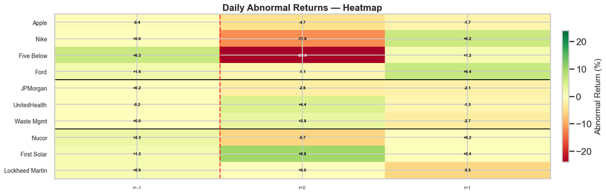

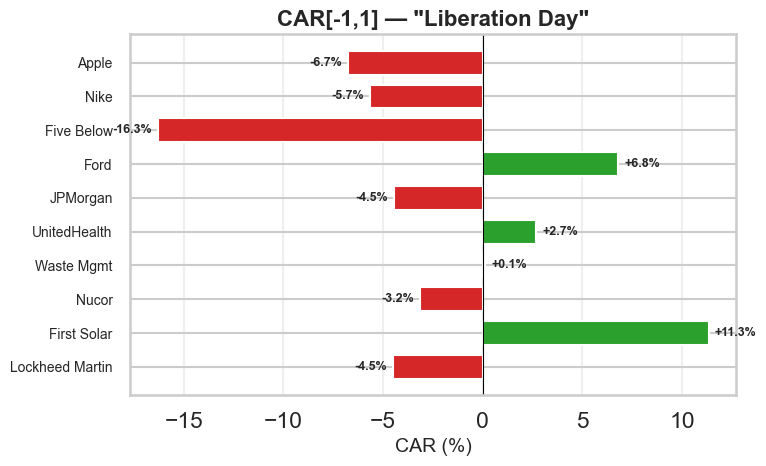

```python
# --- Imports needed for this cell (so it can run independently) ---
import pandas as pd  # pandas is the standard Python library for working with tabular data (DataFrames)
import numpy as np  # NumPy provides fast numerical arrays and math functions
import matplotlib.pyplot as plt  # matplotlib is a plotting library for charts and figures
# =============================================================================
#  CHART B — AR heatmap
# =============================================================================

order = [ric for rics in groups.values() for ric in rics]  # variable assignment: store a value in 'order' so we can reuse it later
ar_matrix = pd.DataFrame(  # variable assignment: store a value in 'ar_matrix' so we can reuse it later
    {NAMES[ric]: evt.set_index("tau")[f"AR_{ric}"] * 100 for ric in order}  # a for-loop repeats a block of code for each element in a sequence
).T

fig2, ax2 = plt.subplots(figsize=(16, 5))
vmax = np.ceil(ar_matrix.abs().max().max())  # variable assignment: store a value in 'vmax' so we can reuse it later
im = ax2.imshow(ar_matrix.values, aspect="auto", cmap="RdYlGn", vmin=-vmax, vmax=vmax)  # variable assignment: store a value in 'im' so we can reuse it later

ax2.set_xticks(range(len(ar_matrix.columns)))
ax2.set_xticklabels([f"τ={int(t)}" for t in ar_matrix.columns], fontsize=8)  # a for-loop repeats a block of code for each element in a sequence
ax2.set_yticks(range(len(ar_matrix.index)))
ax2.set_yticklabels(ar_matrix.index, fontsize=10)

for i in range(ar_matrix.shape[0]):  # for-loop: repeat code for each element in an iterable
    for j in range(ar_matrix.shape[1]):  # for-loop: repeat code for each element in an iterable
        val = ar_matrix.iloc[i, j]  # keyword argument: set the parameter 'val' for the function call
        ax2.text(j, i, f"{val:+.1f}", ha="center", va="center", fontsize=7,
                 color="white" if abs(val) > vmax * 0.6 else "black", fontweight="bold")  # keyword argument: set the parameter 'color' for the function call

ax2.axhline(3.5, color="black", lw=1.5)
ax2.axhline(6.5, color="black", lw=1.5)
ax2.axvline(list(ar_matrix.columns).index(0) - 0.5, color="red", lw=2, ls="--", alpha=.7)
plt.colorbar(im, ax=ax2, shrink=0.8, pad=0.02, label="Abnormal Return (%)")
ax2.set_title('Daily Abnormal Returns — Heatmap', fontweight="bold")
plt.tight_layout()
plt.savefig("event_study_ar_heatmap.png", dpi=200)
plt.show()

# =============================================================================
#  CHART C — CAR bar chart (full window)
# =============================================================================

cars = pd.Series({NAMES[ric]: evt[f"AR_{ric}"].sum() * 100 for ric in order})  # variable assignment: store a value in 'cars' so we can reuse it later

fig3, ax3 = plt.subplots(figsize=(8, 5))
colors = ["#d62728" if v < 0 else "#2ca02c" for v in cars]
bars = ax3.barh(range(len(cars)), cars.values, color=colors, edgecolor="white", height=0.7)  # variable assignment: store a value in 'bars' so we can reuse it later
ax3.set_yticks(range(len(cars)))
ax3.set_yticklabels(cars.index, fontsize=10)
ax3.axvline(0, color="black", lw=.8)
ax3.set_xlabel("CAR (%)")
ax3.set_title(f'CAR[{EVT_START},{EVT_END}] — "Liberation Day"', fontweight="bold")
ax3.grid(axis="x", alpha=.3)
ax3.invert_yaxis()

for i, (v, bar) in enumerate(zip(cars.values, bars)):  # for-loop: repeat code for each element in an iterable
    ax3.text(v + (0.3 if v >= 0 else -0.3), i, f"{v:+.1f}%",  # an if-statement runs code only when a condition is true
             va="center", ha="left" if v >= 0 else "right", fontsize=9, fontweight="bold")  # keyword argument: set the parameter 'va' for the function call

plt.tight_layout()
plt.savefig("event_study_car_bars.png", dpi=200)
plt.show()
```

### 7.4. Market reaction to the Paris Agreement (2015)

**Application.** Now it is your turn to practice. You are to examine the market reaction to the adoption of the Paris Agreement on the stock price of US fossil fuel firms and banks known to finance fossil fuels. See below for the hypothesis, guidance, and a (hidden) possible solution.

**The Paris Agreement was adopted at COP21 on December 12, 2015** in Paris, setting a legally binding international framework to limit global warming. December 12 was a Saturday, so the first full trading day of market reaction is **December 14, 2015 (t = 0)**.

#### Hypothesis

The Paris Agreement signals a credible international commitment to decarbonisation. For firms whose revenues or business model depend on fossil fuels, this introduces new risks: future carbon taxes, stricter emissions regulations, potential stranded assets (reserves that may never be burned), and growing pressure on lenders to restrict fossil fuel financing. We therefore expect **negative abnormal returns** for both groups:

1. **US fossil fuel firms** — the agreement signals higher future carbon costs, potential production restrictions, and the risk that part of their proven reserves become economically unviable (stranded assets).
2. **US banks heavily exposed to fossil fuel financing** — the agreement increases regulatory and reputational pressure on fossil fuel lending, raising the prospect of future restrictions on their loan books and forcing a reassessment of climate-related credit risk.

This hypothesis is supported by **Diaz-Rainey, Gehricke, Roberts & Zhang (2021)** (*International Review of Financial Analysis*, Vol. 76), who find a cumulative average abnormal return (CAAR) of **−8.4%** for US-listed oil and gas firms around the Paris Agreement signing, with the most negative reactions in E&P (−12.2%) and drilling (−10.5%) sub-sectors.

We pick 10 US publicly listed stocks to analyse:

| # | Company | Ticker | RIC | Expected CAR | Group | Rationale |
| --- | --- | --- | --- | --- | --- | --- |
| 1 | ExxonMobil | XOM | `XOM.N` | Negative | Oil Major | Largest US oil major. Significant proved reserves at risk of becoming stranded under future carbon constraints. |
| 2 | Chevron | CVX | `CVX.N` | Negative | Oil Major | Second largest US oil major. High capex in long-cycle fossil fuel projects now exposed to carbon risk. |
| 3 | ConocoPhillips | COP | `COP.N` | Negative | E&P | Pure-play E&P with no downstream buffer. Fully exposed to carbon-driven production constraints. |
| 4 | Devon Energy | DVN | `DVN.N` | Negative | E&P | US shale-focused E&P. Shale economics depend on regulatory permissiveness, now threatened. |
| 5 | Peabody Energy | BTU | `BTU.N` | Negative | Coal | Largest US publicly listed coal producer. Coal is the most carbon-intensive fuel — directly in the crosshairs of the agreement. |
| 6 | JPMorgan Chase | JPM | `JPM.N` | Negative | Bank | World's #1 fossil fuel financier. Paris Agreement increases regulatory and ESG pressure on fossil fuel lending. |
| 7 | Citigroup | C | `C.N` | Negative | Bank | #2 US fossil fuel lender. Same channel as JPM — raised expected cost of fossil fuel credit risk. |
| 8 | Bank of America | BAC | `BAC.N` | Negative | Bank | #3 US fossil fuel lender. International climate commitment raises prospect of future restrictions on loan books. |
| 9 | Wells Fargo | WFC | `WFC.N` | Negative | Bank | Major fossil fuel lender. Growing ESG investor pressure on banks financing high-carbon sectors. |
| 10 | Goldman Sachs | GS | `GS.N` | Negative | Bank | Major fossil fuel arranger and advisor. Climate commitments reduce deal flow and raise reputational costs. |

```python
# --- Imports needed for this cell (so it can run independently) ---
import pandas as pd
import matplotlib.pyplot as plt
import statsmodels.api as sm
from scipy import stats
import refinitiv.data as rd
import os

BASE_FOLDER = os.getcwd()

# ---------- Event definition ----------
# The Paris Agreement was adopted at COP21 on December 12, 2015 (Saturday, markets closed).
# First full trading day of reaction: December 14, 2015 — that is t = 0.
EVENT_DATE = pd.Timestamp("2015-12-14")

# ---------- Windows (in trading days relative to t = 0) ----------
EST_START = -250    # ≈ 1 year of trading days before the event
EST_END   =  -11    # stop 10 days before the event window

EVT_START =   -1    # 1 day before (anticipation / leakage)
EVT_END   =   +3    # 3 days after

# ---------- Securities ----------
STOCK_RICS = [
    "XOM.N", "CVX.N", "COP.N", "DVN.N", "BTU.N",   # fossil fuel firms
    "JPM.N", "C.N",   "BAC.N", "WFC.N", "GS.N",    # banks financing fossil fuels
]
NAMES = {
    "XOM.N": "ExxonMobil",    "CVX.N": "Chevron",
    "COP.N": "ConocoPhillips","DVN.N": "Devon Energy",
    "BTU.N": "Peabody Energy","JPM.N": "JPMorgan",
    "C.N":   "Citigroup",     "BAC.N": "Bank of America",
    "WFC.N": "Wells Fargo",   "GS.N":  "Goldman Sachs",
}

MARKET_RIC = ".SPXTR"
DATA_START  = "2014-06-01"
DATA_END    = "2016-03-31"

print("=" * 70)
print("STEP 1 — Downloading daily price data from Refinitiv")
print("=" * 70)
rd.open_session()

# ── Stocks: daily total returns ────────────────────────────────────
stock_returns = rd.get_data(
    universe=STOCK_RICS,
    fields=["TR.TOTALRETURN", "TR.TOTALRETURN.date"],
    parameters={"SDate": DATA_START, "EDate": DATA_END, "Frq": "D"},
    use_field_names_in_headers=True,
)
print(stock_returns)

# ── Market benchmark: S&P 500 total return ─────────────────────────
market_prices = rd.get_history(
    universe=MARKET_RIC,
    fields=["TRDPRC_1"],
    interval="daily",
    start=DATA_START,
    end=DATA_END,
)
print(market_prices)
rd.close_session()

# ── Clean up ───────────────────────────────────────────────────────
stock_returns["Date"] = pd.to_datetime(stock_returns["TR.TOTALRETURN.DATE"])
stock_returns["ret"]  = pd.to_numeric(stock_returns["TR.TOTALRETURN"], errors="coerce") / 100

stock_ret = (
    stock_returns.pivot_table(index="Date", columns="Instrument", values="ret", aggfunc="mean")
    .sort_index()
    .astype(float)
)

market_prices = market_prices.apply(pd.to_numeric, errors="coerce").dropna()
market_prices.index = pd.to_datetime(market_prices.index)
mkt_ret = (market_prices / market_prices.shift(1) - 1).dropna()
mkt_ret.columns = ["Rm"]
mkt_ret = mkt_ret.astype(float)

returns = stock_ret.join(mkt_ret, how="inner").dropna()
print(f"\nReturn matrix: {returns.shape[0]} days × {returns.shape[1]} cols")
print(returns.head())

returns.to_csv(BASE_FOLDER + "\\returns_paris_agreement_2015.csv")
```

```
======================================================================
STEP 1 — Downloading daily price data from Refinitiv
======================================================================
```

[output not shown]

```
     Instrument  TR.TOTALRETURN TR.TOTALRETURN.DATE
0         XOM.N       -1.100331          2016-03-31
1         XOM.N        -0.01183          2016-03-30
2         XOM.N        0.368084          2016-03-29
3         XOM.N        0.285782          2016-03-28
4         XOM.N        0.274627          2016-03-24
...         ...             ...                 ...
4154       GS.N        2.220445          2014-06-06
4155       GS.N        0.117002          2014-06-05
4156       GS.N        0.364648          2014-06-04
4157       GS.N        1.106043          2014-06-03
4158       GS.N        0.137663          2014-06-02

[4159 rows x 3 columns]
.SPXTR       TRDPRC_1
Date
2014-06-02   3483.136
2014-06-03   3482.002
2014-06-04  3489.2112
2014-06-05  3512.2119
2014-06-06  3528.9785
...               ...
2016-03-24   3827.135
2016-03-28  3829.2568
2016-03-29  3863.8042
2016-03-30  3881.0144
2016-03-31  3873.1118

[462 rows x 1 columns]

Return matrix: 461 days × 10 cols
               BAC.N       C.N     COP.N     CVX.N     DVN.N      GS.N  \
Date
2014-06-03 -0.003277  0.009003  0.004278  0.002782  0.013706  0.011060
2014-06-04  0.000000 -0.006433 -0.000251 -0.001632  0.002276  0.003646
2014-06-05  0.014464  0.015664  0.003133  0.009563 -0.001069  0.001170
2014-06-06  0.010369  0.006169  0.009869  0.005424 -0.001604  0.022204
2014-06-09  0.016036  0.013284  0.000124  0.001449 -0.002946 -0.001143

               JPM.N     WFC.N     XOM.N        Rm
Date
2014-06-03  0.004517  0.000000  0.004503 -0.000326
2014-06-04  0.001439 -0.000979 -0.003486  0.002070
2014-06-05  0.017062  0.011560  0.005098  0.006592
2014-06-06  0.006004  0.006779  0.010443  0.004774
2014-06-09  0.007899  0.010196 -0.000787  0.000988
```

```
Estimation: 240 days  |  Event: 5 days
          Stock     alpha   beta     R2 CAR_pct t_stat  p_value Reaction
     ExxonMobil -0.000405 1.0782 0.5667  +3.75% +1.842   0.0667  NEUTRAL
        Chevron -0.000535 1.2073 0.4688  +2.37% +0.855   0.3935  NEUTRAL
 ConocoPhillips -0.000631 1.2747 0.4008  -2.98% -0.884   0.3774  NEUTRAL
   Devon Energy -0.000819 1.4254 0.3539 -18.08% -4.347   0.0000 NEGATIVE
       JPMorgan  0.000335 1.1938 0.7056  +1.45% +0.869   0.3859  NEUTRAL
      Citigroup -0.000185 1.2628 0.6452  +1.11% +0.547   0.5852  NEUTRAL
Bank of America -0.000089 1.2110 0.5447  +1.28% +0.534   0.5940  NEUTRAL
    Wells Fargo -0.000007 1.0854 0.7214  +2.59% +1.780   0.0764  NEUTRAL
  Goldman Sachs -0.000146 1.1524 0.6854  +0.96% +0.570   0.5690  NEUTRAL

Window: CAR[-1,3] | α = 5%
```

[figure not shown]

```python
# --- Imports needed for this cell (so it can run independently) ---
import pandas as pd
import numpy as np
import matplotlib.pyplot as plt
import statsmodels.api as sm
from scipy import stats

# ── Event time index ──────────────────────────────────────────────
dates  = returns.index.sort_values()
t0_idx = dates.searchsorted(EVENT_DATE)
returns["tau"] = range(-t0_idx, len(dates) - t0_idx)

est = returns[returns["tau"].between(EST_START, EST_END)]
evt = returns[returns["tau"].between(EVT_START, EVT_END)].copy()

print(f"Estimation: {len(est)} days  |  Event: {len(evt)} days")

# ── Market model OLS + CAR ────────────────────────────────────────
results   = []
ar_matrix = {}

STOCK_RICS = [r for r in STOCK_RICS if r in returns.columns and returns[r].dropna().shape[0] > EST_END - EST_START]

for ric in STOCK_RICS:
    X_est = sm.add_constant(est["Rm"])
    y_est = est[ric]
    model = sm.OLS(y_est, X_est).fit()
    alpha, beta = model.params["const"], model.params["Rm"]
    r2 = model.rsquared

    ar = evt[ric] - (alpha + beta * evt["Rm"])
    ar_matrix[NAMES[ric]] = ar.values
    car = ar.sum()

    ar_est = y_est - (alpha + beta * est["Rm"])
    se_car = ar_est.std() * np.sqrt(len(evt))
    t_stat = car / se_car
    p_val  = 2 * stats.t.sf(abs(t_stat), df=len(est) - 2)
    reaction = "POSITIVE" if car > 0 and p_val < 0.05 else (
               "NEGATIVE" if car < 0 and p_val < 0.05 else "NEUTRAL")

    results.append(dict(
        Stock=NAMES[ric], alpha=round(alpha, 6), beta=round(beta, 4),
        R2=round(r2, 4), CAR_pct=f"{car*100:+.2f}%",
        t_stat=f"{t_stat:+.3f}", p_value=round(p_val, 4), Reaction=reaction
    ))

res_df = pd.DataFrame(results)
print(res_df.to_string(index=False))
print(f"\nWindow: CAR[{EVT_START},{EVT_END}] | α = 5%")

# ── Plots ─────────────────────────────────────────────────────────
fig, (ax1, ax2, ax3) = plt.subplots(1, 3, figsize=(16, 5))

ar_df  = pd.DataFrame(ar_matrix, index=range(EVT_START, EVT_END + 1))
cum_ar = ar_df.cumsum()
for col in cum_ar.columns:
    ax1.plot(cum_ar.index, cum_ar[col] * 100, marker="o", label=col)
ax1.axhline(0, color="black", linewidth=0.8, linestyle="--")
ax1.axvline(0, color="red",   linewidth=0.8, linestyle="--", label="Event (t=0)")
ax1.set_title("Cumulative Abnormal Returns\nParis Agreement Adoption (2015)", fontweight="bold")
ax1.set_xlabel("Trading days relative to event")
ax1.set_ylabel("CAR (%)")
ax1.legend(fontsize=6, ncol=2)

cars   = [float(r["CAR_pct"].replace("%","")) for r in results]
names  = [r["Stock"] for r in results]
colors = ["green" if c > 0 else "red" for c in cars]
ax2.barh(names, cars, color=colors)
ax2.axvline(0, color="black", linewidth=0.8)
ax2.set_title(f'CAR[{EVT_START},{EVT_END}] — Paris Agreement (2015)', fontweight="bold")
ax2.set_xlabel("CAR (%)")

groups = ["Fossil fuel"] * 5 + ["Bank"] * 5
gcols  = ["saddlebrown" if g == "Fossil fuel" else "steelblue" for g in groups]
ax3.barh(names, cars, color=gcols)
ax3.axvline(0, color="black", linewidth=0.8)
ax3.set_title("CAR by group\n(brown = FF firm, blue = bank)", fontweight="bold")
ax3.set_xlabel("CAR (%)")

plt.tight_layout()
plt.show()
```

#### Interpreting the results in light of the literature

Our results over the CAR[−1, +3] window are largely **neutral**, with one striking exception: **Devon Energy shows a large and highly significant negative CAR of −18.08%** (t = −4.35, p < 0.001). All other firms — both fossil fuel majors and banks — display small, statistically insignificant abnormal returns. This pattern is informative and consistent with the academic literature on climate policy risk.

**Why mostly neutral reactions for large diversified firms?** **Bolton & Kacperczyk (2021)** — *"Do Investors Care about Carbon Risk?"*, Journal of Financial Economics, Vol. 142, pp. 517–549 — show that investors do price carbon transition risk, but the mechanism operates primarily through **risk premia in expected returns** rather than through immediate price drops at policy announcements. High-emission firms already embed a carbon risk premium in their expected returns; when a climate agreement is announced, markets update this premium gradually rather than producing a sharp one-time price adjustment. Additionally, the COP21 negotiations were highly publicised and ran for years: most of the informational content of the Paris Agreement had been anticipated and progressively priced in well before December 12, 2015, leaving little residual surprise for short-window event studies to capture.

**Why is Devon Energy the exception?** Devon Energy is a pure-play US shale E&P company with no downstream activities and no international diversification — the most exposed firm in our sample to US domestic regulatory risk. **Bolton & Kacperczyk (2023)** — *"Global Pricing of Carbon-Transition Risk"*, Journal of Finance, Vol. 78, pp. 3677–3754 — document that carbon transition risk is most severe for firms in sectors with the highest direct emission intensity and the least ability to pass carbon costs through their value chain. A US-only shale E&P firm fits this profile exactly: it cannot diversify geographically, has no refining or retail margin buffer, and its entire asset base consists of fossil fuel reserves that are directly threatened by decarbonisation commitments. Large integrated majors (ExxonMobil, Chevron) escaped significant market reaction precisely because their diversified business models offered natural hedges against any single regulatory shock.

**Why are the banks positive (though insignificant)?** The small positive CARs for JPMorgan, Citigroup, Bank of America, Wells Fargo, and Goldman Sachs are not statistically significant, but their direction is consistent with the finding by **Alessi, Battiston & Kvedaras (2024)** — *"Over with carbon? Investors' reaction to the Paris Agreement and the US withdrawal"*, Journal of Financial Stability, Vol. 71 — that regulated financial institutions reduced exposure to high-carbon equities after Paris, while simultaneously positioning themselves for **green finance growth** (green bonds, sustainability-linked loans, transition financing). The offsetting effects of these two forces produced near-zero net abnormal returns around the announcement date. **Ramelli, Wagner, Zeckhauser & Ziegler (2021)** — *"Investor Rewards to Climate Responsibility"*, Review of Corporate Finance Studies, Vol. 10, pp. 748–787 — further show that long-horizon investors systematically favoured climate-responsible firms around major climate policy events: banks with stronger ESG commitments may actually have benefitted marginally, consistent with the slightly positive point estimates we observe.

**Key takeaways from this event study:**

1. **Carbon risk is priced gradually, not in one jump:** The literature (Bolton & Kacperczyk 2021, 2023) shows that climate risk embeds itself in expected returns over time, not in sharp announcement-day drops. Widely anticipated agreements like Paris produce muted short-window reactions.
2. **Business model specificity drives abnormal returns:** Devon Energy's −18% CAR versus near-zero reactions for ExxonMobil and Chevron illustrates that sector membership alone is not enough — what matters is the firm's **specific exposure profile**: pure-play, US-only, no downstream operations = maximum sensitivity to climate regulation.
3. **Banks face offsetting forces:** Green finance opportunities and fossil fuel lending risk roughly cancel out at the announcement date, producing insignificant but slightly positive reactions — consistent with Alessi et al. (2024) and Ramelli et al. (2021).

## 8. Portfolio Analysis

### 8.1. What is a portfolio?

A **portfolio** is a collection of assets (stocks) held together. Instead of concentrating all your wealth in one stock, you spread it across many. This diversification reduces risk because individual stocks do not all move in the same direction at the same time.

**Value-weighted portfolio:** Each stock's weight in the portfolio equals its market capitalisation divided by the total market cap of all stocks. This is exactly how the S&P 500 index itself is constructed — larger companies receive more weight.

Key performance metrics:

| Metric | Formula | Interpretation |
| --- | --- | --- |
| Mean return | $\bar{r}$ | Average monthly or annual return |
| Volatility ($\sigma$) | Standard deviation of returns | Total risk (both up and down swings) |
| Sharpe ratio | $(\bar{r} - r_f) / \sigma$ | Return per unit of total risk ($r_f$ = risk-free rate) |
| Sortino ratio | $(\bar{r} - r_f) / \sigma_{\text{down}}$ | Return per unit of downside risk only |

The Sortino ratio is often preferred because it penalises only bad volatility (losses), not good volatility (gains).

### 8.2. Building an S&P 500 value-weighted portfolio

The cell below downloads market capitalisation and company names for all S&P 500 constituents, computes value-weighted portfolio weights, and displays the top 30 holdings.

```python
# --- Imports needed for this cell (so it can run independently) ---
import pandas as pd  # pandas is the standard Python library for working with tabular data (DataFrames)
import refinitiv.data as rd  # Refinitiv/LSEG Data Library (requires credentials)

# Open session
rd.open_session()  # rd.open_session() starts an authenticated connection to Refinitiv/LSEG (needed before queries)

# Get constituents sp
rics_sp500=pd.read_csv("sp500_constituents.csv")  # variable assignment: store a value in 'rics_sp500' so we can reuse it later
rics_sp500 = rics_sp500["RIC"].astype(str).tolist()  # variable assignment: store a value in 'rics_sp500' so we can reuse it later
print(f"Fetching market cap for {len(rics_sp500)} S&P 500 constituents…")  # print() outputs text/values to the screen (useful for checking results)

# Collect market cap and name
mcap_panel = rd.get_data(  # variable assignment: store a value in 'mcap_panel' so we can reuse it later
    universe=rics_sp500,  # keyword argument: set the parameter 'universe' for the function call
    fields=["TR.CompanyMarketCap", "TR.CompanyName"],  # keyword argument: set the parameter 'fields' for the function call
    use_field_names_in_headers=True,  # keyword argument: set the parameter 'use_field_names_in_headers' for the function call
)

#close session
rd.close_session()

# Rename and clean variables
df = ( mcap_panel .rename(columns={"TR.COMPANYMARKETCAP": "market_cap",  # variable assignment: store a value in 'df' so we can reuse it later
                     "TR.COMPANYNAME": "Company"}))

# drop if market cap = 0
df = df.loc[df["market_cap"] > 0].copy()  # variable assignment: store a value in 'df' so we can reuse it later

# Compute value-weighted portfolio weights
total_mcap   = df["market_cap"].sum()  # variable assignment: store a value in 'total_mcap' so we can reuse it later
df["weight"] = df["market_cap"] / total_mcap

# Top 30 holdings.
top30 = df.sort_values("weight", ascending=False).head(30).copy()  # variable assignment: store a value in 'top30' so we can reuse it later
top30["weight_pct"] = 100 * top30["weight"]

print("Top 30 stocks in the S&P 500 value-weighted portfolio:\n")  # print() outputs text/values to the screen (useful for checking results)
print(  # print() outputs text/values to the screen (useful for checking results)
    top30[["Company", "weight_pct"]]
    .rename(columns={"weight_pct": "Weight (%)"})
    .to_string(index=False, formatters={"Weight (%)": lambda x: f"{x:5.2f}"})
)
print(f"\nCumulative weight of top 30: {top30['weight'].sum():.2%}")  # print() outputs text/values to the screen (useful for checking results)
```

```
Fetching market cap for 503 S&P 500 constituents…
```

```
c:\Users\alexa\anaconda3\envs\course_research_methods\Lib\site-packages\refinitiv\data\_access_layer\get_data_func.py:57:FutureWarning: Parameter 'use_field_names_in_headers' is deprecated and will be removed in future library version v2.0.
c:\Users\alexa\anaconda3\envs\course_research_methods\Lib\site-packages\refinitiv\data\content\fundamental_and_reference\_definition.py:147:FutureWarning: Parameter 'use_field_names_in_headers' is deprecated and will be removed in future library version v2.0.
```

```
Top 30 stocks in the S&P 500 value-weighted portfolio:

                  Company Weight (%)
              NVIDIA Corp   6.488097
                Apple Inc   5.852871
             Alphabet Inc   5.680195
             Alphabet Inc   5.680195
           Microsoft Corp   4.394508
           Amazon.com Inc   3.396957
       Meta Platforms Inc   2.470653
             Broadcom Inc   2.282999
                Tesla Inc   2.275943
   Berkshire Hathaway Inc   1.641154
              Walmart Inc   1.536666
         Eli Lilly and Co   1.495408
      JPMorgan Chase & Co   1.220431
         Exxon Mobil Corp   0.957504
                 Visa Inc   0.919468
        Johnson & Johnson   0.902142
    Micron Technology Inc   0.699372
           Mastercard Inc   0.695044
    Costco Wholesale Corp   0.676064
              Oracle Corp   0.629494
               AbbVie Inc   0.618349
              Netflix Inc   0.612297
      Procter & Gamble Co   0.585524
           Home Depot Inc   0.571115
             Chevron Corp   0.561542
      General Electric Co   0.540912
     Bank of America Corp   0.538873
             Coca-Cola Co   0.528555
          Caterpillar Inc   0.520814
Palantir Technologies Inc   0.494213

Cumulative weight of top 30: 55.47%
```

```
c:\Users\alexa\anaconda3\envs\course_research_methods\Lib\site-packages\pandas\core\dtypes\cast.py:1060:RuntimeWarning: invalid value encountered in cast
c:\Users\alexa\anaconda3\envs\course_research_methods\Lib\site-packages\pandas\core\dtypes\cast.py:1084:RuntimeWarning: invalid value encountered in cast
```

The cell below visualises the portfolio with a horizontal bar chart (top 20) and a pie chart (top 10 + "Other").

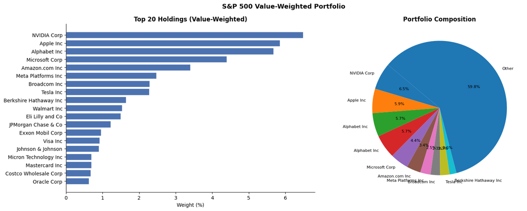

```python
# --- Imports needed for this cell (so it can run independently) ---
import pandas as pd  # pandas is the standard Python library for working with tabular data (DataFrames)
import matplotlib.pyplot as plt  # matplotlib is a plotting library for charts and figures


fig, axes = plt.subplots(1, 2, figsize=(16, 6))

# ── Bar chart: top 20 ────────────────────────────────────────────────────────
top20 = df.sort_values("weight", ascending=False).head(20).copy()  # variable assignment: store a value in 'top20' so we can reuse it later
top20["weight_pct"] = top20["weight"] * 100

axes[0].barh(top20["Company"].iloc[::-1], top20["weight_pct"].iloc[::-1],
             color="#4C72B0", edgecolor="white")
axes[0].set_xlabel("Weight (%)")
axes[0].set_title("Top 20 Holdings (Value-Weighted)", fontweight="bold")
axes[0].spines[["top", "right"]].set_visible(False)

# ── Pie chart: top 10 + rest ─────────────────────────────────────────────────
top10     = df.sort_values("weight", ascending=False).head(10).copy()  # variable assignment: store a value in 'top10' so we can reuse it later
top10_pct = top10.set_index("Company")["weight"] * 100  # variable assignment: store a value in 'top10_pct' so we can reuse it later
rest      = pd.Series({"Other": (df["weight"].sum() - top10["weight"].sum()) * 100})  # variable assignment: store a value in 'rest' so we can reuse it later
pie_data  = pd.concat([top10_pct, rest])  # variable assignment: store a value in 'pie_data' so we can reuse it later

axes[1].pie(pie_data.values, labels=pie_data.index, autopct="%1.1f%%",
            startangle=140, textprops={"fontsize": 8})  # keyword argument: set the parameter 'startangle' for the function call
axes[1].set_title("Portfolio Composition", fontweight="bold")

plt.suptitle("S&P 500 Value-Weighted Portfolio", fontsize=13, fontweight="bold")
plt.tight_layout()
plt.show()
```

### 8.3. Portfolio performance — monthly returns, Sharpe and Sortino ratios

With the value weights from 8.2 in hand, we now compute the **time-series of monthly portfolio returns** and summarise its risk-adjusted performance over a 10-year window (2015–2024).

**Step 1 — Portfolio return.** Each month's portfolio return is the weighted average of the individual stock returns:

$$r_{p,t} = \sum_i w_i \cdot r_{i,t}$$

where $w_i$ is stock $i$'s value weight (market cap share) and $r_{i,t}$ its total return in month $t$. We use **fixed weights** from 8.2 — a simplification, since a true value-weighted index rebalances every month as market caps change.

**Step 2 — Performance metrics.** We compute four summary statistics:

| Metric | Formula | Note |
| --- | --- | --- |
| Annualised return | $(1 + \bar{r}_m)^{12} - 1$ | Compounded monthly mean |
| Annualised volatility | $\sigma_m \times \sqrt{12}$ | Total risk |
| Sharpe ratio | $\dfrac{\bar{r}_m - r_f}{\sigma_m} \times \sqrt{12}$ | Return per unit of total risk |
| Sortino ratio | $\dfrac{\bar{r}_m - r_f}{\sigma_\text{down}} \times \sqrt{12}$ | Return per unit of **downside** risk only |

We set $r_f = 0$ for simplicity. The Sortino ratio uses only months where the portfolio return was negative to compute $\sigma_\text{down}$ — it does not penalise upside volatility.

```python
# --- Imports needed for this cell (so it can run independently) ---
import pandas as pd
import numpy as np
import matplotlib.pyplot as plt
import refinitiv.data as rd
import os

BASE_FOLDER = os.getcwd()

# ── 1. Reload portfolio weights from 8.2 ─────────────────────────
# We need: Instrument (RIC) → weight. These were computed in 8.2 as 'df'.
# If 8.2 has already run in this session, 'df' is available.
# If not, reload constituents + market cap and recompute.
try:
    weights_series = df.set_index("Instrument")["weight"]
    print(f"Loaded {len(weights_series)} weights from session (8.2 already run).")
except NameError:
    sp500_constituents = pd.read_csv(BASE_FOLDER + "\\sp500_constituents_trbc.csv")
    rics_sp500 = sp500_constituents["TR.RIC"].astype(str).tolist()
    rd.open_session()
    mcap_panel = rd.get_data(
        universe=rics_sp500,
        fields=["TR.CompanyMarketCap"],
        use_field_names_in_headers=True,
    )
    rd.close_session()
    df_tmp = mcap_panel.rename(columns={"TR.COMPANYMARKETCAP": "market_cap"})
    df_tmp = df_tmp.loc[df_tmp["market_cap"] > 0].copy()
    df_tmp["weight"] = df_tmp["market_cap"] / df_tmp["market_cap"].sum()
    weights_series = df_tmp.set_index("Instrument")["weight"]
    print(f"Recomputed {len(weights_series)} weights.")

# ── 2. Download monthly total returns (2015-2024) ─────────────────
DATA_START = "2015-01-01"
DATA_END   = "2024-12-31"

print("Downloading monthly returns — this may take a minute…")
rd.open_session()
ret_raw = rd.get_data(
    universe=weights_series.index.tolist(),
    fields=["TR.TOTALRETURN", "TR.TOTALRETURN.date"],
    parameters={"SDate": DATA_START, "EDate": DATA_END, "Frq": "M"},
    use_field_names_in_headers=True,
)
rd.close_session()

# ── 3. Clean and pivot ────────────────────────────────────────────
ret_raw["Date"] = pd.to_datetime(ret_raw["TR.TOTALRETURN.DATE"])
ret_raw["ret"]  = pd.to_numeric(ret_raw["TR.TOTALRETURN"], errors="coerce") / 100

ret_wide = (
    ret_raw.drop_duplicates(subset=["Date", "Instrument"])
    .pivot(index="Date", columns="Instrument", values="ret")
    .sort_index()
    .astype(float)
)

print(f"Return matrix: {ret_wide.shape[0]} months x {ret_wide.shape[1]} stocks")
print(ret_wide.head())

# Save
ret_wide.to_csv(BASE_FOLDER + "\\sp500_monthly_returns_2015_2024.csv")
print("Saved: sp500_monthly_returns_2015_2024.csv")
```

```
Loaded 503 weights from session (8.2 already run).
Downloading monthly returns — this may take a minute…
```

```
c:\Users\alexa\anaconda3\envs\course_research_methods\Lib\site-packages\refinitiv\data\_access_layer\get_data_func.py:57:FutureWarning: Parameter 'use_field_names_in_headers' is deprecated and will be removed in future library version v2.0.
c:\Users\alexa\anaconda3\envs\course_research_methods\Lib\site-packages\refinitiv\data\content\fundamental_and_reference\_definition.py:147:FutureWarning: Parameter 'use_field_names_in_headers' is deprecated and will be removed in future library version v2.0.
```

```
Return matrix: 121 months x 503 stocks
Instrument       A.N   AAPL.OQ    ABBV.N  ABNB.OQ     ABT.N   ACGL.OQ  \
Date
2015-01-30 -0.075156  0.061424 -0.070652      NaN -0.000426 -0.019120
2015-02-27  0.117554  0.100746  0.002486      NaN  0.058311  0.020528
2015-03-31 -0.013242 -0.031372 -0.032397      NaN -0.021955  0.041244
2015-04-30 -0.004332  0.005786  0.113748      NaN  0.007111 -0.014935
2015-05-29 -0.004351  0.045312  0.029848      NaN  0.046963  0.052900

Instrument     ACN.N   ADBE.OQ    ADI.OQ     ADM.N  ...      WY.N   WYNN.OQ  \
Date                                                ...
2015-01-30 -0.059120 -0.035351 -0.061509 -0.103269  ... -0.001115 -0.005445
2015-02-27  0.071403  0.127905  0.131119  0.032867  ... -0.012513 -0.027284
2015-03-31  0.040653 -0.065234  0.076187 -0.010025  ... -0.055825 -0.116632
2015-04-30 -0.000496  0.028672 -0.018413  0.031224  ... -0.049472 -0.117652
2015-05-29  0.036589  0.039837  0.105402  0.086984  ...  0.033323 -0.089477

Instrument    XEL.OQ     XOM.N     XYL.N  XYZ.N     YUM.N     ZBH.N   ZBRA.OQ  \
Date
2015-01-30  0.044822 -0.054408 -0.104282    NaN -0.002199 -0.011638  0.078155
2015-02-27 -0.059952  0.020449  0.051009    NaN  0.122164  0.073952  0.090942
2015-03-31 -0.003964 -0.039982 -0.019048    NaN -0.029466 -0.022031 -0.003679
2015-04-30 -0.025855  0.027882  0.057110    NaN  0.097689 -0.065351  0.015047
2015-05-29  0.004129 -0.016634 -0.008328    NaN  0.048278  0.040736  0.190704

Instrument     ZTS.N
Date
2015-01-30 -0.005080
2015-02-27  0.078633
2015-03-31  0.004339
2015-04-30 -0.038679
2015-05-29  0.120441

[5 rows x 503 columns]
Saved: sp500_monthly_returns_2015_2024.csv
```

```
==================================================
S&P 500 Value-Weighted Portfolio — Performance
==================================================
Period                 : 2015-01 → 2024-12
Number of months       : 120
Mean monthly return    : +1.977%
Annualised return      : +26.49%
Annualised volatility  : 17.06%
Sharpe ratio           : 1.391  (Assuming Rf = 0)
Sortino ratio          : 2.076  (Assuming Rf = 0)
```

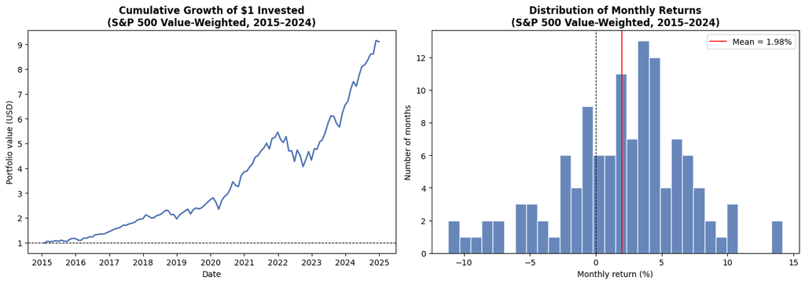

```python
# --- Imports needed for this cell (so it can run independently) ---
import pandas as pd
import numpy as np
import matplotlib.pyplot as plt
import os

BASE_FOLDER = os.getcwd()

# ── 1. Align weights with return columns ──────────────────────────
# Reindex weights to the stocks for which we have returns;
# fill missing with 0 and renormalise so weights still sum to 1.
w = weights_series.reindex(ret_wide.columns).fillna(0)
w = w / w.sum()

# ── 2. Value-weighted portfolio monthly return ────────────────────
# r_p,t = sum_i( w_i * r_i,t )
# Stocks with missing return in month t contribute 0 (as if held at zero weight).
port_ret = ret_wide.fillna(0).dot(w)
port_ret.name = "S&P 500 VW Portfolio"
port_ret = port_ret[port_ret.index.notna()]  # drop any rows with NaT dates

# ── 3. Performance metrics ────────────────────────────────────────
MONTHS_PER_YEAR = 12
RF_MONTHLY      = 0.0  # risk-free rate set to 0 for simplicity

mean_m   = port_ret.mean()
std_m    = port_ret.std()
mean_ann = (1 + mean_m) ** MONTHS_PER_YEAR - 1  # compounded annualised return
std_ann  = std_m * np.sqrt(MONTHS_PER_YEAR)     # annualised volatility

excess_ret   = port_ret - RF_MONTHLY
sharpe       = excess_ret.mean() / excess_ret.std() * np.sqrt(MONTHS_PER_YEAR)

downside_ret = port_ret[port_ret < RF_MONTHLY]
sortino      = (mean_m - RF_MONTHLY) / downside_ret.std() * np.sqrt(MONTHS_PER_YEAR)

print("=" * 50)
print("S&P 500 Value-Weighted Portfolio — Performance")
print("=" * 50)
print(f"Period                 : {port_ret.index[0].strftime('%Y-%m')} → {port_ret.index[-1].strftime('%Y-%m')}")
print(f"Number of months       : {len(port_ret)}")
print(f"Mean monthly return    : {mean_m*100:+.3f}%")
print(f"Annualised return      : {mean_ann*100:+.2f}%")
print(f"Annualised volatility  : {std_ann*100:.2f}%")
print(f"Sharpe ratio           : {sharpe:.3f}  (Assuming Rf = 0)")
print(f"Sortino ratio          : {sortino:.3f}  (Assuming Rf = 0)")

# ── 4. Plot ───────────────────────────────────────────────────────
cumret = (1 + port_ret).cumprod()

fig, (ax1, ax2) = plt.subplots(1, 2, figsize=(14, 5))

# Panel 1 — cumulative growth of $1
ax1.plot(cumret.index, cumret.values, color="#4C72B0", linewidth=1.8)
ax1.axhline(1, color="black", linewidth=0.8, linestyle="--")
ax1.set_title("Cumulative Growth of \$1 Invested\n(S&P 500 Value-Weighted, 2015\u20132024)", fontweight="bold")
ax1.set_xlabel("Date")
ax1.set_ylabel("Portfolio value (USD)")

# Panel 2 — monthly return distribution
ax2.hist(port_ret * 100, bins=30, color="#4C72B0", edgecolor="white", alpha=0.85)
ax2.axvline(0, color="black", linewidth=0.8, linestyle="--")
ax2.axvline(mean_m * 100, color="red", linewidth=1.2, linestyle="-", label=f"Mean = {mean_m*100:.2f}%")
ax2.set_title("Distribution of Monthly Returns\n(S&P 500 Value-Weighted, 2015–2024)", fontweight="bold")
ax2.set_xlabel("Monthly return (%)")
ax2.set_ylabel("Number of months")
ax2.legend()

plt.tight_layout()
plt.show()
```